# Topic 2: Predicting the number of Twitter followers

ACCT653 Forecasting and Forensic Analytics

Instructor’s name: Wang Jiwei

Authors

CHERN Cheng (01354502)

SUN Yifan (01461236)

TEAN Wan Ching (01462626)

YUE Zixuan (01475299)

ZHANG Erhe (01475073)

Published

March 17, 2024

Abstract

Predicting the number of social media followers for US corporations

## 1. Introduction

(This file requires around 10 minutes to run through.) Social media prediction (SMP) encompasses a paramount framework when conducting the prediction process, including considerations such as the source of data, algorithm used and evaluation of prediction. This topic has emerged as a powerful tool, attracting the attention of researchers and practitioners alike. Among the abundant studies, multiple predictors and features have been utilized to improve prediction. However, most studies still focus on the social behaviours and activities on social media itself. Based on this, we aim to broaden the possibilities by embedding more potential predictors to enhance results as well as better understand the function of machine learning tools.

During this project, using R programming as our coding language, we analyze and attempt to predict the daily number of twitter followers for US-listed firms during 2017. We first briefly review the literature, followed by an overview of our data sources in the data preparation section, then the explanatory description of data, sample and variables descriptive statistics. After that, we run several types of models and machine learning algorithms and evaluate the prediction results. Finally, we summarize the performance of all our models and share the key take aways from this project.

## 2. Literature Review

The exposure of social media account has been a subject of extensive inquiry, with operating multiple and advanced social platforms becoming the mainstream of advertising and marketing. While substantial evidence exists trying to unfold the key factors behind the influence of the social media accounts, empirical results vary and do not come to the consensus about how to better predict and utilize the influence, among which number of followers is one of the main indicators. To elucidate the achievements of previous research and the contribution of this report, we review primarily two strands of literature closely aligned with our study. The first strand of studies is focused on how financial information or statistics can be related to the popularity of twitter or influence of their social media accounts. While most studies have shed some light on how the sentiment of tweets or post contents can affect the financial and stock market, literature studying the effect of financial information on the popularity of social media accounts remain inadequate. Sayed (n.d.) utilizes accounting ratios to analyze the twitter sentiment and volume. The results shows that certain accounting ratios are not associated with the formation of twitter users, however, they do have positive impact on the twitter volume. Intuitively, twitter volume could have a strong effect on the number of twitter followers. This study provides evidence supporting our choice of financial indicators as features in our prediction model, especially considering corporation accounts as predicting object.

Naturally, number of followers and the popularity of social media accounts could be directly influenced by the content of posts, the style of the account and some exogenous event, which could bring more visibility of certain accounts. Therefore, we mainly refer to studies in this area when selecting our non-financial features. Hutto et al. (2013) finds that variables for message content, social behaviour, and network structure should be equally considered when predicting followers. Similarly, the popularity on twitter can be mainly driven by tweets, profile page.(Mueller & Stumme, 2017) Considering their variables selection and data availability, we create profile related variables to show the characteristics of corporation account features. Besides, Tsileponis et al. (2020) examine the influence of voluntary corporate press releases on financial media coverage, which gives us insight into the function of corporations’ announcements. Therefore, we also consider announcements as important predictors in our models.

In summary, predicting social media followers is a multifaceted topic that has drawn great attention in the academic field. While various studies have contributed valuable insights, the field remains dynamic and is worthy of further exploration, especially considering the function of financial indicators has not been sufficiently discussed. This report contributes to the studies of this field and aims to enhance the understanding of the interplay between corporation’s economic activities, social behaviours and social media popularity.

## 3. Data Extraction and Data Cleaning

### 3.1 : Data used

These are the dataset used in our group project:

1. Followers_train.csv

   - the training dataset provided on Kaggle (https://www.kaggle.com/competitions/followers/data)
2. Followers_test.csv

   - the test dataset provided on Kaggle (https://www.kaggle.com/competitions/followers/data)
3. Followers_sampleSubmission.csv

   - a sample submission file in the correct format on Kaggle (https://www.kaggle.com/competitions/followers/data)
4. profile_info.csv

   From S&P Global Market Intelligence > S&P Compustat Global
6. key_developments.csv

   From S&P Capital IQ > Companies > Key Developments
7. Financials.csv

   From Compustat - Capital IQ > North America > Fundamentals Quarterly
8. Financial Ratios.csv

   From Compustat - Capital IQ > North America > Financial Ratios Suite by WRDS

### 3.2 : Packages used

```r
library(readr)
library(R.utils)
library(readxl)
pacman::p_load(rvest)
pacman::p_load(tidyverse)
pacman::p_load(ggplot2)
pacman::p_load(randomForest)
pacman::p_load(glmnet)
pacman::p_load(coefplot)
pacman::p_load(xgboost)
pacman::p_load(ParBayesianOptimization)
pacman::p_load(SmartEDA)
pacman::p_load(quanteda.textstats)
```

### 3.3 : Scrape Twitter profile data

Section 3.3 aims to scrape the profile information of companies’ twitter accounts using RSelenium. The Selenium packages requires specific configuration (kindly refer to this: https://www.youtube.com/watch?v=GnpJujF9dBw) in order for the codes to run. This process takes a long time with some manual work needed. Hence, we recommend to skip these parts and use the scraped `profile_info.csv` (in Section 3.7) directly. You may proceed straight to Section 3.4 onwards to continue with processing and data cleaning codes.

Due to the issue of mismatch and presence of advertisements on twitter, we cannot locate a company’s twitter account simply by searching their company name. In this case, we will need to search and match the unique Twitter account name of each company, stored in `company information.xlsx` and resume scraping with the matched Twitter account names.

```r
# remove all the variables
rm(list=ls())

# load the required packages
library(RSelenium)
library(wdman)
library(netstat)


my_user <- "89423301"
my_pass <- "y150500z113104X!"

# open remote driver with firefox
remote_driver <- rsDriver(browser = "firefox",
                          chromever = NULL,
                          verbose = F,
                          port = free_port())


remDr <- remote_driver$client
remDr$open()
remDr$navigate("https://twitter.com/i/flow/login")

# enter user_id
webElement <- remDr$findElement(using = "xpath", value = "//input[@type = 'text']")
webElement$sendKeysToElement(list(my_user))
webElement$sendKeysToElement(list(key = "enter"))
Sys.sleep(3)

# enter password
webElement <- remDr$findElement(using = "xpath", value = "//input[@type = 'password']")
webElement$sendKeysToElement(list(my_pass))
webElement$sendKeysToElement(list(key = "enter"))

# explanation of matching the company with username --------------------------------------------------
### we try to automate the process of matching company name with its username using selenium.
### however, searching the company name can be matched to multiple accounts or zero accounts
### which also requires our manual judgement
### So we manully search and match the company name and the username of their account and store in company information
# collect the profile information ------------------------------------------------
accounts <- read_excel("company information.xlsx")
accounts <- accounts %>% select(conm, username)
accounts <- filter(accounts, !is.na(username))
accounts$username <- substring(accounts$username, 2)

com_info <- data.frame(matrix(vector(),0,7,
                              dimnames = list(c(),
                                              c("profile_name",
                                                "profile_bio",
                                                "profile_category",
                                                "profile_website",
                                                "profile_joining_date",
                                                "profile_following",
                                                "profile_followers"))),
                       stringsAsFactors=F)

# for each account scrape the basic information
for (j in 84:nrow(accounts)){

  search_item = accounts$username[j]

  search_box = remDr$findElement(using = "xpath", value = "//input[@data-testid='SearchBox_Search_Input']")
  search_box$sendKeysToElement(list(search_item))
  search_box$sendKeysToElement(list(key = "enter"))
  Sys.sleep(5)

  # turn to the people page
  remDr$findElement(using = "link text", value = "People")$clickElement()
  Sys.sleep(5)

  # click the account
  # now all click the first account by default
  remDr$findElement(using = "xpath", value = paste0("//a[@href='/", search_item, "']"))$clickElement()

  # scrape the account information
  l = list()
  o = {}

  resp <- remDr$getPageSource()
  html_info <- read_html(resp[[1]])

  # profile name
  tryCatch({
    profile_name <- html_info %>% html_node(".r-1vr29t4") %>% html_text()
    o[["profile_name"]] <- profile_name
  }, error = function(e) {
    o[["profile_name"]] <- NA
  })


  # profile bio
  tryCatch({
    profile_bio <- html_info %>% html_node("[data-testid='UserDescription']") %>% html_text()
    o[["profile_bio"]] <- profile_bio
  }, error = function(e) {
    o[["profile_bio"]] <- NA
  })

  # information under the profile header
  profile_header <- html_info %>% html_node("[data-testid='UserProfileHeader_Items']")

  # profile category
  tryCatch({
    profile_category <- profile_header %>% html_node("[data-testid='UserProfessionalCategory']") %>% html_text()
    o[["profile_category"]] <- profile_category
  }, error = function(e) {
    o[["profile_category"]] <- NA
  })

  # website
  tryCatch({
    profile_website <- profile_header %>% html_node("a") %>% html_attr("href")
    o[["profile_website"]] <- profile_website
  }, error = function(e) {
    o[["profile_website"]] <- NA
  })

  # join_date
  tryCatch({
    profile_joining_date <- profile_header %>% html_node("span[data-testid='UserJoinDate']") %>% html_text()
    o[["profile_joining_date"]] <- profile_joining_date
  }, error = function(e) {
    o[["profile_joining_date"]] <- NA
  })

  # number of following
  tryCatch({
    profile_following <- remDr$findElement(using = "xpath", "//span[contains(text(), 'Following')]/ancestor::a/span")
    following <- profile_following$getElementText()
    o[["profile_following"]] <- following[[1]]
  }, error = function(e) {
    o[["profile_following"]] <- NA
  })

  # number of followers
  tryCatch({
    profile_followers <- remDr$findElement(using = "xpath", "//span[contains(text(), 'Followers')]/ancestor::a/span")
    followers <- profile_followers$getElementText()
    o[["profile_followers"]] <- followers[[1]]
  }, error = function(e) {
    o[["profile_followers"]] <- NA
  })


  # add search name
  o[["user_name"]] <- paste0("@", search_item)

  l <- append(l, o)
  cat(paste0("--------profile collection finish for ", accounts$conm[j], "-------- \n"))
  com_info <- rbind(com_info, l)


  remDr$goBack()
  remDr$goBack()

}

# if twitter run into something wrong, the codes will also run into error
# close the webpage and repeat the login and continue the scraping
# it is better if we can scrape at one time, but due to the restriction or some reason,
# it is acceptable if we need to separate the scraping into many times
remDr$close()

# save the file
write.csv(com_info, "profile_info.csv", row.names = FALSE)

# terminate the selenium server
system("taskkill /im java.exe /f")
remote_driver$server$stop()
```

### 3.4 : Processing stock price data

Set up environment and load in data

```r
options(scipen=999, digits=4) # avoid scientific display, keep 4 digits in display
rm(list=ls()) # clear Environment
# Set the working directory
dir_data <- setwd ("D:/Desktop/forecast and forensic analysis/group_project/merge/")


library(tidyverse)
library(dplyr)
library(lubridate)
library(tidyr)
library(readxl)

#load the stock price data
stock_price <- read.csv("stock_price.csv")

#load the followers_train data and followers_test data
f_train <- read.csv("Followers_train.csv")
f_test <- read.csv("Followers_test.csv")
```

```r
#get the unique gvkey as save it as an vector
unique_gvkey <- unique(f_train$gvkey)

#filter the stock_price data to only keep the relevent company
stock_price <- stock_price[stock_price$gvkey %in% unique_gvkey,]

# Create a sequence of date for the period
date_df <- data.frame(date = seq(from = ymd("2016-12-29"), to = ymd("2017-10-01"), by = "1 day"))

# crossjoin the date_df and unique_gvkey to get the full combination of gvkey and date
unique_gvkey <- as.data.frame(unique_gvkey)
full_gvkey_date <- cross_join(unique_gvkey, date_df)
colnames(full_gvkey_date) <- c("gvkey", "datadate")

# left join stock_price to full_gvkey_date
stock_data <- merge(x = full_gvkey_date, y = stock_price, by = c("gvkey", "datadate"), all = TRUE)

# fill in the missing value with most recent non na value
stock_data <- stock_data %>%
              group_by(gvkey) %>%
              fill(iid, conm, prccd, prchd, prcld, prcod,cik,sic, .direction = 'down') %>%
              ungroup()
```

```r
#calculate the percentage of daily change and mutate as p_daily_change.
stock_data <- stock_data%>%mutate(p_daily_change=(prccd-prcod)/prcod)

#calculate the daily volatile and mutate as volatile.
stock_data <- stock_data%>%mutate(volatile=(prchd-prcld)/prcld)

# fill in with 0 for NA value
stock_data$prccd <- ifelse(is.na(stock_data$prccd), 0, stock_data$prccd)
stock_data$prchd <- ifelse(is.na(stock_data$prchd), 0, stock_data$prchd)
stock_data$prcld <- ifelse(is.na(stock_data$prcld), 0, stock_data$prcld)
stock_data$prcod <- ifelse(is.na(stock_data$prcod), 0, stock_data$prcod)
stock_data$p_daily_change <- ifelse(is.na(stock_data$p_daily_change), 0, stock_data$p_daily_change)
stock_data$volatile <- ifelse(is.na(stock_data$volatile), 0, stock_data$volatile)

# create lag variables for daily change and volatile
stock_data <- stock_data %>% group_by(gvkey) %>% mutate(p_daily_change_lag = lag(p_daily_change)) %>% ungroup()
stock_data <- stock_data %>% group_by(gvkey) %>% mutate(volatile_lag = lag(volatile)) %>% ungroup()
```

### 3.5 : Processing company announcements data

The “key_developments.csv” data is loaded and filtered to retain only relevant companies based on CIK. Then, we convert the character column to the date, ensuring it’s in the appropriate format.

```r
#load the key_developments data
key_dev <- read.csv("key_developments.csv")

#filter the key_development data to only keep the relevent company
key_dev <- key_dev[key_dev$cik %in% stock_data$cik,]

# change character to date and number
key_dev$date <- mdy(key_dev$kd_date)
key_dev$date <- as.Date(key_dev$date, "%y/%m/%d")
key_dev$cik = as.numeric(key_dev$cik)
```

Next, we creates a data frame (full_cik_date) for the full combination of CIK and dates from stock_data. Then, we merge key_dev with full_cik_date to get final key_dev_data. Lastly, we merge the resulting dataset (key_dev_data) with another dataset named stock_data based on CIKs and dates. This action integrates various financial datasets while handling potential issues such as duplicated records arising from multiple announcements by companies on the same day.

```r
#get the unique cik as save it as an vector
unique_cik <- unique(stock_data$cik)
unique_cik <- as.data.frame(unique_cik)
full_cik_date <- cross_join(unique_cik, date_df)

# change character to date and number
# full_cik_date$date <- mdy(full_cik_date$date)
# full_cik_date$unique_cik = as.numeric(full_cik_date$unique_cik)
summary(full_cik_date)
```

```
   unique_cik           date
 Min.   :   2488   Min.   :2016-12-29
 1st Qu.: 101829   1st Qu.:2017-03-08
 Median : 885306   Median :2017-05-16
 Mean   : 754029   Mean   :2017-05-16
 3rd Qu.:1090872   3rd Qu.:2017-07-24
 Max.   :1707925   Max.   :2017-10-01
 NA's   :277
```

```r
#left join key_dev to full_cik_date
key_dev_data <- merge(x=full_cik_date,y=key_dev,
                      by.x=c("unique_cik","date"),
                      by.y=c("cik","date"),
                      all.x=TRUE)

# merge into the full dataset
# will have duplicated record if on one day a company has multiple announcements
stock_announce <- merge(x = stock_data, y = key_dev_data,
                        by.x = c("cik", "datadate"), by.y = c("unique_cik", "date"),
                        all.x = TRUE, all.y = TRUE)
```

We generate dummy variables indicating the presence of announcements, specifically identifying whether there is an announcement (is_announce) and whether it falls under predefined red flag event categories (red_announce), using predetermined types of red flag announcements from S&P Capital IQ. Subsequently, we count the number of announcements per gvkey and kd_date, merging this information back into the original dataset while handling missing values. This ensures data integrity by retaining only unique combinations of gvkey and datadate, facilitating clearer analysis of announcement data.

```r
# create announcement dummy variable
stock_announce <- stock_announce %>% mutate(is_annouce = ifelse(is.na(kd_type), 0, 1))

# red flag announcement
red_kd_type <- c("Auditor Changes", "Auditor Going Concern Doubts", "Bankruptcy - Filing", "Business Reorganizations", "Credit Rating - S&P - Credit Watch/Outlook Action", "Credit Rating - S&P - Downgrade", "Credit Rating - S&P - Not-Rated Action", "Debt Defaults", "Delayed Earnings Announcements", "Delayed SEC Filings", "Delistings", "Discontinued Operations/Downsizings", "Halt of Operations - Unusual Events", "Impairments/Write Offs", "Index Constituent Drops", "Investor Activism - Activist Communication", "Labor-related Announcements", "Lawsuits & Legal Issues", "Regulatory Authority – Compliance", "Regulatory Authority – Enforcement Actions", "Restatements of Operating Results", "Regulatory Agency Inquiries")

stock_announce <- stock_announce %>% mutate(red_annouce = ifelse(kd_type %in% red_kd_type, 1, 0))


# count announcement
number_annoucement <- stock_announce %>% drop_na(kd_date)
number_annoucement <- number_annoucement %>% group_by(gvkey) %>% count(kd_date) %>% ungroup ()

# merge number of annoucement and fill in NA with 0 and rename
stock_announce <- merge(x = stock_announce, y = number_annoucement, by = c("gvkey", "kd_date"), all.x = TRUE)
stock_announce$n <- ifelse(is.na(stock_announce$n), 0, stock_announce$n)
stock_announce <- stock_announce %>% rename(no_annoucement = `n`)

# distinct by gvkey and datadate
stock_announce <- stock_announce %>% distinct(gvkey, datadate,.keep_all = TRUE)
```

### 3.6 : Processing financial data

First, it loads financial ratio data and adjusts the dividend yield column to be in percentage form. Next, it reads training and testing datasets for followers. Then, it creates a unique vector of gvkey identifiers from the training set and generates a sequence of dates. Later, it performs a cross join operation to obtain a full combination of gvkey and dates, merges the financial ratios with relevant SIC codes, and calculates industry medians for various financial ratios (dpr, cash_ratio, quick_ratio, curr_ratio, inv_turn, sale_nwc). Finally, it filters the financial ratio data to retain only relevant company records based on gvkey and summarizes the resulting dataset. This sequence of operations prepares the financial data for subsequent analysis or modeling tasks.

```r
#load the financial ratios data
df <- read.csv("Financial Ratios.csv")

##Turn divyield into percentage form
df$divyield <- as.numeric(sub("%", "", df$divyield)) / 100

#load the followers training and testing datasets
train <- read.csv("Followers_train.csv")
test <- read.csv("Followers_test.csv")

#get the unique gvkey and save it as a vector
unique_gvkey <- unique(train$gvkey)
print(unique_gvkey)
```

```
 [1]   1161   1447   1487   1659   1878   1919   1920   3170   3226   3336
[11]   3708   3814   4060   4201   4321   4839   4988   5492   5742   6435
[21]   6788   6829   7163   8113   8358   8402   8463   8479   8549   9599
[31]   9667  10005  10247  10983  11115  11264  11304  11584  11669  11770
[41]  12233  12441  13092  14412  17035  21238  23225  23252  24468  24800
[51]  25124  25340  25405  26011  27794  27914  28034  28216  28303  28629
[61]  28924  29011  29241  29612  29710  29751  30138  61494  65772 116504
[71] 118502 121718 122841 126554 136725 137131 141384 145049 147661 148470
[81] 150139 156617 160211 164416 164664 165746 170841 174317 177376 178493
[91] 178548 179666 180402 180646 184500
```

```r
# Create a sequence of date for the period
date_df <- data.frame(date = seq(from = ymd("2016-09-30"), to = ymd("2017-11-30"), by = "1 day"))
date_df <- date_df %>% mutate(mon = month(date), y = year(date))
date_df <- date_df %>% arrange(desc(date)) %>% group_by(y, mon) %>% dplyr::slice(1) %>% ungroup()
date_df <- select(date_df, -mon, -y) %>% arrange(date_df, date)

# crossjoin the date_df and unique_gvkey to get the full combination of gvkey and date
unique_gvkey <- as.data.frame(unique_gvkey)
full_gvkey_date <- cross_join(unique_gvkey, date_df)
colnames(full_gvkey_date) <- c("gvkey", "public_date")

#load the stock price data to get the sic
sic <- read.csv("sic.csv")
sic <- sic %>% select(gvkey, sic) %>% distinct(gvkey, sic)

df <- merge(full_gvkey_date, df, by = c("gvkey", "public_date"), all = TRUE)
df <- merge(df, sic, by = "gvkey", all.x = TRUE)

# create industry median to fill in na later
df <- df %>%
  group_by(sic, public_date) %>%
  mutate(im_bm = median(bm,na.rm = TRUE)) %>%
  mutate(im_pe_exi = median(pe_exi,na.rm = TRUE)) %>%
  mutate(im_ps = median(ps,na.rm = TRUE)) %>%
  mutate(im_pcf = median(pcf,na.rm = TRUE)) %>%
  mutate(im_dpr = median(dpr,na.rm = TRUE)) %>%
  mutate(im_npm = median(npm,na.rm = TRUE)) %>%
  mutate(im_opmbd = median(opmbd,na.rm = TRUE)) %>%
  mutate(im_opmad = median(opmad,na.rm = TRUE)) %>%
  mutate(im_gpm = median(gpm,na.rm = TRUE)) %>%
  mutate(im_roa = median(roa,na.rm = TRUE)) %>%
  mutate(im_roe = median(roe,na.rm = TRUE)) %>%
  mutate(im_roce = median(roce,na.rm = TRUE)) %>%
  mutate(im_debt_at = median(debt_at,na.rm = TRUE)) %>%
  mutate(im_debt_assets = median(debt_assets,na.rm = TRUE)) %>%
  mutate(im_de_ratio = median(de_ratio,na.rm = TRUE)) %>%
  mutate(im_intcov = median(intcov,na.rm = TRUE)) %>%
  mutate(im_cash_ratio = median(cash_ratio,na.rm = TRUE)) %>%
  mutate(im_quick_ratio = median(quick_ratio,na.rm = TRUE)) %>%
  mutate(im_curr_ratio = median(curr_ratio,na.rm = TRUE)) %>%
  mutate(im_inv_turn = median(inv_turn,na.rm = TRUE)) %>%
  mutate(im_at_turn = median(at_turn,na.rm = TRUE)) %>%
  mutate(im_rect_turn = median(rect_turn,na.rm = TRUE)) %>%
  mutate(im_sale_nwc = median(sale_nwc,na.rm = TRUE)) %>%
  mutate(im_ptb = median(ptb,na.rm = TRUE)) %>%
  mutate(im_divyield = median(divyield,na.rm = TRUE)) %>%
  ungroup()

# create industry median (not group by date) for certain variables
# dpr, cash_ratio, quick_ratio, curr_ratio, inv_turn, sale_nwc
df <- df %>%
  group_by(sic) %>%
  mutate(im_total_bm = median(bm,na.rm = TRUE)) %>%
  mutate(im_total_pe_exi = median(pe_exi,na.rm = TRUE)) %>%
  mutate(im_total_ps = median(ps,na.rm = TRUE)) %>%
  mutate(im_total_pcf = median(pcf,na.rm = TRUE)) %>%
  mutate(im_total_dpr = median(dpr,na.rm = TRUE)) %>%
  mutate(im_total_npm = median(npm,na.rm = TRUE)) %>%
  mutate(im_total_opmbd = median(opmbd,na.rm = TRUE)) %>%
  mutate(im_total_opmad = median(opmad,na.rm = TRUE)) %>%
  mutate(im_total_gpm = median(gpm,na.rm = TRUE)) %>%
  mutate(im_total_roa = median(roa,na.rm = TRUE)) %>%
  mutate(im_total_roe = median(roe,na.rm = TRUE)) %>%
  mutate(im_total_roce = median(roce,na.rm = TRUE)) %>%
  mutate(im_total_debt_at = median(debt_at,na.rm = TRUE)) %>%
  mutate(im_total_debt_assets = median(debt_assets,na.rm = TRUE)) %>%
  mutate(im_total_de_ratio = median(de_ratio,na.rm = TRUE)) %>%
  mutate(im_total_intcov = median(intcov,na.rm = TRUE)) %>%
  mutate(im_total_cash_ratio = median(cash_ratio,na.rm = TRUE)) %>%
  mutate(im_total_quick_ratio = median(quick_ratio,na.rm = TRUE)) %>%
  mutate(im_total_curr_ratio = median(curr_ratio,na.rm = TRUE)) %>%
  mutate(im_total_inv_turn = median(inv_turn,na.rm = TRUE)) %>%
  mutate(im_total_at_turn = median(at_turn,na.rm = TRUE)) %>%
  mutate(im_total_rect_turn = median(rect_turn,na.rm = TRUE)) %>%
  mutate(im_total_sale_nwc = median(sale_nwc,na.rm = TRUE)) %>%
  mutate(im_total_ptb = median(ptb,na.rm = TRUE)) %>%
  mutate(im_total_divyield = median(divyield,na.rm = TRUE)) %>%
  ungroup()

# create industry median (not group by date) for certain variables
# dpr, cash_ratio, quick_ratio, curr_ratio, inv_turn, sale_nwc
df <- df %>%
  mutate(total_bm = median(bm,na.rm = TRUE)) %>%
  mutate(total_pe_exi = median(pe_exi,na.rm = TRUE)) %>%
  mutate(total_ps = median(ps,na.rm = TRUE)) %>%
  mutate(total_pcf = median(pcf,na.rm = TRUE)) %>%
  mutate(total_dpr = median(dpr,na.rm = TRUE)) %>%
  mutate(total_npm = median(npm,na.rm = TRUE)) %>%
  mutate(total_opmbd = median(opmbd,na.rm = TRUE)) %>%
  mutate(total_opmad = median(opmad,na.rm = TRUE)) %>%
  mutate(total_gpm = median(gpm,na.rm = TRUE)) %>%
  mutate(total_roa = median(roa,na.rm = TRUE)) %>%
  mutate(total_roe = median(roe,na.rm = TRUE)) %>%
  mutate(total_roce = median(roce,na.rm = TRUE)) %>%
  mutate(total_debt_at = median(debt_at,na.rm = TRUE)) %>%
  mutate(total_debt_assets = median(debt_assets,na.rm = TRUE)) %>%
  mutate(total_de_ratio = median(de_ratio,na.rm = TRUE)) %>%
  mutate(total_intcov = median(intcov,na.rm = TRUE)) %>%
  mutate(total_cash_ratio = median(cash_ratio,na.rm = TRUE)) %>%
  mutate(total_quick_ratio = median(quick_ratio,na.rm = TRUE)) %>%
  mutate(total_curr_ratio = median(curr_ratio,na.rm = TRUE)) %>%
  mutate(total_inv_turn = median(inv_turn,na.rm = TRUE)) %>%
  mutate(total_at_turn = median(at_turn,na.rm = TRUE)) %>%
  mutate(total_rect_turn = median(rect_turn,na.rm = TRUE)) %>%
  mutate(total_sale_nwc = median(sale_nwc,na.rm = TRUE)) %>%
  mutate(total_ptb = median(ptb,na.rm = TRUE)) %>%
  mutate(total_divyield = median(divyield,na.rm = TRUE)) %>%
  ungroup()

#filter the financial ratio data to keep only the relevant company
unique_gvkey <- unique(train$gvkey)
fin_ratios <- df[df$gvkey %in% unique_gvkey,]
```

We load financial data to computes various financial ratios to fill in missing values. It calculates ratios such as book-to-market ratio (computed_bm), price-to-earnings excluding extraordinary items (computed_pe_exi), price-to-sales (computed_ps), price-to-cash flow (computed_pcf), dividend payout ratio (computed_dpr), net profit margin (computed_npm), operating margin (computed_opmbd), and others. After merging the financials with relevant SIC codes, it computes industry medians for assets (atq). Then, it fills missing values using nearby non-NA values and replaces infinite values with NA. Finally, it summarizes the resulting dataset (**`fin_ratios`**), revealing the presence of NA values. This process prepares the financial data for further analysis or modeling tasks while addressing missing or erroneous values.

```r
#load financials obtained from WDS compustat to compute the financial ratios to fill in missing values later
financials <- read.csv("Financials.csv")


#compute financial ratios using Financials data and keep asset variables for merging
financials <- financials %>%
  mutate(computed_bm = teqq/mkvaltq,
         computed_pe_exi = epsfxq,
         computed_ps = mkvaltq/saleq,
         computed_pcf = mkvaltq/((fincfy + ivncfy + oancfy)/ cshoq),
         computed_dpr = dvpq/niq,
         computed_npm = niq/saleq,
         computed_opmbd = oibdpq/saleq,
         computed_opmad = oiadpq/saleq,
         computed_gpm = ugiq/saleq,
         computed_roa = niq/atq,
         computed_roe = niq/teqq,
         computed_roce = ibmiiq/icaptq,
         computed_debt_asset = (dlttq+dlcq)/atq,
         computed_de_ratio = ltq/teqq,
         computed_int_cov = niq/tieq,
         computed_cash_ratio = cheq/lctq,
         computed_quick_ratio = (actq-invfgq)/lctq,
         computed_curr_ratio = actq/lctq,
         computed_inv_turn = cogsq/invfgq,
         computed_at_turn = saleq/atq,
         computed_rect_turn = saleq/rectq,
         computed_sale_nwc = saleq/wcapq,
         computed_ptb = mkvaltq/teqq,) %>%
  mutate(public_date = as.Date(datadate))

financials <- merge(financials, sic, by = "gvkey", all.x = TRUE)

financials <- financials %>%
  group_by(sic, public_date) %>%
  mutate(im_atq = median(atq,na.rm = TRUE)) %>%
  ungroup()

median_atq <- financials %>%
  select(sic, public_date, im_atq) %>% distinct(sic, public_date, im_atq)

financials <- financials %>%
  select(gvkey, public_date, atq, computed_bm,computed_pe_exi,computed_ps,computed_pcf,computed_dpr,
         computed_npm,computed_opmbd,computed_opmad,computed_gpm,computed_roa,
         computed_roe,computed_roce,computed_debt_asset,computed_de_ratio,
         computed_int_cov,computed_cash_ratio,computed_quick_ratio,
         computed_curr_ratio,computed_inv_turn,computed_at_turn,computed_rect_turn,
         computed_sale_nwc,computed_ptb)

#filter the financial ratio data to only keep the relevant company gvkey
financials <- financials[financials$gvkey %in% unique_gvkey,]

#left_join financials to fin_ratios to fill in the NA values for gvkey1161 with computed dpr and roe
fin_ratios <- left_join(fin_ratios, financials)
fin_ratios <- left_join(fin_ratios, median_atq)

#fill in the missing value with most recent non na value
fin_ratios <- fin_ratios %>%
  arrange(gvkey, public_date) %>%
  group_by(gvkey) %>%
  fill(atq, computed_bm,computed_pe_exi,computed_ps,computed_pcf,computed_dpr,
       computed_npm,computed_opmbd,computed_opmad,computed_gpm,computed_roa,
       computed_roe,computed_roce,computed_debt_asset,computed_de_ratio,
       computed_int_cov,computed_cash_ratio,computed_quick_ratio,
       computed_curr_ratio,computed_inv_turn,computed_at_turn,computed_rect_turn,
       computed_sale_nwc,computed_ptb,im_atq,.direction = 'down') %>%
  ungroup()

# fill atq from up direction
fin_ratios <- fin_ratios %>%
  arrange(gvkey, public_date) %>%
  group_by(gvkey) %>%
  fill(atq,.direction = 'up') %>%
  ungroup()


# replace inf with NA
fin_ratios <- fin_ratios %>%
  mutate_if(is.numeric, list(~replace(., !is.finite(.), NA)))
summary(fin_ratios) #NA values
```

```
     gvkey         public_date            adate              qdate
 Min.   :  1161   Min.   :2016-09-30   Length:1425        Length:1425
 1st Qu.:  8113   1st Qu.:2016-12-31   Class :character   Class :character
 Median : 23252   Median :2017-04-30   Mode  :character   Mode  :character
 Mean   : 53462   Mean   :2017-04-30
 3rd Qu.:121718   3rd Qu.:2017-08-31
 Max.   :184500   Max.   :2017-11-30

       bm          pe_exi              ps            pcf              dpr
 Min.   :0.0   Min.   :-2325.0   Min.   : 0.1   Min.   :-239.8   Min.   : 0.0
 1st Qu.:0.2   1st Qu.:   12.2   1st Qu.: 0.9   1st Qu.:   8.3   1st Qu.: 0.0
 Median :0.3   Median :   21.4   Median : 2.1   Median :  14.0   Median : 0.3
 Mean   :0.4   Mean   :  -17.1   Mean   : 2.7   Mean   :  17.2   Mean   : 0.7
 3rd Qu.:0.6   3rd Qu.:   32.2   3rd Qu.: 3.4   3rd Qu.:  22.0   3rd Qu.: 0.6
 Max.   :2.3   Max.   :  437.6   Max.   :17.7   Max.   : 243.8   Max.   :31.9
 NA's   :449   NA's   :412       NA's   :389    NA's   :389      NA's   :525
      npm           opmbd          opmad           gpm            roa
 Min.   :-0.5   Min.   :-0.2   Min.   :-0.5   Min.   :-0.1   Min.   :-0.1
 1st Qu.: 0.0   1st Qu.: 0.1   1st Qu.: 0.0   1st Qu.: 0.3   1st Qu.: 0.1
 Median : 0.1   Median : 0.2   Median : 0.1   Median : 0.4   Median : 0.1
 Mean   : 0.1   Mean   : 0.2   Mean   : 0.1   Mean   : 0.4   Mean   : 0.1
 3rd Qu.: 0.1   3rd Qu.: 0.3   3rd Qu.: 0.2   3rd Qu.: 0.6   3rd Qu.: 0.2
 Max.   : 0.4   Max.   : 0.6   Max.   : 0.5   Max.   : 0.9   Max.   : 0.9
 NA's   :389    NA's   :389    NA's   :389    NA's   :389    NA's   :389
      roe            roce         debt_at     debt_assets     de_ratio
 Min.   :-0.7   Min.   :-0.2   Min.   :0.0   Min.   :0.1   Min.   :-141.4
 1st Qu.: 0.0   1st Qu.: 0.1   1st Qu.:0.2   1st Qu.:0.5   1st Qu.:   0.9
 Median : 0.1   Median : 0.1   Median :0.3   Median :0.7   Median :   1.7
 Mean   : 0.2   Mean   : 0.2   Mean   :0.3   Mean   :0.7   Mean   :   2.7
 3rd Qu.: 0.2   3rd Qu.: 0.2   3rd Qu.:0.4   3rd Qu.:0.8   3rd Qu.:   3.8
 Max.   : 5.0   Max.   : 1.6   Max.   :3.2   Max.   :3.7   Max.   : 146.7
 NA's   :455    NA's   :396    NA's   :389   NA's   :389   NA's   :389
     intcov       cash_ratio   quick_ratio    curr_ratio     inv_turn
 Min.   :  -9   Min.   :0.0   Min.   :0.1   Min.   :0.4   Min.   :  1.1
 1st Qu.:   3   1st Qu.:0.2   1st Qu.:0.8   1st Qu.:1.2   1st Qu.:  3.7
 Median :   6   Median :0.4   Median :1.1   Median :1.4   Median :  5.3
 Mean   :  36   Mean   :0.8   Mean   :1.4   Mean   :1.8   Mean   : 22.0
 3rd Qu.:   9   3rd Qu.:1.0   3rd Qu.:1.7   3rd Qu.:2.0   3rd Qu.: 11.5
 Max.   :7083   Max.   :6.3   Max.   :7.1   Max.   :7.3   Max.   :444.9
 NA's   :470    NA's   :493   NA's   :493   NA's   :493   NA's   :622
```

[output cut: 193 more lines]

```
 Min.   :0.02     Min.   : 0.04      Min.   : -45.8    Min.   :-12930
 1st Qu.:0.11     1st Qu.: 1.35      1st Qu.:   0.4    1st Qu.:     2
 Median :0.17     Median : 1.96      Median :   1.1    Median :     3
 Mean   :0.24     Mean   : 3.90      Mean   :   8.6    Mean   :   -14
 3rd Qu.:0.35     3rd Qu.: 3.26      3rd Qu.:   2.6    3rd Qu.:     6
 Max.   :1.14     Max.   :36.93      Max.   :1817.7    Max.   :  3399
 NA's   :166      NA's   :183        NA's   :315       NA's   :181
     im_atq
 Min.   :     0
 1st Qu.:   198
 Median :   842
 Mean   :  6206
 3rd Qu.:  4481
 Max.   :130522
 NA's   :5
```

Next, we aim to fill in missing values in financial ratios (**`fin_ratios`**). We first replaces the NA values of specific financial ratios (e.g., bm, pe_exi, dpr, roe, roce, intcov, cash_ratio, etc.) with computed values. If the financials of these financial ratios are missing, we will then replaced the remaining NA values with industry medians. If NA values still exist after filling in with computed financial ratios and industry medians, we then continues to fill in remaining NA values using total industry medians. After imputation, it removes variables that might cause multicollinearity issues. The process iteratively handles missing data, ensuring that the dataset is prepared for subsequent analysis.

```r
# create a function for repeated fill in
fill_in <- function(data, var, fillin){
  data[[var]] <- ifelse(is.na(data[[var]]) | data[[var]] == "", data[[fillin]], data[[var]])
  return(data)
}

#fill in with quarterly computed_fin_ratios for NA value
fin_ratios <- fill_in(fin_ratios, "bm", "computed_bm")
fin_ratios <- fill_in(fin_ratios, "pe_exi", "computed_pe_exi")
fin_ratios <- fill_in(fin_ratios, "dpr", "computed_dpr")
fin_ratios <- fill_in(fin_ratios, "roe", "computed_roe")
fin_ratios <- fill_in(fin_ratios, "roce", "computed_roce")
fin_ratios <- fill_in(fin_ratios, "intcov", "computed_int_cov")
fin_ratios <- fill_in(fin_ratios, "cash_ratio", "computed_cash_ratio")
fin_ratios <- fill_in(fin_ratios, "quick_ratio", "computed_quick_ratio")
fin_ratios <- fill_in(fin_ratios, "curr_ratio", "computed_curr_ratio")
fin_ratios <- fill_in(fin_ratios, "inv_turn", "computed_inv_turn")
fin_ratios <- fill_in(fin_ratios, "rect_turn", "computed_rect_turn")
fin_ratios <- fill_in(fin_ratios, "sale_nwc", "computed_sale_nwc")
fin_ratios <- fill_in(fin_ratios, "ptb", "computed_ptb")

# still has NA values bm 181
# fill in with industry median on specific day for remaining NA value
fin_ratios <- fill_in(fin_ratios, "bm", "im_bm")
fin_ratios <- fill_in(fin_ratios, "pe_exi", "im_pe_exi")
fin_ratios <- fill_in(fin_ratios, "ps", "im_ps")
fin_ratios <- fill_in(fin_ratios, "pcf", "im_pcf")
fin_ratios <- fill_in(fin_ratios, "dpr", "im_dpr")
fin_ratios <- fill_in(fin_ratios, "npm", "im_npm")
fin_ratios <- fill_in(fin_ratios, "opmbd", "im_opmbd")
fin_ratios <- fill_in(fin_ratios, "opmad", "im_opmad")
fin_ratios <- fill_in(fin_ratios, "gpm", "im_gpm")
fin_ratios <- fill_in(fin_ratios, "roa", "im_roa")
fin_ratios <- fill_in(fin_ratios, "roe", "im_roe")
fin_ratios <- fill_in(fin_ratios, "roce", "im_roce")
fin_ratios <- fill_in(fin_ratios, "debt_at", "im_debt_at")
fin_ratios <- fill_in(fin_ratios, "debt_assets", "im_debt_assets")
fin_ratios <- fill_in(fin_ratios, "de_ratio", "im_de_ratio")
fin_ratios <- fill_in(fin_ratios, "intcov", "im_intcov")
fin_ratios <- fill_in(fin_ratios, "cash_ratio", "im_cash_ratio")
fin_ratios <- fill_in(fin_ratios, "quick_ratio", "im_quick_ratio")
fin_ratios <- fill_in(fin_ratios, "curr_ratio", "im_curr_ratio")
fin_ratios <- fill_in(fin_ratios, "inv_turn", "im_inv_turn")
fin_ratios <- fill_in(fin_ratios, "at_turn", "im_at_turn")
fin_ratios <- fill_in(fin_ratios, "rect_turn", "im_rect_turn")
fin_ratios <- fill_in(fin_ratios, "sale_nwc", "im_sale_nwc")
fin_ratios <- fill_in(fin_ratios, "ptb", "im_ptb")
fin_ratios <- fill_in(fin_ratios, "divyield", "im_divyield")


# still has NA values bm 38
# fill in with industry median for remaining NA value
fin_ratios <- fill_in(fin_ratios, "bm", "im_total_bm")
fin_ratios <- fill_in(fin_ratios, "pe_exi", "im_total_pe_exi")
fin_ratios <- fill_in(fin_ratios, "ps", "im_total_ps")
fin_ratios <- fill_in(fin_ratios, "pcf", "im_total_pcf")
fin_ratios <- fill_in(fin_ratios, "dpr", "im_total_dpr")
fin_ratios <- fill_in(fin_ratios, "npm", "im_total_npm")
fin_ratios <- fill_in(fin_ratios, "opmbd", "im_total_opmbd")
fin_ratios <- fill_in(fin_ratios, "opmad", "im_total_opmad")
fin_ratios <- fill_in(fin_ratios, "gpm", "im_total_gpm")
fin_ratios <- fill_in(fin_ratios, "roa", "im_total_roa")
fin_ratios <- fill_in(fin_ratios, "roe", "im_total_roe")
fin_ratios <- fill_in(fin_ratios, "roce", "im_total_roce")
fin_ratios <- fill_in(fin_ratios, "debt_at", "im_total_debt_at")
fin_ratios <- fill_in(fin_ratios, "debt_assets", "im_total_debt_assets")
fin_ratios <- fill_in(fin_ratios, "de_ratio", "im_total_de_ratio")
fin_ratios <- fill_in(fin_ratios, "intcov", "im_total_intcov")
fin_ratios <- fill_in(fin_ratios, "cash_ratio", "im_total_cash_ratio")
fin_ratios <- fill_in(fin_ratios, "quick_ratio", "im_total_quick_ratio")
fin_ratios <- fill_in(fin_ratios, "curr_ratio", "im_total_curr_ratio")
fin_ratios <- fill_in(fin_ratios, "inv_turn", "im_total_inv_turn")
fin_ratios <- fill_in(fin_ratios, "at_turn", "im_total_at_turn")
fin_ratios <- fill_in(fin_ratios, "rect_turn", "im_total_rect_turn")
fin_ratios <- fill_in(fin_ratios, "sale_nwc", "im_total_sale_nwc")
fin_ratios <- fill_in(fin_ratios, "ptb", "im_total_ptb")
fin_ratios <- fill_in(fin_ratios, "divyield", "im_total_divyield")


# still has NA values bm 0， atq 150
# fill in with total median for remaining NA value
fin_ratios <- fill_in(fin_ratios, "cash_ratio", "total_cash_ratio")
fin_ratios <- fill_in(fin_ratios, "quick_ratio", "total_quick_ratio")
fin_ratios <- fill_in(fin_ratios, "curr_ratio", "total_curr_ratio")
fin_ratios <- fill_in(fin_ratios, "inv_turn", "total_inv_turn")
fin_ratios <- fill_in(fin_ratios, "sale_nwc", "total_sale_nwc")
fin_ratios <- fill_in(fin_ratios, "divyield", "total_divyield")
fin_ratios <- fill_in(fin_ratios, "atq", "im_atq")

# no NA values for financial ratio, atq 3
# remove variables for imputation
fin_ratios <- fin_ratios %>%
  select (gvkey, public_date, bm, pe_exi, ps, pcf, dpr, npm, opmbd, opmad, gpm, roa, roe, roce, debt_at,
          de_ratio, intcov, cash_ratio, quick_ratio, curr_ratio, inv_turn, at_turn, debt_assets, ptb,
          rect_turn, sale_nwc, divyield, TICKER, atq)

summary(fin_ratios)
```

```
     gvkey         public_date               bm             pe_exi
 Min.   :  1161   Min.   :2016-09-30   Min.   :-0.339   Min.   :-2325.0
 1st Qu.:  8113   1st Qu.:2016-12-31   1st Qu.: 0.182   1st Qu.:    0.6
 Median : 23252   Median :2017-04-30   Median : 0.332   Median :   18.2
 Mean   : 53462   Mean   :2017-04-30   Mean   : 0.411   Mean   :  -10.6
 3rd Qu.:121718   3rd Qu.:2017-08-31   3rd Qu.: 0.600   3rd Qu.:   26.1
 Max.   :184500   Max.   :2017-11-30   Max.   : 2.346   Max.   :  437.6

       ps             pcf               dpr             npm
 Min.   : 0.07   Min.   :-239.75   Min.   : 0.00   Min.   :-5.758
 1st Qu.: 0.98   1st Qu.:   7.98   1st Qu.: 0.00   1st Qu.: 0.014
 Median : 2.05   Median :  13.05   Median : 0.11   Median : 0.057
 Mean   : 2.84   Mean   :  15.45   Mean   : 0.48   Mean   :-0.012
 3rd Qu.: 3.21   3rd Qu.:  19.84   3rd Qu.: 0.45   3rd Qu.: 0.107
 Max.   :38.39   Max.   : 243.78   Max.   :31.92   Max.   : 0.388

     opmbd            opmad             gpm              roa
 Min.   :-5.363   Min.   :-5.577   Min.   :-4.616   Min.   :-0.509
 1st Qu.: 0.076   1st Qu.: 0.044   1st Qu.: 0.268   1st Qu.: 0.071
 Median : 0.140   Median : 0.100   Median : 0.376   Median : 0.112
 Mean   : 0.103   Mean   : 0.047   Mean   : 0.363   Mean   : 0.124
 3rd Qu.: 0.239   3rd Qu.: 0.186   3rd Qu.: 0.585   3rd Qu.: 0.166
 Max.   : 0.556   Max.   : 0.501   Max.   : 0.912   Max.   : 0.895

      roe               roce           debt_at         de_ratio
 Min.   :-114.00   Min.   :-0.627   Min.   :0.000   Min.   :-141.44
 1st Qu.:   0.01   1st Qu.: 0.032   1st Qu.:0.112   1st Qu.:   0.83
 Median :   0.10   Median : 0.111   Median :0.256   Median :   1.48
 Mean   :  -0.02   Mean   : 0.146   Mean   :0.286   Mean   :   2.30
 3rd Qu.:   0.18   3rd Qu.: 0.188   3rd Qu.:0.385   3rd Qu.:   2.70
 Max.   :  35.65   Max.   : 1.570   Max.   :3.176   Max.   : 146.68

     intcov       cash_ratio     quick_ratio      curr_ratio       inv_turn
 Min.   : -33   Min.   :0.000   Min.   :0.129   Min.   :0.401   Min.   :  0.5
 1st Qu.:   2   1st Qu.:0.212   1st Qu.:0.886   1st Qu.:1.244   1st Qu.:  3.7
 Median :   5   Median :0.494   Median :1.306   Median :1.590   Median :  5.3
 Mean   :  25   Mean   :0.840   Mean   :1.581   Mean   :1.979   Mean   : 26.0
 3rd Qu.:   8   3rd Qu.:1.102   3rd Qu.:1.925   3rd Qu.:2.192   3rd Qu.: 17.0
 Max.   :7083   Max.   :6.328   Max.   :7.076   Max.   :7.286   Max.   :446.3

    at_turn       debt_assets         ptb           rect_turn
 Min.   :0.076   Min.   :0.107   Min.   :-12930   Min.   :  0.04
 1st Qu.:0.475   1st Qu.:0.481   1st Qu.:     1   1st Qu.:  4.21
 Median :0.739   Median :0.614   Median :     3   Median :  6.41
 Mean   :0.967   Mean   :0.642   Mean   :   -13   Mean   : 13.72
 3rd Qu.:1.394   3rd Qu.:0.752   3rd Qu.:     5   3rd Qu.: 12.20
 Max.   :3.670   Max.   :3.722   Max.   :  3399   Max.   :118.88

    sale_nwc         divyield          TICKER               atq
 Min.   : -85.0   Min.   :0.00227   Length:1425        Min.   :     6
 1st Qu.:   1.6   1st Qu.:0.01460   Class :character   1st Qu.:  1588
 Median :   3.7   Median :0.01920   Mode  :character   Median :  5228
 Mean   :  14.8   Mean   :0.02250                      Mean   : 26684
 3rd Qu.:   9.7   3rd Qu.:0.02745                      3rd Qu.: 17630
 Max.   :2500.7   Max.   :0.12100                      Max.   :514568
                                                       NA's   :3
```

We create monthly lag variables for each financial ratio in the **`fin_ratios`** dataset. It groups the data by **`gvkey`** and computes lagged values for each financial ratio. These lag variables enable the analysis of how changes in financial ratios over time correlate with subsequent outcomes, providing insights into financial performance trends and dynamics.

```r
# create monthly lag variables
fin_ratios <- fin_ratios %>%
  group_by(gvkey) %>%
  mutate(bm_lag = lag(bm)) %>%
  mutate(pe_exi_lag = lag(pe_exi)) %>%
  mutate(ps_lag = lag(ps)) %>%
  mutate(pcf_lag = lag(pcf)) %>%
  mutate(dpr_lag = lag(dpr)) %>%
  mutate(npm_lag = lag(npm)) %>%
  mutate(opmbd_lag = lag(opmbd)) %>%
  mutate(opmad_lag = lag(opmad)) %>%
  mutate(gpm_lag = lag(gpm)) %>%
  mutate(roa_lag = lag(roa)) %>%
  mutate(roe_lag = lag(roe)) %>%
  mutate(roce_lag = lag(roce)) %>%
  mutate(debt_at_lag = lag(debt_at)) %>%
  mutate(de_ratio_lag = lag(de_ratio)) %>%
  mutate(intcov_lag = lag(intcov)) %>%
  mutate(cash_ratio_lag = lag(cash_ratio)) %>%
  mutate(quick_ratio_lag = lag(quick_ratio)) %>%
  mutate(curr_ratio_lag = lag(curr_ratio)) %>%
  mutate(inv_turn_lag = lag(inv_turn)) %>%
  mutate(at_turn_lag = lag(at_turn)) %>%
  mutate(rect_turn_lag = lag(rect_turn)) %>%
  mutate(sale_nwc_lag = lag(sale_nwc)) %>%
  mutate(divyield_lag = lag(divyield)) %>%
  mutate(debt_assets_lag = lag(debt_assets)) %>%
  mutate(ptb_lag = lag(ptb)) %>%
  ungroup()
```

We creating a **`date_df`** dataframe with a sequence of dates from 31 December 2016 to 30 November 2017. Then, it performs a cross-join operation between the unique **`gvkey`** values and **`date_df`** to obtain a full combination of **`gvkey`** and dates, stored in **`full_gvkey_date`**. Next, it left-joins **`fin_ratios`** with **`full_gvkey_date`**. After that, it fills in missing values in **`fin_ratios`** with the most recent non-NA value. This ensures that each **`gvkey`** has complete data for all dates in the specified period. Finally, the **`summary`** function is used to verify that there are no missing values left in **`fin_ratios`**.

```r
#create a sequence of date for the period
date_df <- data.frame(date = seq(from = ymd("2016-12-31"), to = ymd("2017-11-30"), by = "1 day"))

#crossjoin date_df and unique_gvkey to obtain full combination of gvkey and date
unique_gvkey <- as.data.frame(unique_gvkey)
full_gvkey_date <- cross_join(unique_gvkey, date_df)
colnames(full_gvkey_date) <- c("gvkey", "public_date")

#left join fin_ratios to full_gvkey_date
fin_ratios <- merge(x = full_gvkey_date, y = fin_ratios, by = c("gvkey", "public_date"), all.x = TRUE)


#fill in the missing value with most recent non na value
fin_ratios <- fin_ratios %>%
  arrange(gvkey, public_date) %>%
  group_by(gvkey) %>%
  fill(bm, pe_exi, ps, pcf, dpr, npm, opmbd, opmad, gpm, roa, roe, roce, debt_at, de_ratio, intcov,
       cash_ratio, quick_ratio, curr_ratio, inv_turn, at_turn, rect_turn, debt_assets, ptb,
       sale_nwc, divyield, atq, bm_lag, pe_exi_lag, ps_lag, pcf_lag, dpr_lag, npm_lag, opmbd_lag,
       opmad_lag, gpm_lag, roa_lag, roe_lag, roce_lag, debt_at_lag, de_ratio_lag, intcov_lag,
       cash_ratio_lag, quick_ratio_lag, curr_ratio_lag, inv_turn_lag, at_turn_lag, rect_turn_lag,
       debt_assets_lag, ptb_lag, sale_nwc_lag, divyield_lag,.direction = 'down') %>%
  ungroup()


summary (fin_ratios) # no missing value
```

```
     gvkey         public_date               bm             pe_exi
 Min.   :  1161   Min.   :2016-12-31   Min.   :-0.339   Min.   :-2325.0
 1st Qu.:  8113   1st Qu.:2017-03-24   1st Qu.: 0.182   1st Qu.:    5.5
 Median : 23252   Median :2017-06-16   Median : 0.328   Median :   19.8
 Mean   : 53462   Mean   :2017-06-16   Mean   : 0.412   Mean   :  -13.7
 3rd Qu.:121718   3rd Qu.:2017-09-08   3rd Qu.: 0.603   3rd Qu.:   27.6
 Max.   :184500   Max.   :2017-11-30   Max.   : 2.346   Max.   :  437.6
       ps             pcf               dpr             npm
 Min.   : 0.07   Min.   :-239.75   Min.   : 0.00   Min.   :-5.758
 1st Qu.: 0.98   1st Qu.:   8.05   1st Qu.: 0.00   1st Qu.: 0.015
 Median : 2.10   Median :  13.62   Median : 0.23   Median : 0.064
 Mean   : 2.89   Mean   :  16.86   Mean   : 0.57   Mean   : 0.008
 3rd Qu.: 3.38   3rd Qu.:  20.89   3rd Qu.: 0.51   3rd Qu.: 0.108
 Max.   :38.39   Max.   : 243.78   Max.   :31.92   Max.   : 0.388
     opmbd            opmad             gpm              roa
 Min.   :-5.363   Min.   :-5.577   Min.   :-4.616   Min.   :-0.509
 1st Qu.: 0.078   1st Qu.: 0.044   1st Qu.: 0.270   1st Qu.: 0.072
 Median : 0.146   Median : 0.111   Median : 0.392   Median : 0.116
 Mean   : 0.123   Mean   : 0.067   Mean   : 0.380   Mean   : 0.132
 3rd Qu.: 0.243   3rd Qu.: 0.190   3rd Qu.: 0.587   3rd Qu.: 0.175
 Max.   : 0.556   Max.   : 0.501   Max.   : 0.912   Max.   : 0.895
      roe               roce           debt_at         de_ratio
 Min.   :-114.00   Min.   :-0.627   Min.   :0.000   Min.   :-141.44
 1st Qu.:   0.02   1st Qu.: 0.052   1st Qu.:0.117   1st Qu.:   0.84
 Median :   0.11   Median : 0.132   Median :0.267   Median :   1.54
 Mean   :  -0.07   Mean   : 0.163   Mean   :0.297   Mean   :   2.39
 3rd Qu.:   0.20   3rd Qu.: 0.207   3rd Qu.:0.396   3rd Qu.:   2.78
 Max.   :  35.65   Max.   : 1.570   Max.   :3.176   Max.   : 146.68
     intcov       cash_ratio     quick_ratio      curr_ratio       inv_turn
 Min.   : -33   Min.   :0.000   Min.   :0.129   Min.   :0.401   Min.   :  0.6
 1st Qu.:   2   1st Qu.:0.216   1st Qu.:0.880   1st Qu.:1.246   1st Qu.:  3.9
 Median :   5   Median :0.498   Median :1.291   Median :1.588   Median :  5.4
 Mean   :  24   Mean   :0.843   Mean   :1.564   Mean   :1.973   Mean   : 26.2
 3rd Qu.:   8   3rd Qu.:1.107   3rd Qu.:1.954   3rd Qu.:2.192   3rd Qu.: 17.1
 Max.   :7083   Max.   :6.328   Max.   :7.076   Max.   :7.286   Max.   :446.3
    at_turn       debt_assets         ptb           rect_turn
 Min.   :0.087   Min.   :0.107   Min.   :-12930   Min.   :  0.14
 1st Qu.:0.473   1st Qu.:0.484   1st Qu.:     1   1st Qu.:  5.32
 Median :0.733   Median :0.637   Median :     3   Median :  7.18
 Mean   :0.976   Mean   :0.657   Mean   :   -18   Mean   : 14.74
```

[output cut: 43 more lines]

```
 Max.   :7.076   Max.   :7.286   Max.   :446.3   Max.   :3.670
 rect_turn_lag     sale_nwc_lag     divyield_lag     debt_assets_lag
 Min.   :  0.14   Min.   : -85.0   Min.   :0.00227   Min.   :0.107
 1st Qu.:  5.32   1st Qu.:   1.8   1st Qu.:0.01480   1st Qu.:0.484
 Median :  7.18   Median :   4.0   Median :0.01920   Median :0.638
 Mean   : 14.74   Mean   :  17.3   Mean   :0.02275   Mean   :0.657
 3rd Qu.: 12.72   3rd Qu.:  10.6   3rd Qu.:0.02770   3rd Qu.:0.794
 Max.   :114.23   Max.   :2500.7   Max.   :0.12100   Max.   :3.722
    ptb_lag
 Min.   :-12930
 1st Qu.:     1
 Median :     3
 Mean   :   -20
 3rd Qu.:     5
 Max.   :  3399
```

```r
# merge into the full dataset
# no financial data on 29/12/2016 and 30/12/2016
stock_announce_financials <- left_join(x = stock_announce, y = fin_ratios,
                                   by = c("gvkey" = "gvkey", "datadate" = "public_date"))
summary(stock_announce_financials) # na 190 for financial data on 2016/12/30 and 2016/12/31
```

```
     gvkey          kd_date               cik             datadate
 Min.   :  1161   Length:26315       Min.   :   2488   Min.   :2016-12-29
 1st Qu.:  8113   Class :character   1st Qu.: 101829   1st Qu.:2017-03-08
 Median : 23252   Mode  :character   Median : 885306   Median :2017-05-16
 Mean   : 53462                      Mean   : 754029   Mean   :2017-05-16
 3rd Qu.:121718                      3rd Qu.:1090872   3rd Qu.:2017-07-24
 Max.   :184500                      Max.   :1707925   Max.   :2017-10-01
                                     NA's   :2770
     iid                conm               prccd            prchd
 Length:26315       Length:26315       Min.   :   0.0   Min.   :   0.0
 Class :character   Class :character   1st Qu.:  22.3   1st Qu.:  22.7
 Mode  :character   Mode  :character   Median :  52.1   Median :  52.5
                                       Mean   :  82.7   Mean   :  83.4
                                       3rd Qu.:  94.9   3rd Qu.:  95.8
                                       Max.   :1046.4   Max.   :1054.8

     prcld            prcod             sic       p_daily_change
 Min.   :   0.0   Min.   :   0.0   Min.   :1311   Min.   :-0.3924
 1st Qu.:  21.9   1st Qu.:  22.3   1st Qu.:3576   1st Qu.:-0.0048
 Median :  51.4   Median :  51.8   Median :4841   Median : 0.0000
 Mean   :  82.0   Mean   :  82.6   Mean   :4821   Mean   : 0.0016
 3rd Qu.:  93.8   3rd Qu.:  94.9   3rd Qu.:6141   3rd Qu.: 0.0060
 Max.   :1041.8   Max.   :1048.2   Max.   :8742   Max.   : 0.6198
                                   NA's   :2770
    volatile      p_daily_change_lag  volatile_lag    kd_type
 Min.   :0.0000   Min.   :-0.39      Min.   :0.00   Length:26315
 1st Qu.:0.0093   1st Qu.: 0.00      1st Qu.:0.01   Class :character
 Median :0.0145   Median : 0.00      Median :0.01   Mode  :character
 Mean   :0.0200   Mean   : 0.00      Mean   :0.02
 3rd Qu.:0.0232   3rd Qu.: 0.01      3rd Qu.:0.02
 Max.   :0.7460   Max.   : 0.62      Max.   :0.75
                  NA's   :92         NA's   :92
  kd_company        kd_headline          is_annouce      red_annouce
 Length:26315       Length:26315       Min.   :0.0000   Min.   :0.0000
 Class :character   Class :character   1st Qu.:0.0000   1st Qu.:0.0000
 Mode  :character   Mode  :character   Median :0.0000   Median :0.0000
                                       Mean   :0.0568   Mean   :0.0043
                                       3rd Qu.:0.0000   3rd Qu.:0.0000
                                       Max.   :1.0000   Max.   :1.0000

```

[output cut: 89 more lines]

```
 Min.   :0.09   Min.   :  0.14   Min.   : -85.0   Min.   :0.00
 1st Qu.:0.48   1st Qu.:  5.30   1st Qu.:   1.8   1st Qu.:0.01
 Median :0.73   Median :  7.01   Median :   4.0   Median :0.02
 Mean   :0.98   Mean   : 14.72   Mean   :  18.3   Mean   :0.02
 3rd Qu.:1.41   3rd Qu.: 12.76   3rd Qu.:  10.6   3rd Qu.:0.03
 Max.   :3.67   Max.   :114.23   Max.   :2500.7   Max.   :0.12
 NA's   :190    NA's   :190      NA's   :190      NA's   :190
 debt_assets_lag    ptb_lag
 Min.   :0.11    Min.   :-12930
 1st Qu.:0.49    1st Qu.:     1
 Median :0.64    Median :     3
 Mean   :0.66    Mean   :   -26
 3rd Qu.:0.79    3rd Qu.:     5
 Max.   :3.72    Max.   :  3399
 NA's   :190     NA's   :190
```

### 3.7 : Processing Twitter profile data

We load two datasets which are profile and com_info respectively. After selecting specific columns from com_info, we left join profile and com_info based on the matching columns “user_name” and “username” and named it as “profile”.

```r
library(stringr)
#load the company information data
profile <- read.csv("profile_info.csv")
com_info <- read_excel("company information.xlsx")
com_info <- select(com_info, gvkey, conm, username)

# merge profile to gvkey with username
profile <- left_join(profile, com_info, by = c("user_name" = "username"))
```

We create a function named **`convert_to_numeric`** designed to transform string representations of numbers into numeric format, converting abbreviations like “K” for thousands and “M” for millions while handling commas. The function is then applied to the “profile_followers” and “profile_following” columns in the **`profile`** dataset to compute the Twitter Follower to Following Ratio (TFF). The summary of TFF reveals occurrences of infinite (INF) values, which denote companies with either no followers and zero following or those that have been acquired or are bankrupt.

```r
#function to convert string representation of numbers into numeric format
convert_to_numeric <- function(x) {
  # Convert K (thousands) and M (millions) to numeric values
  x_numeric <- gsub("K", "e3", x)  # Convert K to 10^3
  x_numeric <- gsub("M", "e6", x_numeric)  # Convert M to 10^6
  # Remove any commas and convert to numeric
  as.numeric(gsub(",", "", x_numeric))
}


#apply the function to the profile_followers/profile_following column
profile$profile_followers_num <- convert_to_numeric(profile$profile_followers)
profile$profile_following_num <- convert_to_numeric(profile$profile_following)

#compute twitter follower to following ratio (TFF)
profile <- profile %>% mutate (TFF = profile_followers_num/ profile_following_num)
summary (profile$TFF) #TFF has INF values
```

```
   Min. 1st Qu.  Median    Mean 3rd Qu.    Max.
    0.1     7.0    36.9     Inf   335.9     Inf
```

Next, we adjust the Twitter Follower to Following Ratio (TFF) for companies with INF values by modifying the profile_following_num column. It replaces instances where profile_following_num equals zero with one to prevent division by zero, thereby ensuring numeric stability. Following this adjustment, the TFF is recalculated. The summary of TFF is examined to verify that there are no more occurrences of INF values, indicating successful handling of the issue.

```r
#handle TFF=INF companies by changing profile_following_num = 0 to profile_following_num = 1
profile <- profile%>%
  mutate(profile_following_num = ifelse(profile_following_num == 0, 1, profile_following_num)) %>%
  mutate (TFF = profile_followers_num/ profile_following_num)

#examine TFF ratio should have no more INF
summary (profile$TFF)
```

```
   Min. 1st Qu.  Median    Mean 3rd Qu.    Max.
      0       5      31    1690     218   77778
```

We calculate readability indices (Flesch score, Coleman-Liau, and FOG) for the profile biographies of individuals or entities. Using functions from the quanteda.textstats package, the code computes these indices and assigns them to corresponding columns in the profile dataframe. Additionally, the code counts the number of words in each biography using regular expressions and stores the counts in the num_words column. NA values in the word count column are replaced with 0 to indicate profiles with no biography.

```r
pacman :: p_load(quanteda.textstats)
coleman_info <- textstat_readability(profile$profile_bio, "Coleman.Liau")
flesch_info <- textstat_readability(profile$profile_bio, "Flesch")
FOG_info <- textstat_readability(profile$profile_bio, "FOG")

profile$coleman_liau <- coleman_info$Coleman.Liau.ECP
profile$flesch <- flesch_info$Flesch
profile$fog_info <- FOG_info$FOG

#load the stock price data to get the sic
sic <- read.csv("sic.csv")
sic <- sic %>% select(gvkey, sic) %>% distinct(gvkey, sic)

#left join to profile df to get profile by sic
profile <- left_join(profile, sic)

#compute industry median for readability to fill in NA later
profile <- profile %>% group_by(sic) %>%
  mutate(im_flesch = median(flesch,na.rm = TRUE)) %>%
  mutate(im_coleman = median(coleman_liau,na.rm = TRUE)) %>%
  mutate(im_FOG = median(fog_info,na.rm = TRUE)) %>%
  ungroup()

#compute median for all firms to fill in NA for those firm which is the only firm present in sic
profile <- profile %>%
  mutate(im_total_flesch = median(flesch,na.rm = TRUE)) %>%
  mutate(im_total_coleman = median(coleman_liau,na.rm = TRUE)) %>%
  mutate(im_total_FOG = median(fog_info,na.rm = TRUE))

#fill in NA for readability using industry median.
profile <- profile %>%
  mutate(flesch = ifelse(is.na(flesch), im_flesch, flesch)) %>%
  mutate(coleman_liau = ifelse(is.na(coleman_liau), im_coleman, coleman_liau)) %>%
  mutate(fog_info = ifelse(is.na(fog_info), im_FOG, fog_info))

#if the only firm present in sic is the NA firm, replace NA with median of all firm
profile <- profile %>%
  mutate(flesch = ifelse(is.na(flesch), im_total_flesch, flesch)) %>%
  mutate(coleman_liau = ifelse(is.na(coleman_liau), im_total_coleman, coleman_liau)) %>%
  mutate(fog_info = ifelse(is.na(fog_info), im_total_FOG, fog_info))

summary(profile$coleman_liau)
```

```
   Min. 1st Qu.  Median    Mean 3rd Qu.    Max.
 -104.9    17.4    31.6    31.0    47.1   138.0
```

```r
summary(profile$flesch)
```

```
   Min. 1st Qu.  Median    Mean 3rd Qu.    Max.
 -122.6    11.1    33.3    34.4    56.5    98.8
```

```r
summary(profile$fog_info)
```

```
   Min. 1st Qu.  Median    Mean 3rd Qu.    Max.
    3.7    10.0    14.0    14.8    18.1    34.8
```

```r
str(profile$profile_bio) #character vector containing bio sentence
```

```
 chr [1:89] "together we advance_" ...
```

```r
# Use str_count to count the number of words in each sentence
#"\S+" matches one or more non-whitespace characters in the string.
profile$num_words <- str_count(profile$profile_bio, "\\S+")

#NA means no profile bio, hence replace with 0 since no word count
profile$num_words <- ifelse(is.na(profile$num_words),0,profile$num_words)
str(profile$num_words)
```

```
 num [1:89] 3 15 19 0 8 6 4 9 21 8 ...
```

```r
summary (profile$num_words)
```

```
   Min. 1st Qu.  Median    Mean 3rd Qu.    Max.
    0.0    11.0    18.0    15.5    21.0    28.0
```

We evaluate the completeness of user profiles, aiming to enhance search visibility. It assesses whether essential profile fields like name, category, website, bio, and username are populated or not. For each profile, it assigns a binary indicator, with ‘1’ indicating a complete profile and ‘0’ indicating an incomplete one. Additionally, it identifies profiles with URLs by checking if the website field is empty, assigning ‘1’ for profiles with URLs and ‘0’ otherwise.

```r
#profile completeness increase the chance of people searching for profile.
#check if profile data is complete
profile$bio_complete <- ifelse(is.na(profile$profile_name) |is.na(profile$profile_category) |is.na(profile$profile_website) |
                                 is.na(profile$profile_bio) |is.na(profile$user_name), 0, 1)

profile$has_url <- ifelse(is.na(profile$profile_website), 0, 1)
```

We create two variables (“hashtags_count”, “has_hashtags”)

hashtags_count: The frequency of hashtags in the profile bio of the company’s account

has_hashtags: The profile bio of the company’s account contains hashtags or not

```r
#compute the no of hashtags the profile bio has
#function to count hashtags in each profile bio
count_hashtags <- function(text) {
  # Use str_count from stringr package to count occurrences of '#'
  hashtags_count <- stringr::str_count(text, "#")
  return(hashtags_count)
}

#apply the function to each profile bio to compute the no of hashtags
profile$hashtags_count <- sapply(profile$profile_bio, count_hashtags)

#NA means no profile bio, hence replace with 0 since no hashtag
profile$hashtags_count <- ifelse(is.na(profile$hashtags_count),0,profile$hashtags_count)
summary (profile$hashtags_count)
```

```
   Min. 1st Qu.  Median    Mean 3rd Qu.    Max.
  0.000   0.000   0.000   0.393   0.000  11.000
```

```r
#compute has hashtags variable (has hastag = 1, no hashtag = 0)
profile$has_hashtags <- ifelse(profile$hashtags_count == 0, 0, 1)
```

We create three dummy variables (“Contains Company Name”, “Contains Words”, “Custom Content”) based on the ARXIV article’s classification of user names.

Contains Name: This group contains users that have a given name in their name field that we could match to the Behind the Name data.

Contains Words: This group contains all users that are not in the first group, but have at least one English word from the SIL list in their name field.

Custom Content: This group contains all users that are neither in the first nor in the second group.

It defines a function to categorize user names according to their similarity to company names or the presence of English words. Then, it applies this function to the user_name column and further adjusts certain specific user names to ensure accurate classification. Finally, it generates dummy variables to indicate each user’s category, allowing for further analysis of profile completeness.

```r
#load the qdapDictionaries package
pacman :: p_load(qdapDictionaries)

#load the English words list
data("words")

#assign the words vector to english_words
english_words <- words

#function to categorize user_name based on conm
categorize_user_name <- function(name, conm) {
  if (grepl(tolower(conm), tolower(name))) {
    return("Contains Company Name")
  } else if (any(grepl(english_words, name))) {
    return("Contains Words")
  } else {
    return("Custom Content")
  }
}

#apply function to user_name column
profile$user_name_category <- mapply(categorize_user_name, profile$user_name, profile$conm)

profile <- profile %>% mutate(user_name_category = ifelse(user_name=="@AmericanExpress"|user_name=="@andersonsinc"
                                                          |user_name == "@autodesk"|user_name == "@Avnet"
                                                          |user_name == "@AvonInsider"|user_name == "@comcast"
                                                          |user_name == "@DXCTechnology"|user_name == "@Wendys"
                                                          |user_name == "@DPL_INC"|user_name == "@EatonVance"
                                                          |user_name == "@Ford"|user_name == "@TEGNA"
                                                          |user_name == "@L3HarrisTech"|user_name == "@CenterPoint"
                                                          |user_name == "@Range_Resources"|user_name == "@Lowes"
                                                          |user_name == "@SPGlobal"|user_name == "@OGEEnergyCorp"
                                                          |user_name == "@ParkerHannifin"|user_name == "@Paychex"
                                                          |user_name == "@Pentair"|user_name == "@PepsiCo"
                                                          |user_name == "@SemtechCorp"|user_name == "@SherwinWilliams"
                                                          |user_name == "@Sysco"|user_name == "@Walgreens"
                                                          |user_name == "@footlocker"|user_name == "@Stifel"
                                                          |user_name == "@Gartner_inc"|user_name == "@Sothebys"
                                                          |user_name == "@mercury"|user_name == "@CableONEinc"
                                                          |user_name == "@biogen"|user_name == "@Qualcomm"
                                                          |user_name == "@Lindeplc"|user_name == "@DRHorton"
                                                          |user_name == "@Wolfspeed"|user_name == "@Humana"
                                                          |user_name == "@Chubb"|user_name == "@CamdenPM"
                                                          |user_name == "@byodgaming"|user_name == "@Viavisolutions"
                                                          |user_name == "@celandongroup"|user_name == "@AlbermarleCorp"
                                                          |user_name == "@JosAbank"|user_name == "@HenrySchein"
                                                          |user_name == "@mettlertoledo"|user_name == "@sleepnumber"
                                                          |user_name == "@cebinc"|user_name == "@JuniperNetworks"
                                                          |user_name == "@RedHat"|user_name == "@DICKS"
                                                          |user_name == "@dominos"|user_name == "@iRobotCorp"
                                                          |user_name == "@cynosureinc"|user_name == "@Phillips66Co"
                                                          |user_name == "@ConstantContact"|user_name == "@LogMeIn"
                                                          |user_name == "@MYRGroupInc",
                                                          "Contains Company Name", user_name_category))
#examine user_name category
user_name_category_examine <- profile %>% select(user_name, user_name_category, conm)


#create 3 dummy variables
profile <- profile %>% mutate(contains_company_name = ifelse(user_name_category == "Contains Company Name",1,0)) %>%
  mutate(contains_words = ifelse(user_name_category == "Contains Words",1,0)) %>%
  mutate(custom_content = ifelse(user_name_category == "Custom Content",1,0))

summary(profile)
```

```
 profile_name       profile_bio        profile_category   profile_website
 Length:89          Length:89          Length:89          Length:89
 Class :character   Class :character   Class :character   Class :character
 Mode  :character   Mode  :character   Mode  :character   Mode  :character




 profile_joining_date profile_following  profile_followers   user_name
 Length:89            Length:89          Length:89          Length:89
 Class :character     Class :character   Class :character   Class :character
 Mode  :character     Mode  :character   Mode  :character   Mode  :character




     gvkey            conm           profile_followers_num
 Min.   :  1161   Length:89          Min.   :      1
 1st Qu.:  7163   Class :character   1st Qu.:   4398
 Median : 23252   Mode  :character   Median :  22000
 Mean   : 52627                      Mean   : 188033
 3rd Qu.:118502                      3rd Qu.: 118600
 Max.   :184500                      Max.   :3800000

 profile_following_num      TFF         coleman_liau        flesch
 Min.   :    1         Min.   :    0   Min.   :-104.9   Min.   :-122.6
 1st Qu.:   99         1st Qu.:    5   1st Qu.:  17.4   1st Qu.:  11.1
 Median :  510         Median :   31   Median :  31.6   Median :  33.3
 Mean   : 1863         Mean   : 1690   Mean   :  31.0   Mean   :  34.4
 3rd Qu.: 1091         3rd Qu.:  218   3rd Qu.:  47.1   3rd Qu.:  56.5
 Max.   :29500         Max.   :77778   Max.   : 138.0   Max.   :  98.8

    fog_info         sic         im_flesch        im_coleman         im_FOG
 Min.   : 3.7   Min.   :1311   Min.   :-122.6   Min.   :-104.9   Min.   : 3.7
 1st Qu.:10.0   1st Qu.:3576   1st Qu.:  12.9   1st Qu.:  22.5   1st Qu.:11.1
 Median :14.0   Median :4931   Median :  33.3   Median :  31.6   Median :14.0
 Mean   :14.8   Mean   :4877   Mean   :  34.2   Mean   :  32.0   Mean   :15.0
 3rd Qu.:18.1   3rd Qu.:6211   3rd Qu.:  55.3   3rd Qu.:  48.4   3rd Qu.:18.6
 Max.   :34.8   Max.   :8742   Max.   :  98.8   Max.   : 138.0   Max.   :34.8
                               NA's   :4        NA's   :4        NA's   :4
```

[output cut: 8 more lines]

```
    has_url      hashtags_count    has_hashtags   user_name_category
 Min.   :0.000   Min.   : 0.000   Min.   :0.000   Length:89
 1st Qu.:1.000   1st Qu.: 0.000   1st Qu.:0.000   Class :character
 Median :1.000   Median : 0.000   Median :0.000   Mode  :character
 Mean   :0.899   Mean   : 0.393   Mean   :0.169
 3rd Qu.:1.000   3rd Qu.: 0.000   3rd Qu.:0.000
 Max.   :1.000   Max.   :11.000   Max.   :1.000

 contains_company_name contains_words  custom_content
 Min.   :0.000         Min.   :0.000   Min.   :0.00
 1st Qu.:0.000         1st Qu.:0.000   1st Qu.:0.00
 Median :1.000         Median :0.000   Median :0.00
 Mean   :0.618         Mean   :0.202   Mean   :0.18
 3rd Qu.:1.000         3rd Qu.:0.000   3rd Qu.:0.00
 Max.   :1.000         Max.   :1.000   Max.   :1.00
```

We generate a sequence of dates from 29 December 2016 to 1 October 2017. It then performs a cross join between the date sequence and unique gvkeys to create a full combination of gvkeys and dates. Afterward, it merges the profile information with the full combination based on gvkey using a left join, resulting in a dataset that includes profile data for each date within the specified period.

```r
# select need variables
profile <- profile %>% select(-im_flesch, -im_coleman, -im_FOG, -im_total_coleman, -im_total_flesch, -im_total_FOG)
summary(profile)
```

```
 profile_name       profile_bio        profile_category   profile_website
 Length:89          Length:89          Length:89          Length:89
 Class :character   Class :character   Class :character   Class :character
 Mode  :character   Mode  :character   Mode  :character   Mode  :character



 profile_joining_date profile_following  profile_followers   user_name
 Length:89            Length:89          Length:89          Length:89
 Class :character     Class :character   Class :character   Class :character
 Mode  :character     Mode  :character   Mode  :character   Mode  :character



     gvkey            conm           profile_followers_num
 Min.   :  1161   Length:89          Min.   :      1
 1st Qu.:  7163   Class :character   1st Qu.:   4398
 Median : 23252   Mode  :character   Median :  22000
 Mean   : 52627                      Mean   : 188033
 3rd Qu.:118502                      3rd Qu.: 118600
 Max.   :184500                      Max.   :3800000
 profile_following_num      TFF         coleman_liau        flesch
 Min.   :    1         Min.   :    0   Min.   :-104.9   Min.   :-122.6
 1st Qu.:   99         1st Qu.:    5   1st Qu.:  17.4   1st Qu.:  11.1
 Median :  510         Median :   31   Median :  31.6   Median :  33.3
 Mean   : 1863         Mean   : 1690   Mean   :  31.0   Mean   :  34.4
 3rd Qu.: 1091         3rd Qu.:  218   3rd Qu.:  47.1   3rd Qu.:  56.5
 Max.   :29500         Max.   :77778   Max.   : 138.0   Max.   :  98.8
    fog_info         sic         num_words     bio_complete      has_url
 Min.   : 3.7   Min.   :1311   Min.   : 0.0   Min.   :0.000   Min.   :0.000
 1st Qu.:10.0   1st Qu.:3576   1st Qu.:11.0   1st Qu.:0.000   1st Qu.:1.000
 Median :14.0   Median :4931   Median :18.0   Median :0.000   Median :1.000
 Mean   :14.8   Mean   :4877   Mean   :15.5   Mean   :0.169   Mean   :0.899
 3rd Qu.:18.1   3rd Qu.:6211   3rd Qu.:21.0   3rd Qu.:0.000   3rd Qu.:1.000
 Max.   :34.8   Max.   :8742   Max.   :28.0   Max.   :1.000   Max.   :1.000
 hashtags_count    has_hashtags   user_name_category contains_company_name
 Min.   : 0.000   Min.   :0.000   Length:89          Min.   :0.000
 1st Qu.: 0.000   1st Qu.:0.000   Class :character   1st Qu.:0.000
 Median : 0.000   Median :0.000   Mode  :character   Median :1.000
 Mean   : 0.393   Mean   :0.169                      Mean   :0.618
 3rd Qu.: 0.000   3rd Qu.:0.000                      3rd Qu.:1.000
 Max.   :11.000   Max.   :1.000                      Max.   :1.000
 contains_words  custom_content
 Min.   :0.000   Min.   :0.00
 1st Qu.:0.000   1st Qu.:0.00
 Median :0.000   Median :0.00
 Mean   :0.202   Mean   :0.18
 3rd Qu.:0.000   3rd Qu.:0.00
 Max.   :1.000   Max.   :1.00
```

```r
# Create a sequence of date for the period
date_df <- data.frame(date = seq(from = ymd("2016-12-29"), to = ymd("2017-10-01"), by = "1 day"))

# crossjoin the date_df and unique_gvkey to get the full combination of gvkey and date
unique_gvkey <- as.data.frame(unique_gvkey)
full_gvkey_date <- cross_join(unique_gvkey, date_df)
colnames(full_gvkey_date) <- c("gvkey", "datadate")

# left join profile info to full_gvkey_date
profile_data <- left_join(x = full_gvkey_date, y = profile, by = "gvkey")
```

We calculates the number of days, years, and months a company has been active on Twitter from its joining date. It first converts the joining date into a standard format and then computes the number of days and years by calculating the difference between the joining date and the date of the data record. The number of months joined is calculated using the interval function. The analysis reveals 1662 NA values for the six companies that don’t have Twitter accounts.

```r
str(profile_data$profile_joining_date)
```

```
 chr [1:26315] "Joined May 2008" "Joined May 2008" "Joined May 2008" ...
```

```r
#extract month and year and remove "Joined"
month_year <- gsub("Joined ", "", profile_data$profile_joining_date)

#convert month_year to date format with default date = "01"
profile_data$joining_date <- as.Date(paste(month_year, "01"), format = "%B %Y %d")

#format the date as YYYY-MM-DD
profile_data$joining_date <- format(profile_data$joining_date, "%Y-%m-%d")
class(profile_data$joining_date) #character
```

```
[1] "character"
```

```r
#convert joining_date to Date format
profile_data$joining_date <- as.Date(profile_data$joining_date)
class(profile_data$joining_date) #date
```

```
[1] "Date"
```

```r
#compute the number of days between joining_date and datadate
profile_data$days_joined <- as.numeric(difftime(profile_data$datadate, profile_data$joining_date, units = "days"))
class(profile_data$days_joined) #numeric
```

```
[1] "numeric"
```

```r
#compute the number of years between joining_date and datadate
#dividing by 365.25 instead of 365 accounts for leap years.
#a year has approximately 365.25 days on average due to the occurrence of leap years,
profile_data$years_joined <- as.numeric(difftime(profile_data$datadate, profile_data$joining_date, units = "days") / 365.25)
str(profile_data$years_joined)
```

```
 num [1:26315] 8.66 8.67 8.67 8.67 8.67 ...
```

```r
#compute no of months joined
profile_data$months_joined <- as.numeric(interval(profile_data$joining_date, profile_data$datadate) %/% months(1))
class(profile_data$months_joined) #numeric
```

```
[1] "numeric"
```

```r
# 1662 NA for the six companies that don't have accounts
summary(profile_data)
```

```
     gvkey           datadate          profile_name       profile_bio
 Min.   :  1161   Min.   :2016-12-29   Length:26315       Length:26315
 1st Qu.:  8113   1st Qu.:2017-03-08   Class :character   Class :character
 Median : 23252   Median :2017-05-16   Mode  :character   Mode  :character
 Mean   : 53462   Mean   :2017-05-16
 3rd Qu.:121718   3rd Qu.:2017-07-24
 Max.   :184500   Max.   :2017-10-01

 profile_category   profile_website    profile_joining_date profile_following
 Length:26315       Length:26315       Length:26315         Length:26315
 Class :character   Class :character   Class :character     Class :character
 Mode  :character   Mode  :character   Mode  :character     Mode  :character




 profile_followers   user_name             conm           profile_followers_num
 Length:26315       Length:26315       Length:26315       Min.   :      1
 Class :character   Class :character   Class :character   1st Qu.:   4398
 Mode  :character   Mode  :character   Mode  :character   Median :  22000
                                                          Mean   : 188033
                                                          3rd Qu.: 118600
                                                          Max.   :3800000
                                                          NA's   :1662
 profile_following_num      TFF         coleman_liau        flesch
 Min.   :    1         Min.   :    0   Min.   :-104.9   Min.   :-122.6
 1st Qu.:   99         1st Qu.:    5   1st Qu.:  17.4   1st Qu.:  11.1
 Median :  510         Median :   31   Median :  31.6   Median :  33.3
 Mean   : 1863         Mean   : 1690   Mean   :  31.0   Mean   :  34.3
 3rd Qu.: 1091         3rd Qu.:  218   3rd Qu.:  47.1   3rd Qu.:  56.5
 Max.   :29500         Max.   :77778   Max.   : 138.0   Max.   :  98.8
 NA's   :1662          NA's   :1662    NA's   :1662     NA's   :1662
    fog_info         sic         num_words     bio_complete     has_url
 Min.   : 3.7   Min.   :1311   Min.   : 0.0   Min.   :0.0    Min.   :0.0
 1st Qu.:10.0   1st Qu.:3576   1st Qu.:11.0   1st Qu.:0.0    1st Qu.:1.0
 Median :14.0   Median :4931   Median :18.0   Median :0.0    Median :1.0
 Mean   :14.8   Mean   :4877   Mean   :15.5   Mean   :0.2    Mean   :0.9
 3rd Qu.:18.1   3rd Qu.:6211   3rd Qu.:21.0   3rd Qu.:0.0    3rd Qu.:1.0
 Max.   :34.8   Max.   :8742   Max.   :28.0   Max.   :1.0    Max.   :1.0
 NA's   :1662   NA's   :1662   NA's   :1662   NA's   :1662   NA's   :1662
```

[output cut: 9 more lines]

```
 Min.   :0.0    Min.   :0.0    Min.   :2008-04-01   Min.   :-2102
 1st Qu.:0.0    1st Qu.:0.0    1st Qu.:2009-03-01   1st Qu.: 1992
 Median :0.0    Median :0.0    Median :2009-11-01   Median : 2750
 Mean   :0.2    Mean   :0.2    Mean   :2011-02-03   Mean   : 2294
 3rd Qu.:0.0    3rd Qu.:0.0    3rd Qu.:2012-01-01   3rd Qu.: 3011
 Max.   :1.0    Max.   :1.0    Max.   :2022-10-01   Max.   : 3470
 NA's   :1662   NA's   :1662   NA's   :1662         NA's   :1662
  years_joined  months_joined
 Min.   :-5.8   Min.   :-69
 1st Qu.: 5.5   1st Qu.: 65
 Median : 7.5   Median : 90
 Mean   : 6.3   Mean   : 75
 3rd Qu.: 8.2   3rd Qu.: 98
 Max.   : 9.5   Max.   :114
 NA's   :1662   NA's   :1662
```

```r
unique(profile_data[is.na(profile_data$months_joined), ]$gvkey)
```

```
[1]  10005  12233  21238  25405 147661 178548
```

```r
# merge into the full dataset
full_data <- left_join(x = stock_announce_financials, y = profile_data,
                      by = c("gvkey", "datadate"))
full_data <- select(full_data, -conm.y, -sic.y)
full_data <- full_data %>% rename(`conm` = conm.x, `sic` = sic.x)
```

We creates industry dummy variables and week dummy variables in the dataset named **`full_data`**. Industry dummy variables are generated based on the Standard Industrial Classification (SIC) codes, with a value of 1 assigned if the SIC code corresponds to a popular industry and 0 otherwise. Weekday dummy variables are created based on the day of the week for each observation, assigning a value of 1 if the observation falls on that particular day and 0 otherwise.

```r
# create industry dummy variable
popular_ind <- c("2844", "3576", "3674", "3679", "3845", "5047", "5734",
                 "5812", "6147", "6200", "6211", "6282", "6311", "6798", "7370", "7372")
full_data <- full_data %>% mutate(pop_ind = ifelse(sic %in% popular_ind, 1, 0))

# create week dummy variable
full_data <- full_data %>% mutate(weekday = weekdays(datadate))
full_data <- full_data %>% mutate(is_mon = ifelse(weekday == "Monday", 1, 0))
full_data <- full_data %>% mutate(is_tue = ifelse(weekday == "Tuesday", 1, 0))
full_data <- full_data %>% mutate(is_wed = ifelse(weekday == "Wednesday", 1, 0))
full_data <- full_data %>% mutate(is_thu = ifelse(weekday == "Thursday", 1, 0))
full_data <- full_data %>% mutate(is_fri = ifelse(weekday == "Friday", 1, 0))
full_data <- full_data %>% mutate(is_sat = ifelse(weekday == "Saturday", 1, 0))

# save the full data
summary(full_data) # NA 190 for financial data, NA 1663 for profile data
```

```
     gvkey          kd_date               cik             datadate
 Min.   :  1161   Length:26315       Min.   :   2488   Min.   :2016-12-29
 1st Qu.:  8113   Class :character   1st Qu.: 101829   1st Qu.:2017-03-08
 Median : 23252   Mode  :character   Median : 885306   Median :2017-05-16
 Mean   : 53462                      Mean   : 754029   Mean   :2017-05-16
 3rd Qu.:121718                      3rd Qu.:1090872   3rd Qu.:2017-07-24
 Max.   :184500                      Max.   :1707925   Max.   :2017-10-01
                                     NA's   :2770
     iid                conm               prccd            prchd
 Length:26315       Length:26315       Min.   :   0.0   Min.   :   0.0
 Class :character   Class :character   1st Qu.:  22.3   1st Qu.:  22.7
 Mode  :character   Mode  :character   Median :  52.1   Median :  52.5
                                       Mean   :  82.7   Mean   :  83.4
                                       3rd Qu.:  94.9   3rd Qu.:  95.8
                                       Max.   :1046.4   Max.   :1054.8

     prcld            prcod             sic       p_daily_change
 Min.   :   0.0   Min.   :   0.0   Min.   :1311   Min.   :-0.3924
 1st Qu.:  21.9   1st Qu.:  22.3   1st Qu.:3576   1st Qu.:-0.0048
 Median :  51.4   Median :  51.8   Median :4841   Median : 0.0000
 Mean   :  82.0   Mean   :  82.6   Mean   :4821   Mean   : 0.0016
 3rd Qu.:  93.8   3rd Qu.:  94.9   3rd Qu.:6141   3rd Qu.: 0.0060
 Max.   :1041.8   Max.   :1048.2   Max.   :8742   Max.   : 0.6198
                                   NA's   :2770
    volatile      p_daily_change_lag  volatile_lag    kd_type
 Min.   :0.0000   Min.   :-0.39      Min.   :0.00   Length:26315
 1st Qu.:0.0093   1st Qu.: 0.00      1st Qu.:0.01   Class :character
 Median :0.0145   Median : 0.00      Median :0.01   Mode  :character
 Mean   :0.0200   Mean   : 0.00      Mean   :0.02
 3rd Qu.:0.0232   3rd Qu.: 0.01      3rd Qu.:0.02
 Max.   :0.7460   Max.   : 0.62      Max.   :0.75
                  NA's   :92         NA's   :92
  kd_company        kd_headline          is_annouce      red_annouce
 Length:26315       Length:26315       Min.   :0.0000   Min.   :0.0000
 Class :character   Class :character   1st Qu.:0.0000   1st Qu.:0.0000
 Mode  :character   Mode  :character   Median :0.0000   Median :0.0000
                                       Mean   :0.0568   Mean   :0.0043
                                       3rd Qu.:0.0000   3rd Qu.:0.0000
                                       Max.   :1.0000   Max.   :1.0000

```

[output cut: 160 more lines]

```
     is_tue          is_wed          is_thu          is_fri
 Min.   :0.000   Min.   :0.000   Min.   :0.000   Min.   :0.000
 1st Qu.:0.000   1st Qu.:0.000   1st Qu.:0.000   1st Qu.:0.000
 Median :0.000   Median :0.000   Median :0.000   Median :0.000
 Mean   :0.141   Mean   :0.141   Mean   :0.144   Mean   :0.144
 3rd Qu.:0.000   3rd Qu.:0.000   3rd Qu.:0.000   3rd Qu.:0.000
 Max.   :1.000   Max.   :1.000   Max.   :1.000   Max.   :1.000

     is_sat
 Min.   :0.000
 1st Qu.:0.000
 Median :0.000
 Mean   :0.144
 3rd Qu.:0.000
 Max.   :1.000
```

```r
write.csv(full_data, "full_data.csv", row.names = FALSE)
```

## 4. Explanatory Data Analysis

### 4.1 Prepare Train data for EDA and Modelling

The data preparation process involves importing df (cleaned full dataset) created from the various data scrape and extracted. We then select all relevant financial and non financial variables alongside fixed-effect variables for model construction.

First, we load “full_data.csv” as **`df`**, convert “sic” into a factor, selects specific financial and non financial variables from **`df`**, converts the “datadate” variable into an integer format suitable for merging.

Subsequently, we load “Followers_train.csv” as **`train`**, load SIC data from “sic.csv” and merges it with the **`train`** data frame based on “gvkey”. Finally, we filter and merge data from **`combined_var`** and **`train`** from 1 January 2017 to 30 June 2017.

```r
# avoid scientific display, keep 4 digits in display
options(scipen=999, digits=4)
# clear environment
rm(list=ls())

# store full_data as df.
df<- read.csv("full_data.csv")

#convert sic into factor
df$sic <- factor(df$sic)

#select the stock price, financial and profile variables from full data
combined_vars <- df %>% select(sic, datadate, gvkey, atq, p_daily_change, volatile, p_daily_change_lag, volatile_lag, bm, pe_exi, ps, pcf, dpr, npm, opmbd, opmad, gpm, roa, roe, roce, debt_at, de_ratio, intcov, cash_ratio, quick_ratio, curr_ratio, inv_turn, at_turn, debt_assets, ptb, rect_turn, sale_nwc, divyield, bm_lag, pe_exi_lag, ps_lag, pcf_lag, dpr_lag, npm_lag, opmbd_lag, opmad_lag, gpm_lag, roa_lag, roe_lag, roce_lag, debt_at_lag, de_ratio_lag, intcov_lag, cash_ratio_lag, quick_ratio_lag, curr_ratio_lag, inv_turn_lag, at_turn_lag, debt_assets_lag, ptb_lag, rect_turn_lag, sale_nwc_lag, divyield_lag, is_annouce, red_annouce, no_annoucement, TFF, coleman_liau, flesch, fog_info, num_words, bio_complete, has_url, hashtags_count, has_hashtags, contains_company_name, contains_words, custom_content, days_joined, years_joined, months_joined, pop_ind, is_mon, is_tue, is_wed, is_thu, is_fri, is_sat)

#convert datadate into integer for merging
combined_vars <- rename(combined_vars,date="datadate")
combined_vars$date <- as.Date(combined_vars$date)
combined_vars$date <- as.integer(format(combined_vars$date, "%Y%m%d"))

#merge to train data
train <- read.csv("Followers_train.csv")

#load the sic data to get the sic
sic <- read.csv("sic.csv")
sic <- sic %>% select(gvkey, sic) %>% distinct(gvkey, sic)

#left join to train df to get sic
#no missing sic
train <- left_join(train, sic)

combined_train <- combined_vars %>% filter(date>=20170101 & date<=20170630)
Train <- left_join(combined_train,train,by=c("gvkey","date"))
Train <- Train %>%
  select(-sic.x) %>%
  rename(`sic` = sic.y)
```

### 4.2 Outlier Management

STANDARD REGISTER CO, GENZYME CORP, GENERAL CABLE CORP/DE and COMPELLENT TECHNOLOGIES INC was acquired by TAYLOR COMMUNICATIONS, SANOFI, PRYSMIAN and DELL respectively. VICOR CORP’S Twitter account was suspended and ARO LIQUIDATION INC was undering liquidation during the period of study.

Hence, as part of outlier management, we will remove these 6 companies from our Train dataset in order to improve the accuracy of our regression models. We later fill in the followers of these 6 companies on our Test data separately based on their last day of followers in the Train dataset.

```r
# outlier management - filter/remove the 6 M&A co. who have no financial ratios/profile variables
Train <- Train %>% filter(!gvkey %in% c("10005", "12233", "21238", "25405", "147661", "178548"))
```

As the dates in our Train dataset is not consecutive (i.e. there is missing dates in between lines of dataset.), we filled in the followers of the missing dates with the followers of the latest available dates for the respective companies. By doing this, we assume that there is no increase in followers for the missing dates.

```r
# fill in the number of followers with the latest available in early days
Train <- Train %>%
  arrange(gvkey, date) %>%
  group_by(gvkey) %>%
  fill(followers,.direction = 'down') %>%
  ungroup()

Train <- Train %>%
  arrange(gvkey, date) %>%
  group_by(gvkey) %>%
  fill(sic,.direction = 'down') %>%
  ungroup()

#fill in the number of followers with the latest available in later days
Train <- Train %>%
  arrange(gvkey, date) %>%
  group_by(gvkey) %>%
  fill(followers,.direction = 'up') %>%
  ungroup()

Train <- Train %>%
  arrange(gvkey, date) %>%
  group_by(gvkey) %>%
  fill(sic,.direction = 'up') %>%
  ungroup()

summary(Train) #no NA for followers and sic
```

```
      date              gvkey             atq         p_daily_change
 Min.   :20170101   Min.   :  1161   Min.   :    29   Min.   :-0.392
 1st Qu.:20170215   1st Qu.:  7163   1st Qu.:  2141   1st Qu.:-0.005
 Median :20170401   Median : 23252   Median :  5786   Median : 0.000
 Mean   :20170366   Mean   : 52627   Mean   : 27585   Mean   : 0.001
 3rd Qu.:20170516   3rd Qu.:118502   3rd Qu.: 17630   3rd Qu.: 0.006
 Max.   :20170630   Max.   :184500   Max.   :500162   Max.   : 0.480
    volatile      p_daily_change_lag  volatile_lag          bm
 Min.   :0.0000   Min.   :-0.3921    Min.   :0.0000   Min.   :-0.246
 1st Qu.:0.0098   1st Qu.:-0.0051    1st Qu.:0.0098   1st Qu.: 0.163
 Median :0.0147   Median : 0.0000    Median :0.0147   Median : 0.332
 Mean   :0.0189   Mean   : 0.0005    Mean   :0.0187   Mean   : 0.409
 3rd Qu.:0.0229   3rd Qu.: 0.0059    3rd Qu.:0.0228   3rd Qu.: 0.619
 Max.   :0.6923   Max.   : 0.4802    Max.   :0.6923   Max.   : 2.346
     pe_exi              ps              pcf               dpr
 Min.   :-2135.0   Min.   : 0.069   Min.   :-154.72   Min.   : 0.00
 1st Qu.:   10.8   1st Qu.: 1.011   1st Qu.:   8.85   1st Qu.: 0.00
 Median :   20.8   Median : 2.129   Median :  14.10   Median : 0.24
 Mean   :    5.2   Mean   : 2.668   Mean   :  16.80   Mean   : 0.59
 3rd Qu.:   28.9   3rd Qu.: 3.443   3rd Qu.:  20.96   3rd Qu.: 0.49
 Max.   :  432.6   Max.   :17.695   Max.   : 184.75   Max.   :31.92
      npm              opmbd            opmad             gpm
 Min.   :-0.5430   Min.   :-0.150   Min.   :-0.535   Min.   :-0.112
 1st Qu.: 0.0190   1st Qu.: 0.084   1st Qu.: 0.046   1st Qu.: 0.276
 Median : 0.0700   Median : 0.158   Median : 0.116   Median : 0.372
 Mean   : 0.0659   Mean   : 0.181   Mean   : 0.125   Mean   : 0.429
 3rd Qu.: 0.1090   3rd Qu.: 0.252   3rd Qu.: 0.191   3rd Qu.: 0.613
 Max.   : 0.3830   Max.   : 0.556   Max.   : 0.501   Max.   : 0.912
      roa               roe               roce           debt_at
 Min.   :-0.0755   Min.   :-114.00   Min.   :-0.164   Min.   :0.000
 1st Qu.: 0.0690   1st Qu.:   0.03   1st Qu.: 0.060   1st Qu.:0.155
 Median : 0.1190   Median :   0.12   Median : 0.137   Median :0.280
 Mean   : 0.1422   Mean   :  -0.34   Mean   : 0.179   Mean   :0.307
 3rd Qu.: 0.1790   3rd Qu.:   0.22   3rd Qu.: 0.212   3rd Qu.:0.394
 Max.   : 0.8950   Max.   :  35.65   Max.   : 1.363   Max.   :3.161
    de_ratio           intcov       cash_ratio     quick_ratio
 Min.   :-141.44   Min.   : -26   Min.   :0.000   Min.   :0.129
 1st Qu.:   0.88   1st Qu.:   2   1st Qu.:0.210   1st Qu.:0.886
 Median :   1.57   Median :   5   Median :0.475   Median :1.286
 Mean   :   1.49   Mean   :  38   Mean   :0.774   Mean   :1.491
```

[output cut: 99 more lines]

```
 Max.   :1.000   Max.   :1.000   Max.   :1.000   Max.   :1.000
     is_fri          is_sat        followers            ID
 Min.   :0.000   Min.   :0.000   Min.   :    246   Length:16109
 1st Qu.:0.000   1st Qu.:0.000   1st Qu.:   6117   Class :character
 Median :0.000   Median :0.000   Median :  20412   Mode  :character
 Mean   :0.144   Mean   :0.138   Mean   : 157951
 3rd Qu.:0.000   3rd Qu.:0.000   3rd Qu.: 110593
 Max.   :1.000   Max.   :1.000   Max.   :1929880
      sic
 Min.   :1311
 1st Qu.:3576
 Median :4931
 Mean   :4877
 3rd Qu.:6211
 Max.   :8742
```

### 4.3 Prepare Test data for Out of Sample prediction & Kaggle submission

We first load “Followers_test.csv” before performing a left join on **`test`** with **`sic`**. This ensures that the **`test`** dataframe consist of SIC with no missing values. Consequently, **`test`** is merged with **`combined_vars`**. Also, we filter out specific “gvkey” (companies) lacking profile data from the final **`Test`** dataset. Duplicated sic.y columns generated from the merge are removed and the remaining sic.x column is renamed sic.

```r
# load followers test data
test <- read.csv("Followers_test.csv")

# left join sic to test df and then left join combined variables into test df to obtain Test
test <- left_join(test, sic)
Test<- left_join(test,combined_vars,by=c("gvkey","date"))

# outlier management - filter/remove the 6 M&A co. who have no financial ratios/profile variables
Test <- Test %>%
  filter(!gvkey %in% c("10005", "12233", "21238", "25405", "147661", "178548")) %>%
  select(-sic.y) %>%
  rename(`sic` = sic.x)
```

### 4.4 Creation of Twitter Followers’ growth rate

As the companies in our dataset varies in size, so we recognise the need to use daily followers’ growth rate instead of the actual number of followers as our dependent variable. By using the daily followers’ growth rate, we normalize the follower counts across companies. Instead of dealing with absolute numbers, which may vary widely, we focus on the relative change in followers over time. This helps to remove the influence of company size and makes the model more robust.

To achieve this, we compute the daily growth rate of followers for each company (gvkey) in the Train dataset. This involves creating a lagged variable, followers_lag, and calculating the growth rate based on current and lagged followers. Subsequently, we replace any infinite values with NA to ensure data integrity in both the Train and Test datasets. Lastly, we remove NA values from the Train dataset, with the expectation that only 89 NA values should remain.

```r
# create followers growth rate in Train data
Train<- Train %>%
  group_by(gvkey) %>%
  mutate(followers_lag=lag(followers,1))%>%
  mutate(growth_rate = (followers / lag(followers)-1)) %>%
  ungroup()

# convert infinite value to NA
Train <- Train %>%
  mutate_if(is.numeric, list(~replace(., !is.finite(.), NA)))
Test <- Test %>%
  mutate_if(is.numeric, list(~replace(., !is.finite(.), NA)))

# remove NA Value
summary(Train) #89 NA values
```

```
      date              gvkey             atq         p_daily_change
 Min.   :20170101   Min.   :  1161   Min.   :    29   Min.   :-0.392
 1st Qu.:20170215   1st Qu.:  7163   1st Qu.:  2141   1st Qu.:-0.005
 Median :20170401   Median : 23252   Median :  5786   Median : 0.000
 Mean   :20170366   Mean   : 52627   Mean   : 27585   Mean   : 0.001
 3rd Qu.:20170516   3rd Qu.:118502   3rd Qu.: 17630   3rd Qu.: 0.006
 Max.   :20170630   Max.   :184500   Max.   :500162   Max.   : 0.480

    volatile      p_daily_change_lag  volatile_lag          bm
 Min.   :0.0000   Min.   :-0.3921    Min.   :0.0000   Min.   :-0.246
 1st Qu.:0.0098   1st Qu.:-0.0051    1st Qu.:0.0098   1st Qu.: 0.163
 Median :0.0147   Median : 0.0000    Median :0.0147   Median : 0.332
 Mean   :0.0189   Mean   : 0.0005    Mean   :0.0187   Mean   : 0.409
 3rd Qu.:0.0229   3rd Qu.: 0.0059    3rd Qu.:0.0228   3rd Qu.: 0.619
 Max.   :0.6923   Max.   : 0.4802    Max.   :0.6923   Max.   : 2.346

     pe_exi              ps              pcf               dpr
 Min.   :-2135.0   Min.   : 0.069   Min.   :-154.72   Min.   : 0.00
 1st Qu.:   10.8   1st Qu.: 1.011   1st Qu.:   8.85   1st Qu.: 0.00
 Median :   20.8   Median : 2.129   Median :  14.10   Median : 0.24
 Mean   :    5.2   Mean   : 2.668   Mean   :  16.80   Mean   : 0.59
 3rd Qu.:   28.9   3rd Qu.: 3.443   3rd Qu.:  20.96   3rd Qu.: 0.49
 Max.   :  432.6   Max.   :17.695   Max.   : 184.75   Max.   :31.92

      npm              opmbd            opmad             gpm
 Min.   :-0.5430   Min.   :-0.150   Min.   :-0.535   Min.   :-0.112
 1st Qu.: 0.0190   1st Qu.: 0.084   1st Qu.: 0.046   1st Qu.: 0.276
 Median : 0.0700   Median : 0.158   Median : 0.116   Median : 0.372
 Mean   : 0.0659   Mean   : 0.181   Mean   : 0.125   Mean   : 0.429
 3rd Qu.: 0.1090   3rd Qu.: 0.252   3rd Qu.: 0.191   3rd Qu.: 0.613
 Max.   : 0.3830   Max.   : 0.556   Max.   : 0.501   Max.   : 0.912

      roa               roe               roce           debt_at
 Min.   :-0.0755   Min.   :-114.00   Min.   :-0.164   Min.   :0.000
 1st Qu.: 0.0690   1st Qu.:   0.03   1st Qu.: 0.060   1st Qu.:0.155
 Median : 0.1190   Median :   0.12   Median : 0.137   Median :0.280
 Mean   : 0.1422   Mean   :  -0.34   Mean   : 0.179   Mean   :0.307
 3rd Qu.: 0.1790   3rd Qu.:   0.22   3rd Qu.: 0.212   3rd Qu.:0.394
 Max.   : 0.8950   Max.   :  35.65   Max.   : 1.363   Max.   :3.161

```

[output cut: 121 more lines]

```
 Min.   :0.000   Min.   :0.000   Min.   :    246   Length:16109
 1st Qu.:0.000   1st Qu.:0.000   1st Qu.:   6117   Class :character
 Median :0.000   Median :0.000   Median :  20412   Mode  :character
 Mean   :0.144   Mean   :0.138   Mean   : 157951
 3rd Qu.:0.000   3rd Qu.:0.000   3rd Qu.: 110593
 Max.   :1.000   Max.   :1.000   Max.   :1929880

      sic       followers_lag      growth_rate
 Min.   :1311   Min.   :    246   Min.   :-0.03
 1st Qu.:3576   1st Qu.:   6117   1st Qu.: 0.00
 Median :4931   Median :  20407   Median : 0.00
 Mean   :4877   Mean   : 157915   Mean   : 0.00
 3rd Qu.:6211   3rd Qu.: 110506   3rd Qu.: 0.00
 Max.   :8742   Max.   :1925753   Max.   : 0.05
                NA's   :89        NA's   :89
```

```r
Train <- Train[complete.cases(Train), ]

summary(Test)
```

```
      ID                gvkey             date               sic
 Length:6090        Min.   :  1161   Min.   :20170701   Min.   :1311
 Class :character   1st Qu.:  6788   1st Qu.:20170724   1st Qu.:3674
 Mode  :character   Median : 13092   Median :20170816   Median :5140
                    Mean   : 52126   Mean   :20170816   Mean   :5074
                    3rd Qu.:121718   3rd Qu.:20170908   3rd Qu.:6282
                    Max.   :184500   Max.   :20170930   Max.   :8742
      atq         p_daily_change       volatile       p_daily_change_lag
 Min.   :    39   Min.   :-0.1513   Min.   :0.00000   Min.   :-0.1513
 1st Qu.:  2167   1st Qu.:-0.0046   1st Qu.:0.00921   1st Qu.:-0.0048
 Median :  5786   Median : 0.0000   Median :0.01428   Median : 0.0000
 Mean   : 30743   Mean   : 0.0033   Mean   :0.01863   Mean   : 0.0029
 3rd Qu.: 20717   3rd Qu.: 0.0064   3rd Qu.:0.02237   3rd Qu.: 0.0063
 Max.   :503073   Max.   : 0.6198   Max.   :0.26390   Max.   : 0.6198
  volatile_lag           bm             pe_exi              ps
 Min.   :0.00000   Min.   :-0.318   Min.   :-2325.0   Min.   : 0.085
 1st Qu.:0.00921   1st Qu.: 0.159   1st Qu.:    9.2   1st Qu.: 0.982
 Median :0.01427   Median : 0.307   Median :   20.4   Median : 2.103
 Mean   :0.01842   Mean   : 0.399   Mean   :  -18.9   Mean   : 2.719
 3rd Qu.:0.02217   3rd Qu.: 0.586   3rd Qu.:   27.2   3rd Qu.: 3.363
 Max.   :0.31373   Max.   : 2.346   Max.   :  380.0   Max.   :13.836
      pcf               dpr             npm              opmbd
 Min.   :-226.65   Min.   : 0.00   Min.   :-0.3020   Min.   :-0.181
 1st Qu.:   7.38   1st Qu.: 0.00   1st Qu.: 0.0190   1st Qu.: 0.083
 Median :  12.63   Median : 0.25   Median : 0.0740   Median : 0.159
 Mean   :  17.87   Mean   : 0.64   Mean   : 0.0656   Mean   : 0.180
 3rd Qu.:  21.68   3rd Qu.: 0.56   3rd Qu.: 0.1100   3rd Qu.: 0.247
 Max.   : 184.75   Max.   :31.92   Max.   : 0.3880   Max.   : 0.555
     opmad              gpm             roa              roe
 Min.   :-0.2460   Min.   :0.041   Min.   :-0.092   Min.   :-0.727
 1st Qu.: 0.0535   1st Qu.:0.271   1st Qu.: 0.071   1st Qu.: 0.025
 Median : 0.1210   Median :0.359   Median : 0.117   Median : 0.127
 Mean   : 0.1253   Mean   :0.435   Mean   : 0.145   Mean   : 0.281
 3rd Qu.: 0.1920   3rd Qu.:0.587   3rd Qu.: 0.177   3rd Qu.: 0.212
 Max.   : 0.4690   Max.   :0.899   Max.   : 0.884   Max.   : 5.955
      roce           debt_at         de_ratio          intcov
 Min.   :-0.200   Min.   :0.000   Min.   :-53.11   Min.   :-20.8
 1st Qu.: 0.063   1st Qu.:0.172   1st Qu.:  0.88   1st Qu.:  2.3
 Median : 0.135   Median :0.287   Median :  1.76   Median :  4.7
 Mean   : 0.184   Mean   :0.324   Mean   :  4.25   Mean   : 11.4
```

[output cut: 92 more lines]

```
 Max.   :1.0    Max.   :1.000   Max.   : 3469   Max.   : 9.50   Max.   :113.0
    pop_ind          is_mon          is_tue          is_wed
 Min.   :0.000   Min.   :0.000   Min.   :0.000   Min.   :0.000
 1st Qu.:0.000   1st Qu.:0.000   1st Qu.:0.000   1st Qu.:0.000
 Median :0.000   Median :0.000   Median :0.000   Median :0.000
 Mean   :0.309   Mean   :0.157   Mean   :0.163   Mean   :0.165
 3rd Qu.:1.000   3rd Qu.:0.000   3rd Qu.:0.000   3rd Qu.:0.000
 Max.   :1.000   Max.   :1.000   Max.   :1.000   Max.   :1.000
     is_thu          is_fri          is_sat
 Min.   :0.000   Min.   :0.000   Min.   :0.000
 1st Qu.:0.000   1st Qu.:0.000   1st Qu.:0.000
 Median :0.000   Median :0.000   Median :0.000
 Mean   :0.163   Mean   :0.162   Mean   :0.102
 3rd Qu.:0.000   3rd Qu.:0.000   3rd Qu.:0.000
 Max.   :1.000   Max.   :1.000   Max.   :1.000
```

### 4.5 Analysis of the distribution of Financial ratios

Subsequently, we perform Explanatory Data Analysis to better understand the relationship between dependent variable (Twitter followers growth rate) and some of the independent variables (, stock price, financial ratios and non-financial variables ). This in turn help us identify missing values, outliers, categorical variables, distributions, and correlations of the dataset.

```
$`0`
```

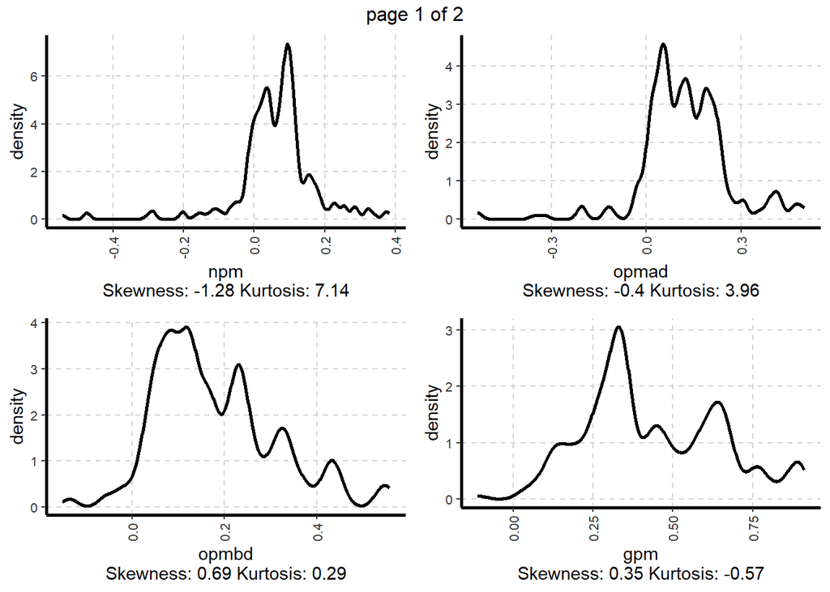

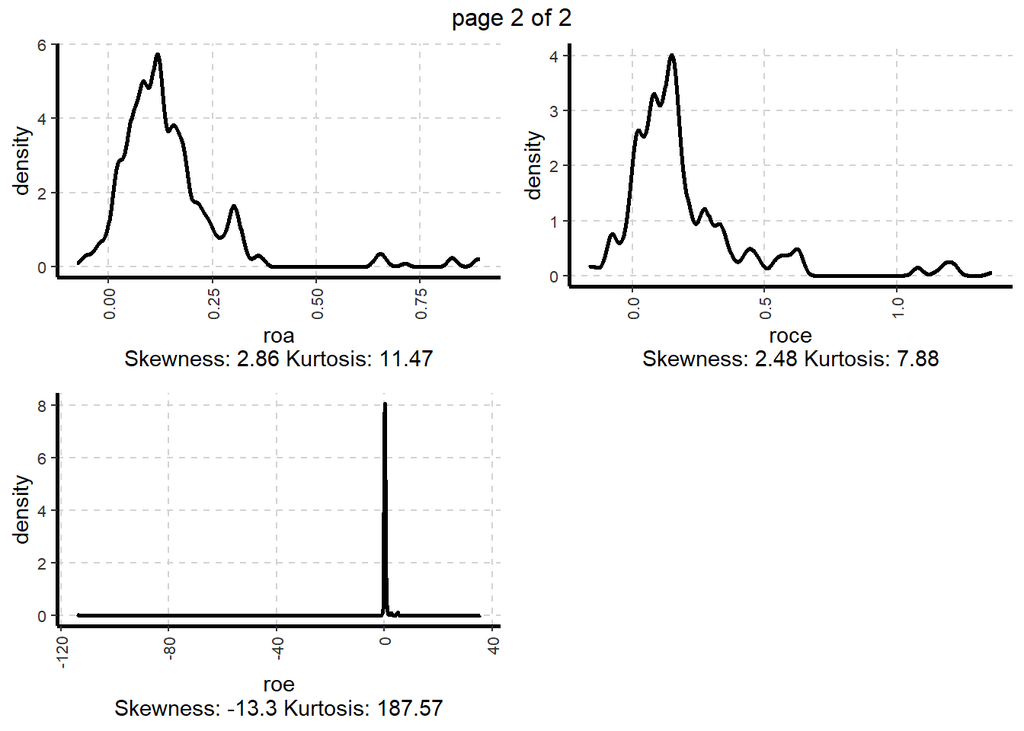

```r
#examine the distribution of the profitability ratios variables
Train %>%
  select(npm, opmbd, opmad, gpm, roa, roe, roce)%>%
  ExpNumViz(target = NULL,
            nlim = 10,
            Page = c(2,2))
```

```
$`0`
```

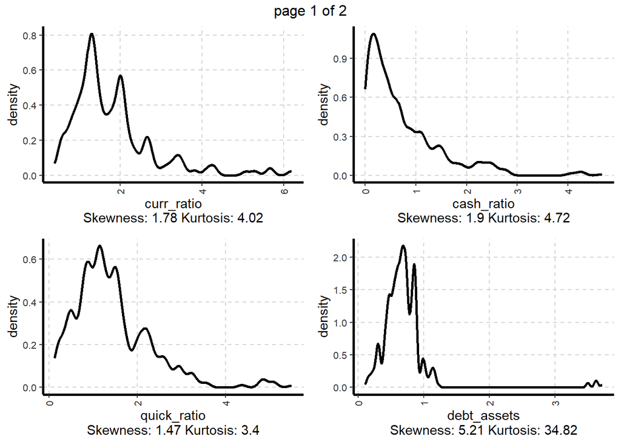

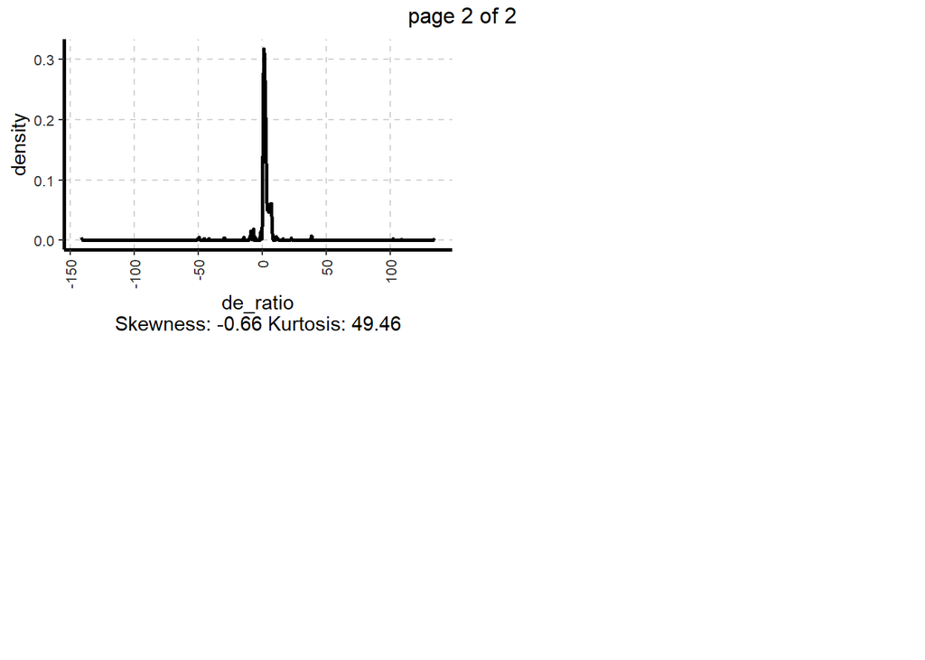

```r
#examine the distribution of liquidity and solvency ratios
Train %>%
  select(curr_ratio, quick_ratio,cash_ratio,debt_assets,de_ratio)%>%
  ExpNumViz(target = NULL,
            nlim = 10,
            Page = c(2,2))
```

Observations : Majority of the companies’ liquidity ratios ranges between 0 and 2, with a few companies having higher ratios and performing better in terms of liquidity. However, most companies appears to be healthy in terms of solvency, with relatively lower debt to assets ratio. Debt to equity ratios peak at 1 indicating low reliance of debts compared to equity for these companies, indicative of companies’ strong financial position with minimal financial risk associated with debt.

```
$`0`
```

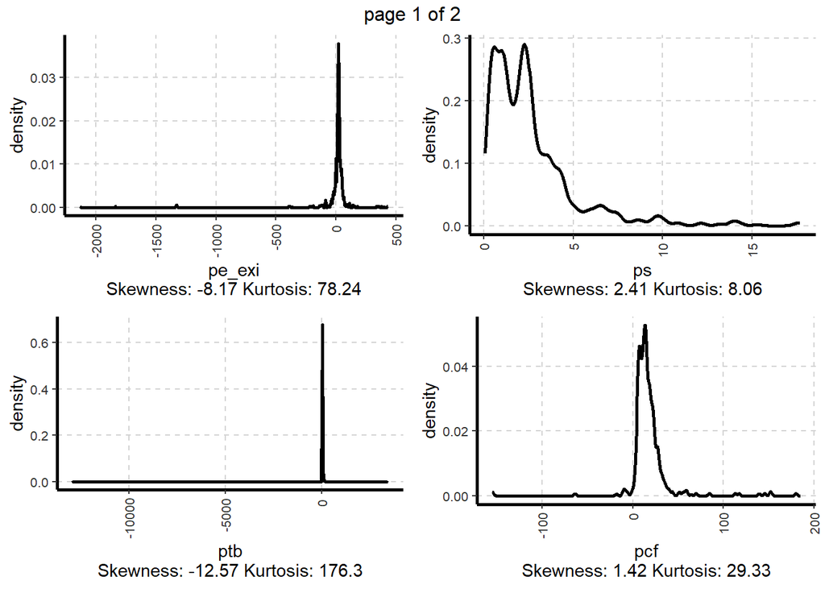

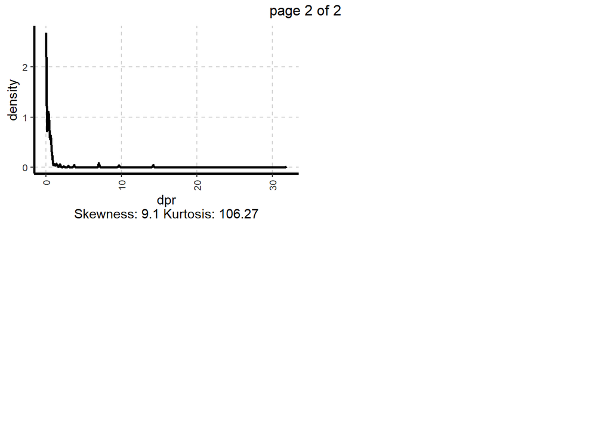

```r
#examine the distribution of valuation ratios
Train %>%
  select(pe_exi, ptb, ps, pcf, dpr)%>%
  ExpNumViz(target = NULL,
            nlim = 10,
            Page = c(2,2))
```

Observation: Price earnings (pe_exi) measures a company’s current share price to its earnings per share. higher PE ratio suggests that investors are willing to pay more for each unit of earnings, indicating a potentially overvalued stock.

Price to sales (ps) ratio helps evaluate a company’s valuation relative to its sales. A lower PS ratio may indicate that the stock is undervalued compared to its revenue.

Price to book (ptb) ratio compares a company’s market capitalization to its book value per share (BVPS). A lower PTB ratio may suggest that the stock is undervalued relative to its book value.

Price to cashflow (pcf) ratio compares a company’s market capitalization to its cash flow per share. It helps assess a company’s valuation relative to its cash flow generation. A lower PCF ratio may indicate that the stock is undervalued compared to its cash flow

Majority of the companies has lower pe/ps/ptb/pcf ratio as suggested by the density plot may suggest possible chances of these companies stock being undervalued.

Dividend payout ratio (dpr) provides valuable insights into how much of a company’s earnings are returned to shareholders as dividends.The dpr is relatively consistent across industry indicative that most companies pays about the same proportions of their earnings as dividends compared to their industry peers

### 4.6 Visual Analysis of Profile Bio Readability

Using ggplot aes function, we perform visual analysis of the readability of the profile bio across the 95 companies

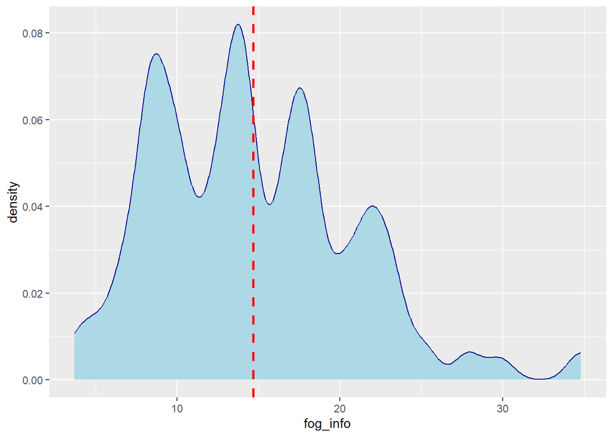

```r
#examine the readability across the profile bio of the 95 companies
#fog_info
ggplot(Train, aes(x=fog_info)) + geom_density(color="darkblue", fill="lightblue")+
geom_vline(aes(xintercept=mean(fog_info)), color="red", linetype="dashed", size=1)
```

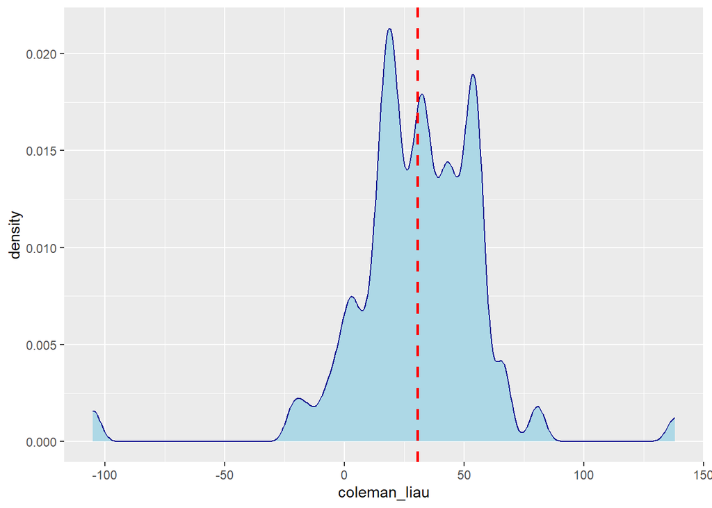

```r
#coleman_liau
ggplot(Train, aes(x=coleman_liau)) + geom_density(color="darkblue", fill="lightblue")+
geom_vline(aes(xintercept=mean(coleman_liau)), color="red", linetype="dashed", size=1)
```

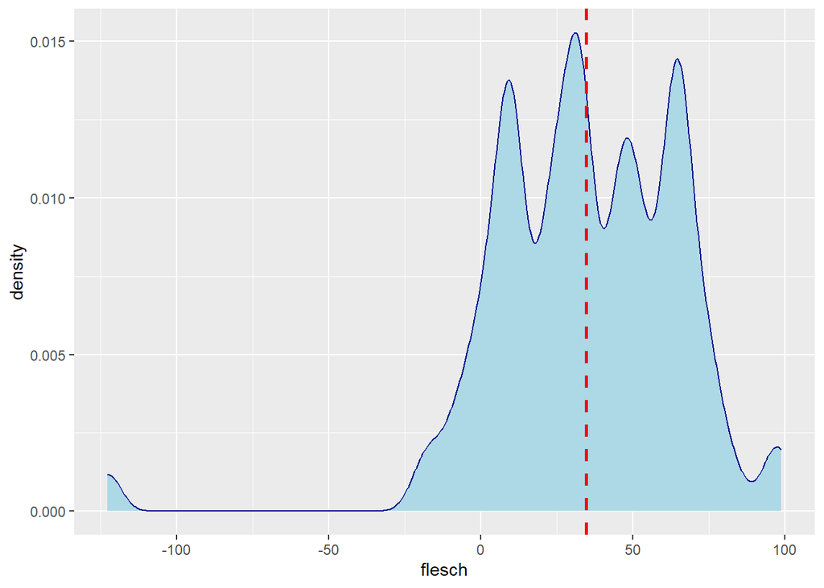

```r
#flesch
ggplot(Train, aes(x=flesch)) + geom_density(color="darkblue", fill="lightblue")+
geom_vline(aes(xintercept=mean(flesch)), color="red", linetype="dashed", size=1)
```

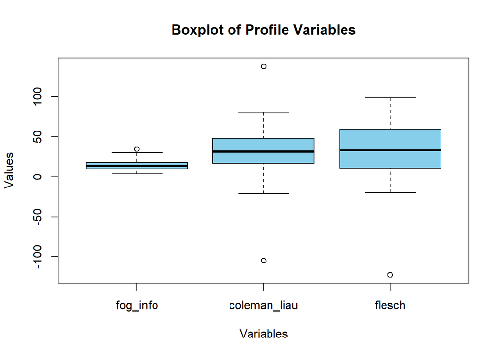

```r
# select the columns containing financial ratios and profile variables
variables_of_interest <- c("fog_info", "coleman_liau", "flesch")

# create a boxplot for each variable
boxplot(Train[, variables_of_interest],
        main = "Boxplot of Profile Variables",
        xlab = "Variables",
        ylab = "Values",
        col = "skyblue",  # Boxplot color
        border = "black", # Boxplot border color
        horizontal = FALSE)  # Horizontal boxplot for better visualization if many variables
```

Observation: Fog_info and Coleman_liau measures readability of profile_bio in the same measure. The lower the score the better the readability. The Flesch score on the other hand is reflects better readability with a higher score.

It is noted that there is a few outliers in the readability score which could be a result of removal of hashtags from the profile bio before assessing its readability. some of the profile bios are predominantly hashtags and removing the hashtags before assessing its readability can result in distorted results. In order to not penalise profile bios with many hashtags on readability, we balance it out by including the no of hashtags as part of our profile variables for prediction of Twitter followers growth.

### 4.7 Descriptive Statistic Table

Using the descriptive statistic table, we assess the mean, standard deviation, median of the financial variables. This provides insights on the financial ratio’s distribution and variability.

```r
# examine the descriptive statistics (mean, standard deviation, median)
library(psych)
table_stat <- describe(Train)
table_stat[,c(3,4,5,8,9)]
```

```
                             mean        sd      median         min         max
date                  20170367.49    171.07 20170331.00 20170102.00 20170630.00
gvkey                    52637.36  64812.77    14412.00     1161.00   184500.00
atq                      28847.89  68309.71     5345.10       28.76   500162.00
p_daily_change               0.00      0.03        0.00       -0.39        0.48
volatile                     0.02      0.02        0.01        0.00        0.56
p_daily_change_lag           0.00      0.02        0.00       -0.39        0.48
volatile_lag                 0.02      0.02        0.01        0.00        0.69
bm                           0.38      0.34        0.31       -0.25        2.35
pe_exi                       0.90    182.47       20.32    -2135.00      432.60
ps                           2.62      2.46        2.13        0.07       17.70
pcf                         17.13     22.48       14.10     -154.72      184.75
dpr                          0.62      2.19        0.24        0.00       31.92
npm                          0.06      0.11        0.07       -0.54        0.38
opmbd                        0.18      0.13        0.15       -0.15        0.56
opmad                        0.12      0.14        0.12       -0.54        0.50
gpm                          0.44      0.21        0.36       -0.11        0.91
roa                          0.15      0.14        0.12       -0.08        0.90
roe                         -0.24      8.07        0.12     -114.00       35.65
roce                         0.19      0.23        0.14       -0.16        1.36
debt_at                      0.32      0.38        0.29        0.00        3.16
de_ratio                     1.80     16.43        1.64     -141.44      134.26
intcov                      44.63    477.78        4.79      -26.34     7082.56
cash_ratio                   0.73      0.75        0.48        0.00        4.67
quick_ratio                  1.43      0.88        1.25        0.13        5.50
curr_ratio                   1.80      1.01        1.53        0.40        6.20
inv_turn                    28.79     72.67        5.50        0.57      446.27
at_turn                      0.98      0.72        0.71        0.11        3.67
debt_assets                  0.70      0.41        0.66        0.11        3.72
ptb                        -36.48    928.54        2.85   -12929.64     3399.45
rect_turn                   15.11     20.86        7.42        0.14      109.77
sale_nwc                    26.63    213.01        3.93      -84.96     2500.65
divyield                     0.02      0.01        0.02        0.00        0.12
bm_lag                       0.39      0.34        0.32       -0.27        2.35
pe_exi_lag                  -4.66    213.60       20.16    -2260.00      432.60
ps_lag                       2.57      2.37        2.10        0.11       17.70
pcf_lag                     16.24     21.34       14.16     -166.46      179.62
dpr_lag                      0.54      1.51        0.24        0.00       31.92
npm_lag                      0.06      0.11        0.07       -0.54        0.38
opmbd_lag                    0.18      0.13        0.15       -0.14        0.56
```

[output cut: 33 more lines]

```
days_joined               2280.92   1205.10     2762.00    -2098.00     3377.00
years_joined                 6.24      3.30        7.56       -5.74        9.25
months_joined               74.55     39.34       90.00      -68.00      110.00
pop_ind                      0.31      0.46        0.00        0.00        1.00
is_mon                       0.16      0.36        0.00        0.00        1.00
is_tue                       0.17      0.37        0.00        0.00        1.00
is_wed                       0.17      0.37        0.00        0.00        1.00
is_thu                       0.17      0.38        0.00        0.00        1.00
is_fri                       0.17      0.37        0.00        0.00        1.00
is_sat                       0.09      0.29        0.00        0.00        1.00
followers               195248.35 363236.77    24772.50      246.00  1929880.00
ID*                       6047.50   3491.38     6047.50        1.00    12094.00
sic                       5056.90   1834.70     5065.00     1311.00     8742.00
followers_lag           195128.61 362916.40    24765.50      246.00  1925753.00
growth_rate                  0.00      0.00        0.00       -0.03        0.05
```

### 4.8 Multicollinearity Test

To study the multicollinearity between financial variables, we construct a correlation matrix to explore pairwise correlations among the variables. By visualizing the correlation matrix using corrplot(), we are able to identify the correlated pairs. Consequently, we remove 1 of the correlated variables in our regression model to reduce the introduction of error term in the model (i.e.one of the assumptions of regression is that variables are not correlated.)

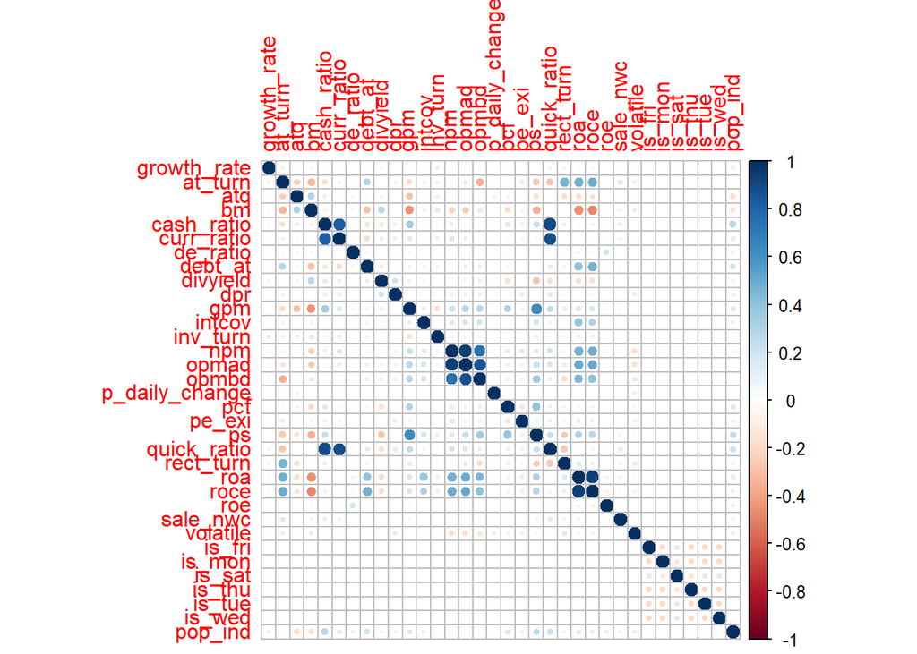

```r
# multicollinearity test on financial variables
# select financial correlation variables
correlation_fin_var <- Train %>% select(growth_rate, at_turn, atq, bm, cash_ratio, curr_ratio,
                                    de_ratio, debt_at, divyield, dpr, gpm, intcov, inv_turn, npm,
                                    opmad, opmbd, p_daily_change, pcf, pe_exi, ps, quick_ratio,
                                    rect_turn, roa, roce, roe, sale_nwc, volatile, is_fri, is_mon,
                                    is_sat, is_thu, is_tue,is_wed, pop_ind)

# correlation matrix
library(corrplot)
correlation <- cor(correlation_fin_var, use="pairwise.complete.obs")
corrplot(correlation)
```

Similarly, we conducted a multicollinearity test on non-financial variables. We first construct a correlation matrix to explore pairwise correlations among non financial variables. By visualizing the correlation matrix using corrplot(), we aim to identify multicollinearity issues. It is worthy to note that the days_joined, months_joined and years_joined are highly correlated. Thus, we only retain days_joined variable in the construction of our non financial variables model as the days_joined variable has greater variability in terms of data compared to the other two.

```r
# multicollinearity test on non financial data

# select non financial correlated variables
correlation_non_fin_var <- Train %>% select(atq, is_annouce, red_annouce, no_annoucement, TFF, coleman_liau, flesch, fog_info, num_words, bio_complete, has_url, hashtags_count, has_hashtags, contains_company_name, contains_words, custom_content, days_joined, years_joined, months_joined,
pop_ind,is_mon,is_tue,is_wed,is_thu,is_fri,is_sat)

# correlation matrix
cor(correlation_non_fin_var)
```

```
                            atq is_annouce red_annouce no_annoucement       TFF
atq                    1.000000  0.0843605   0.0436976      0.1093040  0.338662
is_annouce             0.084360  1.0000000   0.2721607      0.7277760  0.072768
red_annouce            0.043698  0.2721607   1.0000000      0.2232720  0.042558
no_annoucement         0.109304  0.7277760   0.2232720      1.0000000  0.040710
TFF                    0.338662  0.0727680   0.0425583      0.0407099  1.000000
coleman_liau          -0.013430 -0.0230916   0.0095778     -0.0270647  0.033211
flesch                 0.025514 -0.0131367   0.0028175     -0.0142399  0.106254
fog_info              -0.055794 -0.0041122   0.0062094     -0.0016299 -0.047365
num_words              0.051410  0.0082365  -0.0204960     -0.0111726  0.018341
bio_complete           0.231862  0.0430806   0.0137354      0.0377542  0.201936
has_url                0.125296  0.0432897   0.0058323      0.0395845  0.073014
hashtags_count        -0.086447 -0.0008502   0.0021443     -0.0006791 -0.047018
has_hashtags          -0.155222 -0.0165677   0.0038319     -0.0140991 -0.076617
contains_company_name -0.033779  0.0216150   0.0221172      0.0035510  0.142158
contains_words         0.040459 -0.0570505  -0.0219036     -0.0393262 -0.103136
custom_content         0.000336  0.0331894  -0.0051374      0.0375625 -0.073381
days_joined            0.148216  0.0226383   0.0020527      0.0185333  0.142188
years_joined           0.148216  0.0226383   0.0020527      0.0185333  0.142188
months_joined          0.148184  0.0226844   0.0021156      0.0185043  0.142632
pop_ind               -0.181242 -0.0031139   0.0068569     -0.0065528 -0.082566
is_mon                 0.001364 -0.0143537  -0.0181555      0.0028744 -0.005480
is_tue                 0.003186  0.0619763   0.0004612      0.0505000 -0.008301
is_wed                -0.001562  0.0773822   0.0116880      0.0455152 -0.008319
is_thu                 0.002114  0.0344638   0.0026271      0.0224441 -0.009388
is_fri                 0.001622 -0.0351769   0.0354713     -0.0287121 -0.007434
is_sat                 0.001006 -0.0843301  -0.0206937     -0.0632632  0.025104
                      coleman_liau    flesch   fog_info  num_words bio_complete
atq                      -0.013430  0.025514 -0.0557935  0.0514098   0.23186201
is_annouce               -0.023092 -0.013137 -0.0041122  0.0082365   0.04308063
red_annouce               0.009578  0.002818  0.0062094 -0.0204960   0.01373544
no_annoucement           -0.027065 -0.014240 -0.0016299 -0.0111726   0.03775420
TFF                       0.033211  0.106254 -0.0473646  0.0183407   0.20193568
coleman_liau              1.000000  0.845450 -0.6288060  0.0555051  -0.23987680
flesch                    0.845450  1.000000 -0.8636924  0.0886831  -0.09731709
fog_info                 -0.628806 -0.863692  1.0000000 -0.0452220   0.04932968
num_words                 0.055505  0.088683 -0.0452220  1.0000000   0.00038193
bio_complete             -0.239877 -0.097317  0.0493297  0.0003819   1.00000000
has_url                  -0.218247 -0.136684  0.1012728  0.2792596   0.15864096
hashtags_count           -0.550152 -0.561895  0.3862491 -0.0363403   0.28596530
```

[output cut: 134 more lines]

```
hashtags_count         0.00228888
has_hashtags          -0.00065432
contains_company_name  0.00785485
contains_words         0.00638836
custom_content        -0.01701181
days_joined           -0.01636586
years_joined          -0.01636586
months_joined         -0.01606182
pop_ind                0.00846416
is_mon                -0.13683778
is_tue                -0.14229311
is_wed                -0.14313895
is_thu                -0.14406750
is_fri                -0.14199667
is_sat                 1.00000000
```

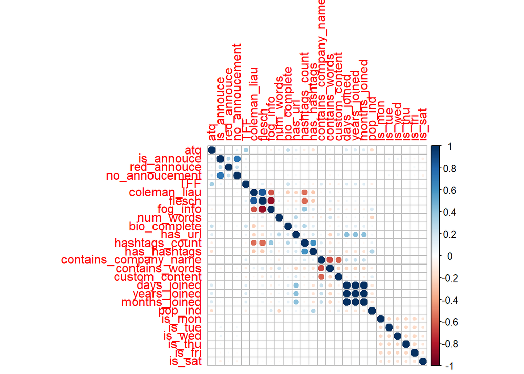

```r
library(corrplot)
correlation <- cor(correlation_non_fin_var, use="pairwise.complete.obs")
corrplot(correlation)
```

## 5. Financial Model

### 5.1 Financial Model Construction

In this section, we build a model utilizing financial data exclusively. The 6 models constructed based on financial ratios is as follows:

Model 1: Financial ratios + stock price (daily change rate and daily volatile) + industry dummy (popular industry = 1) + week dummy + log (asset)

We create a linear regression model (**`Model1`**) to predict the growth rate (**`growth_rate`**). The formula for the model (**`Mod1_formula`**) is specified to capture the relationship between the growth rate and the predictor variables. Specifically, the formula encompasses financial ratios, along with indicators for each day of the week, and the logarithm of “atq” as a measure of company size.

```r
# Model 1 formula : stock price and financial ratios model

Mod1_formula <- as.formula("growth_rate ~ bm + pe_exi + ps + pcf + dpr + npm + opmbd + opmad + gpm + roa + roe + roce + debt_at + de_ratio + intcov + cash_ratio + quick_ratio + curr_ratio + inv_turn + at_turn + debt_assets + ptb + rect_turn + sale_nwc + divyield + p_daily_change + volatile + pop_ind + is_mon + is_tue + is_wed + is_thu + is_fri + is_sat + log(atq)")

# run regression Model 1
Model1 <- lm(Mod1_formula,data=Train)
summary(Model1)
```

```
Call:
lm(formula = Mod1_formula, data = Train)

Residuals:
     Min       1Q   Median       3Q      Max
-0.03475 -0.00050 -0.00016  0.00017  0.04853

Coefficients:
                     Estimate     Std. Error t value             Pr(>|t|)
(Intercept)     0.00099129740  0.00018940402    5.23           0.00000017 ***
bm              0.00020943956  0.00006506980    3.22              0.00129 **
pe_exi          0.00000016681  0.00000009153    1.82              0.06842 .
ps             -0.00002530565  0.00001091684   -2.32              0.02046 *
pcf             0.00000047145  0.00000077664    0.61              0.54383
dpr             0.00001537373  0.00000730305    2.11              0.03530 *
npm             0.00157818107  0.00050080720    3.15              0.00163 **
opmbd           0.00116122525  0.00035804934    3.24              0.00119 **
opmad          -0.00040303160  0.00050955556   -0.79              0.42899
gpm            -0.00022668388  0.00012086483   -1.88              0.06075 .
roa            -0.00139662961  0.00043590357   -3.20              0.00136 **
roe            -0.00001004940  0.00000945547   -1.06              0.28789
roce           -0.00012981365  0.00025878989   -0.50              0.61595
debt_at         0.00072203753  0.00014763756    4.89           0.00000102 ***
de_ratio        0.00000071846  0.00000094921    0.76              0.44913
intcov         -0.00000000566  0.00000003631   -0.16              0.87606
cash_ratio      0.00006458046  0.00005719414    1.13              0.25886
quick_ratio    -0.00003988850  0.00006430089   -0.62              0.53504
curr_ratio     -0.00001623344  0.00004013120   -0.40              0.68585
inv_turn        0.00000228300  0.00000021738   10.50 < 0.0000000000000002 ***
at_turn         0.00005591257  0.00004939197    1.13              0.25765
debt_assets    -0.00056024975  0.00015340403   -3.65              0.00026 ***
ptb             0.00000007935  0.00000008121    0.98              0.32853
rect_turn      -0.00000393660  0.00000098520   -4.00           0.00006488 ***
sale_nwc       -0.00000002751  0.00000007240   -0.38              0.70392
divyield       -0.01115519878  0.00125972699   -8.86 < 0.0000000000000002 ***
p_daily_change -0.00012340065  0.00058028897   -0.21              0.83160
volatile        0.00272414757  0.00084364896    3.23              0.00125 **
pop_ind         0.00033778263  0.00003810149    8.87 < 0.0000000000000002 ***
is_mon          0.00018968282  0.00006445277    2.94              0.00326 **
is_tue          0.00017777981  0.00006377328    2.79              0.00532 **
is_wed          0.00017917172  0.00006366429    2.81              0.00490 **
is_thu          0.00013251282  0.00006357472    2.08              0.03715 *
is_fri          0.00016543170  0.00006379994    2.59              0.00953 **
is_sat         -0.00001432343  0.00007151164   -0.20              0.84125
log(atq)       -0.00002954885  0.00001081365   -2.73              0.00629 **
---
Signif. codes:  0 '***' 0.001 '**' 0.01 '*' 0.05 '.' 0.1 ' ' 1

Residual standard error: 0.00163 on 12058 degrees of freedom
Multiple R-squared:  0.0498,    Adjusted R-squared:  0.047
F-statistic: 18.1 on 35 and 12058 DF,  p-value: <0.0000000000000002
```

Model 2: Financial ratios lag value + stock price (daily change rate and daily volatile) + industry dummy (popular industry = 1) + week dummy + log (asset).

We create a linear regression model (**`Model2`**) to predict the growth rate (**`growth_rate`**). The formula for the model (**`Mod2_formula`**) is specified to capture the relationship between the growth rate and a set of lagged predictor variables encompassing financial metrics, along with indicators for each day of the week, and the logarithm of “atq” as a measure of company size.

```r
# Model 2 formula : financial ratios (lag), stock price (lag)
Mod2_formula <- as.formula("growth_rate ~ bm_lag + pe_exi_lag + ps_lag + pcf_lag + dpr_lag +
                          npm_lag+ opmbd_lag + opmad_lag + gpm_lag + roa_lag +roe_lag + roce_lag +                           debt_at_lag + de_ratio_lag + intcov_lag + cash_ratio_lag +
                          quick_ratio_lag + curr_ratio_lag + inv_turn_lag + at_turn_lag +
                          debt_assets_lag + ptb_lag + rect_turn_lag + sale_nwc_lag +
                          divyield_lag + p_daily_change_lag + volatile_lag +
                          pop_ind + is_mon + is_tue + is_wed + is_thu + is_fri + is_sat +
                          log(atq)")

# run regression Model 2
Model2 <- lm(Mod2_formula,data=Train)
summary(Model2)
```

```
Call:
lm(formula = Mod2_formula, data = Train)

Residuals:
     Min       1Q   Median       3Q      Max
-0.03469 -0.00051 -0.00016  0.00017  0.04861

Coefficients:
                         Estimate     Std. Error t value             Pr(>|t|)
(Intercept)         0.00120357014  0.00018937516    6.36       0.000000000215
bm_lag              0.00022125384  0.00006690617    3.31              0.00095
pe_exi_lag          0.00000019283  0.00000007826    2.46              0.01375
ps_lag             -0.00003239246  0.00001140321   -2.84              0.00451
pcf_lag            -0.00000103336  0.00000077146   -1.34              0.18044
dpr_lag             0.00004966276  0.00001104911    4.49       0.000007030782
npm_lag             0.00122650210  0.00047923354    2.56              0.01050
opmbd_lag           0.00116271580  0.00037053664    3.14              0.00171
opmad_lag          -0.00018050930  0.00050638688   -0.36              0.72150
gpm_lag            -0.00014463761  0.00012184062   -1.19              0.23521
roa_lag            -0.00203778475  0.00045739802   -4.46       0.000008458280
roe_lag            -0.00001166243  0.00000946454   -1.23              0.21789
roce_lag            0.00029579451  0.00025996517    1.14              0.25522
debt_at_lag         0.00105044872  0.00015127257    6.94       0.000000000004
de_ratio_lag        0.00000076882  0.00000095456    0.81              0.42059
intcov_lag          0.00000000252  0.00000003293    0.08              0.93907
cash_ratio_lag      0.00005735713  0.00005647762    1.02              0.30985
quick_ratio_lag    -0.00006210663  0.00006536935   -0.95              0.34209
curr_ratio_lag     -0.00001299673  0.00004242373   -0.31              0.75934
inv_turn_lag        0.00000197711  0.00000020259    9.76 < 0.0000000000000002
at_turn_lag         0.00004942583  0.00005155061    0.96              0.33769
debt_assets_lag    -0.00088809916  0.00015654748   -5.67       0.000000014352
ptb_lag             0.00000009139  0.00000008074    1.13              0.25771
rect_turn_lag      -0.00000443952  0.00000102097   -4.35       0.000013830973
sale_nwc_lag       -0.00000002592  0.00000008633   -0.30              0.76402
divyield_lag       -0.01374826753  0.00141439410   -9.72 < 0.0000000000000002
p_daily_change_lag -0.00026916281  0.00059838587   -0.45              0.65285
volatile_lag        0.00258866040  0.00082678012    3.13              0.00175
pop_ind             0.00034780813  0.00003808504    9.13 < 0.0000000000000002
is_mon              0.00018300397  0.00006442314    2.84              0.00451
is_tue              0.00017469651  0.00006374512    2.74              0.00614
```

[output cut: 33 more lines]

```
volatile_lag       **
pop_ind            ***
is_mon             **
is_tue             **
is_wed             **
is_thu             *
is_fri             *
is_sat
log(atq)           **
---
Signif. codes:  0 '***' 0.001 '**' 0.01 '*' 0.05 '.' 0.1 ' ' 1

Residual standard error: 0.00163 on 12058 degrees of freedom
Multiple R-squared:  0.0503,    Adjusted R-squared:  0.0476
F-statistic: 18.3 on 35 and 12058 DF,  p-value: <0.0000000000000002
```

Model 3: Financial ratios value + stock price (daily change rate and daily volatile) + industry dummy (popular industry = 1) + week dummy + log (asset) + industry fixed effect

This model is used to predict the growth rate (**`growth_rate`**) while incorporating industry fixed effects. The **`update()`** function is used to modify the original formula (**`Mod1_formula`**) by adding a categorical variable representing the industry (**`sic`**) as a fixed effect. This sic variable is converted into a factor using the **`factor()`** function.

```r
# run regression Model 3 : Model 1 with industry FE
Mod3_formula <- update(Mod1_formula, . ~ . + factor(sic))
Model3 <- lm(Mod3_formula,data=Train)
summary(Model3)
```

```
Call:
lm(formula = Mod3_formula, data = Train)

Residuals:
     Min       1Q   Median       3Q      Max
-0.03609 -0.00036 -0.00007  0.00018  0.04721

Coefficients:
                     Estimate    Std. Error t value             Pr(>|t|)
(Intercept)      0.0008602457  0.0005390637    1.60              0.11056
bm              -0.0004421752  0.0001335717   -3.31              0.00093 ***
pe_exi          -0.0000000300  0.0000001020   -0.29              0.76830
ps               0.0000093544  0.0000173804    0.54              0.59044
pcf              0.0000007190  0.0000007933    0.91              0.36474
dpr             -0.0000092755  0.0000084064   -1.10              0.26988
npm              0.0031370410  0.0007355032    4.27    0.000020128696290 ***
opmbd            0.0021090813  0.0011747501    1.80              0.07262 .
opmad           -0.0016109971  0.0012457667   -1.29              0.19597
gpm             -0.0009739161  0.0002905770   -3.35              0.00081 ***
roa             -0.0014708261  0.0010432730   -1.41              0.15862
roe             -0.0000174416  0.0000106225   -1.64              0.10062
roce            -0.0013271764  0.0005689873   -2.33              0.01969 *
debt_at          0.0008158083  0.0004288199    1.90              0.05714 .
de_ratio         0.0000004936  0.0000009432    0.52              0.60078
intcov           0.0000000891  0.0000000390    2.28              0.02255 *
cash_ratio      -0.0010865415  0.0001583392   -6.86    0.000000000007119 ***
quick_ratio      0.0026319988  0.0002458311   10.71 < 0.0000000000000002 ***
curr_ratio      -0.0015265212  0.0001522969  -10.02 < 0.0000000000000002 ***
inv_turn         0.0000020878  0.0000003897    5.36    0.000000085870701 ***
at_turn         -0.0008020013  0.0001278927   -6.27    0.000000000371315 ***
debt_assets      0.0002096741  0.0004037895    0.52              0.60359
ptb              0.0000001364  0.0000000879    1.55              0.12074
rect_turn        0.0000011292  0.0000026281    0.43              0.66744
sale_nwc         0.0000000857  0.0000000966    0.89              0.37524
divyield        -0.0061391740  0.0024956957   -2.46              0.01391 *
p_daily_change   0.0000080407  0.0005682501    0.01              0.98871
volatile         0.0023314624  0.0009267399    2.52              0.01189 *
pop_ind          0.0000832446  0.0001317979    0.63              0.52766
is_mon           0.0001240753  0.0000618797    2.01              0.04497 *
is_tue           0.0000940221  0.0000612736    1.53              0.12494
```

[output cut: 57 more lines]

```
factor(sic)7370  0.0008322779  0.0004419068    1.88              0.05967 .
factor(sic)7372  0.0003732385  0.0004944361    0.75              0.45034
factor(sic)7389 -0.0003472054  0.0004814406   -0.72              0.47081
factor(sic)7900 -0.0003020987  0.0004990926   -0.61              0.54499
factor(sic)7990  0.0011687506  0.0004740163    2.47              0.01369 *
factor(sic)8700  0.0006414839  0.0005282550    1.21              0.22464
factor(sic)8721  0.0000507784  0.0005656626    0.09              0.92847
factor(sic)8731 -0.0004247040  0.0004259101   -1.00              0.31870
factor(sic)8742  0.0001940028  0.0004478536    0.43              0.66489
---
Signif. codes:  0 '***' 0.001 '**' 0.01 '*' 0.05 '.' 0.1 ' ' 1

Residual standard error: 0.00155 on 11997 degrees of freedom
Multiple R-squared:  0.143, Adjusted R-squared:  0.137
F-statistic: 20.9 on 96 and 11997 DF,  p-value: <0.0000000000000002
```

Model 4: Financial ratios lag value + stock price (daily change rate and daily volatile) + industry dummy (popular industry = 1) + week dummy + log (asset) + industry fixed effect

This model is used to predict the growth rate (**`growth_rate`**) while integrating lagged predictor variables and industry fixed effects. The formula for the model (**`Mod4_formula`**) is updated using the **`update()`** function, where the original formula (**`Mod2_formula`**) is modified to include the industry (**`sic`**) as a fixed effect. The industry variable is converted into a factor using the **`factor()`** function.

```r
# run regression Model 4 : Model 2 with industry FE
Mod4_formula <- update(Mod2_formula, . ~ . + factor(sic))
Model4 <- lm(Mod4_formula,data=Train)
summary(Model4)
```

```
Call:
lm(formula = Mod4_formula, data = Train)

Residuals:
     Min       1Q   Median       3Q      Max
-0.03620 -0.00037 -0.00007  0.00018  0.04711

Coefficients:
                        Estimate    Std. Error t value             Pr(>|t|)
(Intercept)         0.0015890880  0.0006188367    2.57              0.01024 *
bm_lag             -0.0004632444  0.0001462050   -3.17              0.00154 **
pe_exi_lag          0.0000000164  0.0000000923    0.18              0.85892
ps_lag              0.0000051047  0.0000185917    0.27              0.78365
pcf_lag            -0.0000002124  0.0000007965   -0.27              0.78973
dpr_lag            -0.0000308349  0.0000168886   -1.83              0.06791 .
npm_lag             0.0032502320  0.0006992424    4.65     0.00000338381349 ***
opmbd_lag           0.0011105735  0.0013166953    0.84              0.39899
opmad_lag          -0.0003080087  0.0013167211   -0.23              0.81505
gpm_lag            -0.0009194872  0.0003154941   -2.91              0.00357 **
roa_lag            -0.0025261113  0.0011294959   -2.24              0.02534 *
roe_lag            -0.0000262679  0.0000103832   -2.53              0.01142 *
roce_lag           -0.0010872896  0.0005746123   -1.89              0.05849 .
debt_at_lag         0.0010948101  0.0004506028    2.43              0.01513 *
de_ratio_lag        0.0000006180  0.0000009425    0.66              0.51204
intcov_lag          0.0000000934  0.0000000387    2.41              0.01590 *
cash_ratio_lag     -0.0011459730  0.0001565613   -7.32     0.00000000000026 ***
quick_ratio_lag     0.0025623046  0.0002438983   10.51 < 0.0000000000000002 ***
curr_ratio_lag     -0.0014371282  0.0001536279   -9.35 < 0.0000000000000002 ***
inv_turn_lag        0.0000016491  0.0000003521    4.68     0.00000284155243 ***
at_turn_lag        -0.0008036768  0.0001418969   -5.66     0.00000001514517 ***
debt_assets_lag    -0.0000150637  0.0004287205   -0.04              0.97197
ptb_lag             0.0000002047  0.0000000861    2.38              0.01746 *
rect_turn_lag       0.0000005591  0.0000028096    0.20              0.84228
sale_nwc_lag        0.0000000975  0.0000001028    0.95              0.34258
divyield_lag       -0.0042278494  0.0032056579   -1.32              0.18724
p_daily_change_lag -0.0002969075  0.0005708728   -0.52              0.60301
volatile_lag        0.0020642831  0.0009052554    2.28              0.02261 *
pop_ind             0.0001193662  0.0001316882    0.91              0.36473
is_mon              0.0001287317  0.0000618501    2.08              0.03742 *
is_tue              0.0001007012  0.0000612612    1.64              0.10024
```

[output cut: 57 more lines]

```
factor(sic)7370     0.0003955656  0.0005316781    0.74              0.45689
factor(sic)7372    -0.0002224203  0.0005865445   -0.38              0.70454
factor(sic)7389    -0.0009801915  0.0005729299   -1.71              0.08714 .
factor(sic)7900    -0.0006906373  0.0005705196   -1.21              0.22610
factor(sic)7990     0.0006168698  0.0005566582    1.11              0.26781
factor(sic)8700     0.0000932744  0.0006152956    0.15              0.87951
factor(sic)8721    -0.0006241204  0.0006417312   -0.97              0.33079
factor(sic)8731    -0.0010163610  0.0005031592   -2.02              0.04341 *
factor(sic)8742    -0.0002711206  0.0005209207   -0.52              0.60275
---
Signif. codes:  0 '***' 0.001 '**' 0.01 '*' 0.05 '.' 0.1 ' ' 1

Residual standard error: 0.00155 on 11997 degrees of freedom
Multiple R-squared:  0.145, Adjusted R-squared:  0.138
F-statistic: 21.1 on 96 and 11997 DF,  p-value: <0.0000000000000002
```

This model is used to forecast the growth rate (**`growth_rate`**) while incorporating both lagged predictor variables, firm fixed effects (**`gvkey`**), and industry fixed effects (**`sic`**). The formula for the model (**`Mod5_formula`**) is updated using the **`update()`** function, where the original formula (**`Mod2_formula`**) is modified to include firm fixed effects (**`gvkey`**) and industry fixed effects (**`sic`**). Both **`gvkey`** and **`sic`** are converted into factors using the **`factor()`** function.

```r
# run regression Model 5 : Model 2 with company FE and industry FE
Mod5_formula <- update(Mod2_formula, . ~ . + factor(gvkey) + factor(sic))
Model5 <- lm(Mod5_formula,data=Train)
summary(Model5)
```

```
Call:
lm(formula = Mod5_formula, data = Train)

Residuals:
     Min       1Q   Median       3Q      Max
-0.03651 -0.00030 -0.00006  0.00015  0.04680

Coefficients: (62 not defined because of singularities)
                          Estimate     Std. Error t value             Pr(>|t|)
(Intercept)          0.00452763266  0.00116923392    3.87              0.00011
bm_lag               0.00085493766  0.00037086970    2.31              0.02117
pe_exi_lag           0.00000000646  0.00000011559    0.06              0.95545
ps_lag              -0.00003141415  0.00003020849   -1.04              0.29840
pcf_lag             -0.00000107286  0.00000093445   -1.15              0.25094
dpr_lag             -0.00001885346  0.00002000577   -0.94              0.34601
npm_lag              0.00166005886  0.00103189369    1.61              0.10770
opmbd_lag           -0.00743509571  0.00220309101   -3.37              0.00074
opmad_lag            0.00491773297  0.00171489466    2.87              0.00414
gpm_lag             -0.00045163437  0.00085332679   -0.53              0.59663
roa_lag             -0.00100297024  0.00261248168   -0.38              0.70105
roe_lag             -0.00001189215  0.00001132547   -1.05              0.29372
roce_lag            -0.00008191210  0.00095832944   -0.09              0.93189
debt_at_lag         -0.00168732092  0.00111223421   -1.52              0.12928
de_ratio_lag        -0.00000004077  0.00000094365   -0.04              0.96554
intcov_lag           0.00000001289  0.00000004948    0.26              0.79444
cash_ratio_lag      -0.00057624270  0.00023695385   -2.43              0.01504
quick_ratio_lag      0.00013312675  0.00047589708    0.28              0.77968
curr_ratio_lag       0.00050187678  0.00038995733    1.29              0.19812
inv_turn_lag         0.00000063374  0.00000037370    1.70              0.08994
at_turn_lag         -0.00009569241  0.00040920857   -0.23              0.81511
debt_assets_lag      0.00221533934  0.00099428261    2.23              0.02589
ptb_lag              0.00000009987  0.00000009237    1.08              0.27960
rect_turn_lag        0.00000347927  0.00000452747    0.77              0.44222
sale_nwc_lag        -0.00000000536  0.00000010779   -0.05              0.96032
divyield_lag         0.00389416894  0.00551575465    0.71              0.48020
p_daily_change_lag  -0.00029134686  0.00056241143   -0.52              0.60445
volatile_lag         0.00161099110  0.00090754127    1.78              0.07590
pop_ind             -0.00520934063  0.00055626963   -9.36 < 0.0000000000000002
is_mon               0.00012938928  0.00006097105    2.12              0.03385
is_tue               0.00010201623  0.00006037679    1.69              0.09112
```

[output cut: 331 more lines]

```
factor(sic)7370
factor(sic)7372
factor(sic)7389
factor(sic)7900
factor(sic)7990
factor(sic)8700
factor(sic)8721
factor(sic)8731
factor(sic)8742
---
Signif. codes:  0 '***' 0.001 '**' 0.01 '*' 0.05 '.' 0.1 ' ' 1

Residual standard error: 0.00152 on 11971 degrees of freedom
Multiple R-squared:  0.173, Adjusted R-squared:  0.165
F-statistic: 20.6 on 122 and 11971 DF,  p-value: <0.0000000000000002
```

This model is used to predict the growth rate (**`growth_rate`**) while incorporating industry fixed effects (**`sic`**) and firm fixed effects (**`gvkey`**). The formula for the model (**`Mod6_formula`**) is updated using the **`update()`** function, where the original formula (**`Mod1_formula`**) is modified to include both firm and industry fixed effects. Both **`gvkey`** and **`sic`** are converted into factors using the **`factor()`** function.

```r
# run regression Model 6 : Model 1 with company FE and industry FE
Mod6_formula <- update(Mod1_formula, . ~ . + factor(gvkey) + factor(sic))
Model6 <- lm(Mod6_formula,data=Train)
summary(Model6)
```

```
Call:
lm(formula = Mod6_formula, data = Train)

Residuals:
     Min       1Q   Median       3Q      Max
-0.03671 -0.00031 -0.00006  0.00016  0.04659

Coefficients: (62 not defined because of singularities)
                         Estimate    Std. Error t value             Pr(>|t|)
(Intercept)          0.0035672945  0.0009754092    3.66              0.00026
bm                   0.0014408866  0.0003253341    4.43  0.00000955353169446
pe_exi              -0.0000000213  0.0000001177   -0.18              0.85642
ps                  -0.0000503214  0.0000303301   -1.66              0.09712
pcf                 -0.0000001370  0.0000008555   -0.16              0.87278
dpr                  0.0000019816  0.0000088131    0.22              0.82210
npm                  0.0012562163  0.0009750375    1.29              0.19764
opmbd               -0.0050791682  0.0017350288   -2.93              0.00342
opmad                0.0021831339  0.0015218565    1.43              0.15145
gpm                 -0.0014996273  0.0007731375   -1.94              0.05244
roa                  0.0014671344  0.0019956029    0.74              0.46224
roe                 -0.0000020906  0.0000123424   -0.17              0.86550
roce                -0.0006860936  0.0009366868   -0.73              0.46390
debt_at             -0.0036091814  0.0009866014   -3.66              0.00026
de_ratio             0.0000000193  0.0000009370    0.02              0.98354
intcov               0.0000000346  0.0000000464    0.75              0.45600
cash_ratio          -0.0003748254  0.0002359929   -1.59              0.11225
quick_ratio          0.0002443913  0.0003881562    0.63              0.52895
curr_ratio           0.0004019197  0.0002996748    1.34              0.17989
inv_turn             0.0000006977  0.0000004098    1.70              0.08869
at_turn             -0.0001742061  0.0002651174   -0.66              0.51114
debt_assets          0.0038764513  0.0008634498    4.49  0.00000720602171180
ptb                  0.0000000236  0.0000000990    0.24              0.81121
rect_turn            0.0000005103  0.0000038474    0.13              0.89449
sale_nwc             0.0000000399  0.0000000991    0.40              0.68728
divyield            -0.0007860379  0.0036235840   -0.22              0.82827
p_daily_change       0.0001171311  0.0005636690    0.21              0.83539
volatile             0.0020679656  0.0009336653    2.21              0.02679
pop_ind             -0.0045604931  0.0005240149   -8.70 < 0.0000000000000002
is_mon               0.0001294522  0.0000609232    2.12              0.03362
is_tue               0.0001043972  0.0000603152    1.73              0.08350
```

[output cut: 331 more lines]

```
factor(sic)7370
factor(sic)7372
factor(sic)7389
factor(sic)7900
factor(sic)7990
factor(sic)8700
factor(sic)8721
factor(sic)8731
factor(sic)8742
---
Signif. codes:  0 '***' 0.001 '**' 0.01 '*' 0.05 '.' 0.1 ' ' 1

Residual standard error: 0.00152 on 11971 degrees of freedom
Multiple R-squared:  0.174, Adjusted R-squared:  0.166
F-statistic: 20.7 on 122 and 11971 DF,  p-value: <0.0000000000000002
```

### 5.2 Financial (remove correlated variables)

```r
# remove some high correlated variables
# remove roce,quick_ratio,opmbd,opmad

Mod7_formula<- as.formula("growth_rate ~ bm + pe_exi + ps + pcf + dpr + npm + gpm + roa + roe + debt_at + de_ratio + intcov + cash_ratio  + curr_ratio + inv_turn + at_turn +debt_assets + ptb + rect_turn + sale_nwc + divyield + p_daily_change +  volatile + pop_ind + is_mon + is_tue + is_wed + is_thu + is_fri + is_sat + log(atq)")

Mod8_formula<- as.formula("growth_rate ~ bm_lag + pe_exi_lag + ps_lag + pcf_lag + dpr_lag +
npm_lag + gpm_lag + roa_lag +roe_lag + debt_at_lag + de_ratio_lag + intcov_lag + cash_ratio_lag + curr_ratio_lag + inv_turn_lag + at_turn_lag + debt_assets_lag + ptb_lag + rect_turn_lag + sale_nwc_lag + divyield_lag + p_daily_change_lag + volatile_lag + pop_ind + is_mon + is_tue + is_wed + is_thu + is_fri + is_sat + log(atq)")
```

```r
# # run regression Model7 : stock price and financial ratios (remove correlated variables)
Model7 <- lm(Mod7_formula,data=Train)

# run regression Model8 : stock price (lag) and financial ratios (lag, remove correlated variables)
Model8 <-lm(Mod8_formula,data=Train)

# run regression Model9 : Model7 (remove correlated variables) with industry FE
Mod9_formula <- update(Mod7_formula, . ~ . + factor(sic))
Model9 <- lm(Mod9_formula,data=Train)

# run regression Model10 : Model8 (lag, remove correlated variables) with industry FE
Mod10_formula <- update(Mod8_formula, . ~ . + factor(sic))
Model10 <-lm(Mod10_formula,data=Train)

# run regression Model11 : Model7 (remove correlated variables) with industry FE and firm FE
Mod11_formula <- update(Mod7_formula, . ~ . + factor(gvkey) + factor(sic))
Model11 <-lm(Mod11_formula,data=Train)

# run regression Model12 : Model8 (lag, remove correlated variables) with industry FE and firm FE
Mod12_formula <- update(Mod8_formula, . ~ . + factor(gvkey) + factor(sic))
Model12 <-lm(Mod12_formula,data=Train)
```

### 5.3 In Sample Evaluation

```r
# predict followers growth rate on Train
Train$Pre_rate_1 <- predict(Model1, Train)
Train$Pre_rate_2 <- predict(Model2, Train)
Train$Pre_rate_3 <- predict(Model3, Train)
Train$Pre_rate_4 <- predict(Model4, Train)
Train$Pre_rate_5 <- predict(Model5, Train)
Train$Pre_rate_6 <- predict(Model6, Train)
Train$Pre_rate_7 <- predict(Model7, Train)
Train$Pre_rate_8 <- predict(Model8, Train)
Train$Pre_rate_9 <- predict(Model9, Train)
Train$Pre_rate_10 <- predict(Model10, Train)
Train$Pre_rate_11 <- predict(Model11, Train)
Train$Pre_rate_12 <- predict(Model12, Train)
# compute Train predicted followers based on predicted growth rate
Train$Followers_M1 <- (1+Train$Pre_rate_1)*Train$followers_lag
Train$Followers_M2 <- (1+Train$Pre_rate_2)*Train$followers_lag
Train$Followers_M3 <- (1+Train$Pre_rate_3)*Train$followers_lag
Train$Followers_M4 <- (1+Train$Pre_rate_4)*Train$followers_lag
Train$Followers_M5 <- (1+Train$Pre_rate_5)*Train$followers_lag
Train$Followers_M6 <- (1+Train$Pre_rate_6)*Train$followers_lag
Train$Followers_M7 <- (1+Train$Pre_rate_7)*Train$followers_lag
Train$Followers_M8 <- (1+Train$Pre_rate_8)*Train$followers_lag
Train$Followers_M9 <- (1+Train$Pre_rate_9)*Train$followers_lag
Train$Followers_M10 <- (1+Train$Pre_rate_10)*Train$followers_lag
Train$Followers_M11 <- (1+Train$Pre_rate_11)*Train$followers_lag
Train$Followers_M12 <- (1+Train$Pre_rate_12)*Train$followers_lag

# compute In Sample Accuracy
rmse <- function(v1, v2) {
    sqrt(mean((v1 - v2)^2, na.rm = T))
  }


RMSE <- c(rmse(Train$followers,Train$Followers_M1),
          rmse(Train$followers,Train$Followers_M2),
          rmse(Train$followers,Train$Followers_M3),
          rmse(Train$followers,Train$Followers_M4),
          rmse(Train$followers,Train$Followers_M5),
          rmse(Train$followers,Train$Followers_M6),
          rmse(Train$followers,Train$Followers_M7),
          rmse(Train$followers,Train$Followers_M8),
          rmse(Train$followers,Train$Followers_M9),
          rmse(Train$followers,Train$Followers_M10),
          rmse(Train$followers,Train$Followers_M11),
          rmse(Train$followers,Train$Followers_M12))

# retrieve RMSE for all 12 financial models
names(RMSE) <- c("Model1", "Model2", "Model3", "Model4","Model5","Model6",
                "Model7", "Model8", "Model9", "Model10","Model11","Model12")
RMSE
```

```
 Model1  Model2  Model3  Model4  Model5  Model6  Model7  Model8  Model9 Model10
  934.6   936.8   893.3   892.2   903.7   895.7   938.1   941.6   897.0   898.5
Model11 Model12
  897.7   904.4
```

### 5.4 Prediction of Test followers

We retrieve the number of followers for each company (**`gvkey`**) from the train data, sorts the data in descending order by **`gvkey`** and date. Subesquently, we used the slice (1) function to obtain the last day’s followers of each company in the train dataset.

The last day’s followers is then joined with the test data using a full join on **`gvkey`** and **`date`**. This ensures that each company’s last day followers from the Train data are paired with corresponding rows in the test data.

Using the regression Model, we then perform out of sample prediction for growth rates on the test data. With a while loop, the code fills the missing values of the **`followers`** column in the test data by iteratively calculating the followers using the daily predicted growth rate and the lagged followers value. This continues until no missing values are left.

```r
#obtain the last day no.of followers from training data and apply the growth rate for Test data.
last_day_followers <- train %>%
  group_by(gvkey) %>%
  arrange(gvkey, desc(date)) %>%
  dplyr::slice(1) %>%
  ungroup()

# remove the 6 outlier companies
last_day_followers <- last_day_followers %>% filter(!gvkey %in% c("10005", "12233", "21238", "25405", "147661", "178548"))

# create a function to fill in test data with the predicting result
predict_test <- function(last_day_followers, Test_data, Model_no){

  Test_temp <- full_join(last_day_followers, Test_data, by = join_by(gvkey, date)) %>%
    arrange(gvkey, date) %>%
    select(-sic.x) %>%
    rename(`sic` = sic.y) %>%
    select(-ID.x) %>%
    rename(`ID` = ID.y)

  Test_temp <- Test_temp %>% mutate(Pre_rate_1 = predict(Model_no, Test_temp))

  while (any(is.na(Test_temp[["followers"]]))) {
    Test_temp <- Test_temp %>%
      mutate(followers= ifelse(is.na(followers), lag(followers) * (1+Pre_rate_1), followers))
  }

  return (Test_temp)

}


Test1 <- predict_test(last_day_followers, Test, Model1)
Test2 <- predict_test(last_day_followers, Test, Model2)
Test3 <- predict_test(last_day_followers, Test, Model3)
Test4 <- predict_test(last_day_followers, Test, Model4)
Test5 <- predict_test(last_day_followers, Test, Model5)
Test6 <- predict_test(last_day_followers, Test, Model6)
Test7 <- predict_test(last_day_followers, Test, Model7)
Test8 <- predict_test(last_day_followers, Test, Model8)
Test9 <- predict_test(last_day_followers, Test, Model9)
Test10 <- predict_test(last_day_followers, Test, Model10)
Test11 <- predict_test(last_day_followers, Test, Model11)
Test12 <- predict_test(last_day_followers, Test, Model12)
```

In this section, we fill in the number of followers for six special companies not included in our initial model. We adopt two methods to achieve this. Initially, we merge the testing data (Test) with financial variables (combined_vars) based on the company identifier (gvkey) and date. We then extract the last day’s number of followers for these six companies from the training data (Train), ensuring inclusion of only the required companies.

Subsequently, we fill in missing values in the followers’ column with the latest available data from earlier dates for each of the six companies. This is accomplished using the fill() function, which propagates non-missing values forward to ensure completeness in the dataset. Finally, the resulting dataset (Test_6) is organized by gvkey, date, and other relevant identifiers, providing a complete set of observations for the specified companies.

```r
# fill in those six companies with last day in June
# should have 313 obs
Test_6<- left_join(test,combined_vars,by=c("gvkey","date"))
Test_6 <- Test_6 %>% filter(gvkey %in% c("10005", "12233", "21238", "25405", "147661", "178548"))

last_day_followers_6 <- train %>%
  group_by(gvkey) %>%
  arrange(gvkey, desc(date)) %>%
  dplyr::slice(1) %>%
  ungroup()

last_day_followers_6 <- last_day_followers_6 %>% filter(gvkey %in% c("10005", "12233", "21238", "25405", "147661", "178548"))
Test_6 <- full_join(last_day_followers_6, Test_6)
Test_6 <- Test_6 %>% arrange(gvkey, date)

# fill in the number of followers with the latest available in early days
Test_6 <- Test_6 %>%
  arrange(gvkey, date) %>%
  group_by(gvkey) %>%
  fill(followers,.direction = 'down') %>%
  ungroup()
Test_6 <- Test_6 %>% select(gvkey, date, followers, ID)
```

We fill in missing data for six specific companies based on calculated growth rates. Initially, the testing data (**`Test_6`**) is merged with financial variables (**`combined_vars`**) using the company identifier (**`gvkey`**) and the date. Then, a date sequence from 1 July 2017 to 30 September 2017 is generated to ensure comprehensive coverage.

Next, we cross join between the unique **`gvkey`** values and the date sequence to obtain a full combination of **`gvkey`** and date. The date format is converted into integers for merging purposes.

The last day’s followers for the six companies are extracted from the training data and joined with **`Test_6`**. Following this, the growth rates from the training data for the period 31 March to 30 June are combined.

Subsequently, missing values in the followers’ column are filled with the latest available data from both earlier and later dates for each company, ensuring completeness in the dataset.

However, this fill in method doesn’t give us improved results compared with the first fill in method, so we don’t use this approach and just put it here for showing different approaches we have tried.

```r
#-------------------start of second fill in method----------------------------------#
# fill in those six companies with calculated based on growth rate
#Test_6<- left_join(test,combined_vars,by=c("gvkey","date"))
#Test_6 <- Test_6 %>% filter(gvkey %in% c("10005", "12233", "21238", "25405", "147661", "178548"))

# create date sequence
#date_df <- data.frame(date = seq(from = ymd("2017-07-01"), to = ymd("2017-09-30"), by = "1 day"))

# crossjoin the date_df and unique_gvkey to get the full combination of gvkey and date
#unique_gvkey <- as.data.frame(unique(Test_6$gvkey))
#full_gvkey_date <- cross_join(unique_gvkey, date_df)
#colnames(full_gvkey_date) <- c("gvkey", "date")

## Convert datadate into integer for merging
#full_gvkey_date$date<- as.Date(full_gvkey_date$date)
#full_gvkey_date$date<- as.integer(format(full_gvkey_date$date, "%Y%m%d"))

# merge Test_6 to full_gvkey_date
#Test_6 <- merge(x = full_gvkey_date, y = Test_6, by = c("gvkey", "date"), all = TRUE)

#last_day_followers_6 <- train %>%
#  group_by(gvkey) %>%
#  arrange(gvkey, desc(date)) %>%
#  dplyr::slice(1) %>%
#  ungroup()
#last_day_followers_6 <- last_day_followers_6 %>% filter(gvkey %in% c("10005", "12233", "21238", "25405", #"147661", "178548"))
#Test_6 <- full_join(last_day_followers_6, Test_6)
#Test_6 <- Test_6 %>% arrange(gvkey, date)


# combine with growth rate in train data from 03/31 to 06/30
#Train_6 <- left_join(combined_vars_train,train,by=c("gvkey","date"))
#Train_6 <- select(Train_6, -sic.x)
#Train_6 <- Train_6 %>% rename(`sic` = sic.y)
#summary(Train_6)

# remove 6 companies that don't have account
#Train_6 <- Train_6 %>% filter(gvkey %in% c("10005", "12233", "21238", "25405", "147661", "178548"))
#summary(Train_6) # no NA for vars need

# fill in the number of followers with the latest available in early days
#Train_6 <- Train_6 %>%
#  arrange(gvkey, date) %>%
#  group_by(gvkey) %>%
#  fill(followers,.direction = 'down') %>%
#  ungroup()

#Train_6 <- Train_6 %>%
#  arrange(gvkey, date) %>%
#  group_by(gvkey) %>%
#  fill(sic,.direction = 'down') %>%
#  ungroup()

# fill in the number of followers with the latest available in later days
#Train_6 <- Train_6 %>%
#  arrange(gvkey, date) %>%
#  group_by(gvkey) %>%
#  fill(followers,.direction = 'up') %>%
#  ungroup()

#Train_6 <- Train_6 %>%
#  arrange(gvkey, date) %>%
#  group_by(gvkey) %>%
#  fill(sic,.direction = 'up') %>%
#  ungroup()

#summary(Train_6) # no NA for followers and sic
```

We calculate growth rates for each company in the dataset **`Train_6`** by comparing current followers to the lagged followers. After computing the growth rates, the summary reveals 6 NA values, indicating missing or insufficient data for certain companies. The subsequent instruction aims to ensure that both **`Train_6`** and the testing dataset **`Test`** contain the expected number of observations (465) and are organized by **`gvkey`** and date, ensuring consistency in analysis and modeling efforts.

```r
#Train_6<- Train_6 %>%
#  group_by(gvkey) %>%
#  mutate(followers_lag=lag(followers,1))%>%
#  mutate(growth_rate = (followers / lag(followers)-1)) %>%
#  ungroup()

## 6 NA Value for growth rate
# make sure Train_6 and Test both have 465 obs and arrange by gvkey and date
#summary(Train_6)
```

In this process, we streamline the datasets Train_6 and Test_6 by removing extraneous columns and filtering out specific gvkey records. Both datasets are sorted by gvkey and date to maintain consistency. Subsequently, Train_6 columns are merged with Test_6 to synchronize the data. Any missing values in the followers column of Test_6 are filled iteratively using a growth rate formula. Finally, we retain only the essential columns (gvkey, date, followers, ID) in Test_6 and ensure that the date is after 30 June 2017, and that ID is not missing. This method ensures Test_6 contains the required 313 observations and is ready for further analysis.

```r
#Train_6 <- Train_6 %>% select(date, gvkey, growth_rate)
#Train_6 <- Train_6 %>% filter(date > 20170329)
#Train_6 <- Train_6 %>% filter(!gvkey == 21238)
#Train_6 <- Train_6 %>% arrange(gvkey, date)
#Test_6 <- Test_6 %>% select(gvkey, date, followers, ID)
#Test_6 <- Test_6 %>% filter(!gvkey == 21238)
#Test_6 <- Test_6 %>% arrange(gvkey, date)

# bind columns of Train_6 and Test_6
#Test_6 <- cbind(Test_6, Train_6)
#while (any(is.na(Test_6$followers))) {
#  Test_6$followers = ifelse(is.na(Test_6$followers),
#                            lag(Test_6$followers) * (1+Test_6$growth_rate),
#                            Test_6$followers)
#}

# bind rows with Test data and then innerjoin with submit sample
# make sure the first four columns are gvkey, date, followers ID
# Test_6 should have 313 obs
#Test_6 <- Test_6[,1:4]
#Test_6 <- Test_6 %>% filter(date > 20170630 & !is.na(ID))
#--------------------end of second fill in method---------------------------------------#
```

```r
pacman::p_load(tidyverse)
# merge the six companies with other companies
Test_submission1 <- Test1 %>% select(gvkey, date, followers, ID)
Test_submission1 <- rbind(Test_submission1, Test_6)
Test_submission1 <- Test_submission1 %>% filter(date>=20170701)
Test_submission1$followers <- round(Test_submission1$followers)
Followers_submisson_M1 <- Test_submission1 %>% select(ID, followers)

Test_submission2 <- Test2 %>% select(gvkey, date, followers, ID)
Test_submission2 <- rbind(Test_submission2, Test_6)
Test_submission2 <- Test_submission2 %>% filter(date>=20170701)
Test_submission2$followers <- round(Test_submission2$followers)
Followers_submisson_M2 <- Test_submission2 %>% select(ID, followers)

Test_submission3 <- Test3 %>% select(gvkey, date, followers, ID)
Test_submission3 <- rbind(Test_submission3, Test_6)
Test_submission3 <- Test_submission3 %>% filter(date>=20170701)
Test_submission3$followers <- round(Test_submission3$followers)
Followers_submisson_M3 <- Test_submission3 %>% select(ID, followers)

Test_submission4 <- Test4 %>% select(gvkey, date, followers, ID)
Test_submission4 <- rbind(Test_submission4, Test_6)
Test_submission4 <- Test_submission4 %>% filter(date>=20170701)
Test_submission4$followers <- round(Test_submission4$followers)
Followers_submisson_M4 <- Test_submission4 %>% select(ID, followers)

Test_submission5 <- Test5 %>% select(gvkey, date, followers, ID)
Test_submission5 <- rbind(Test_submission5, Test_6)
Test_submission5 <- Test_submission5 %>% filter(date>=20170701)
Test_submission5$followers <- round(Test_submission5$followers)
Followers_submisson_M5 <- Test_submission5 %>% select(ID, followers)

Test_submission6 <- Test6 %>% select(gvkey, date, followers, ID)
Test_submission6 <- rbind(Test_submission6, Test_6)
Test_submission6 <- Test_submission6 %>% filter(date>=20170701)
Test_submission6$followers <- round(Test_submission6$followers)
Followers_submisson_M6 <- Test_submission6 %>% select(ID, followers)

Test_submission7 <- Test7 %>% select(gvkey, date, followers, ID)
Test_submission7 <- rbind(Test_submission7, Test_6)
Test_submission7 <- Test_submission7 %>% filter(date>=20170701)
Test_submission7$followers <- round(Test_submission7$followers)
Followers_submisson_M7 <- Test_submission7 %>% select(ID, followers)

Test_submission8 <- Test8 %>% select(gvkey, date, followers, ID)
Test_submission8 <- rbind(Test_submission8, Test_6)
Test_submission8 <- Test_submission8 %>% filter(date>=20170701)
Test_submission8$followers <- round(Test_submission8$followers)
Followers_submisson_M8 <- Test_submission8 %>% select(ID, followers)

Test_submission9 <- Test9 %>% select(gvkey, date, followers, ID)
Test_submission9 <- rbind(Test_submission9, Test_6)
Test_submission9 <- Test_submission9 %>% filter(date>=20170701)
Test_submission9$followers <- round(Test_submission9$followers)
Followers_submisson_M9 <- Test_submission9 %>% select(ID, followers)

Test_submission10 <- Test10 %>% select(gvkey, date, followers, ID)
Test_submission10 <- rbind(Test_submission10, Test_6)
Test_submission10 <- Test_submission10 %>% filter(date>=20170701)
Test_submission10$followers <- round(Test_submission10$followers)
Followers_submisson_M10 <- Test_submission10 %>% select(ID, followers)

Test_submission11 <- Test11 %>% select(gvkey, date, followers, ID)
Test_submission11 <- rbind(Test_submission11, Test_6)
Test_submission11 <- Test_submission11 %>% filter(date>=20170701)
Test_submission11$followers <- round(Test_submission11$followers)
Followers_submisson_M11 <- Test_submission11 %>% select(ID, followers)

Test_submission12 <- Test12 %>% select(gvkey, date, followers, ID)
Test_submission12 <- rbind(Test_submission12, Test_6)
Test_submission12 <- Test_submission12 %>% filter(date>=20170701)
Test_submission12$followers <- round(Test_submission12$followers)
Followers_submisson_M12 <- Test_submission12 %>% select(ID, followers)

# save the sample of submission
write.csv(Followers_submisson_M1, "submission_M1.csv", row.names = FALSE)
write.csv(Followers_submisson_M2, "submission_M2.csv", row.names = FALSE)
write.csv(Followers_submisson_M3, "submission_M3.csv", row.names = FALSE)
write.csv(Followers_submisson_M4, "submission_M4.csv", row.names = FALSE)
write.csv(Followers_submisson_M5, "submission_M5.csv", row.names = FALSE)
write.csv(Followers_submisson_M6, "submission_M6.csv", row.names = FALSE)
write.csv(Followers_submisson_M7, "submission_M7.csv", row.names = FALSE)
write.csv(Followers_submisson_M8, "submission_M8.csv", row.names = FALSE)
write.csv(Followers_submisson_M9, "submission_M9.csv", row.names = FALSE)
write.csv(Followers_submisson_M10, "submission_M10.csv", row.names = FALSE)
write.csv(Followers_submisson_M11, "submission_M11.csv", row.names = FALSE)
write.csv(Followers_submisson_M12, "submission_M12.csv", row.names = FALSE)
```

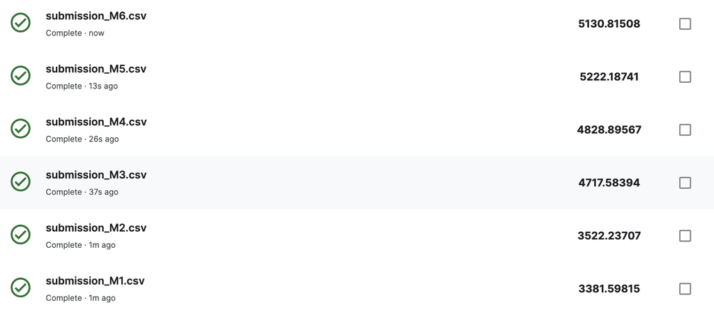

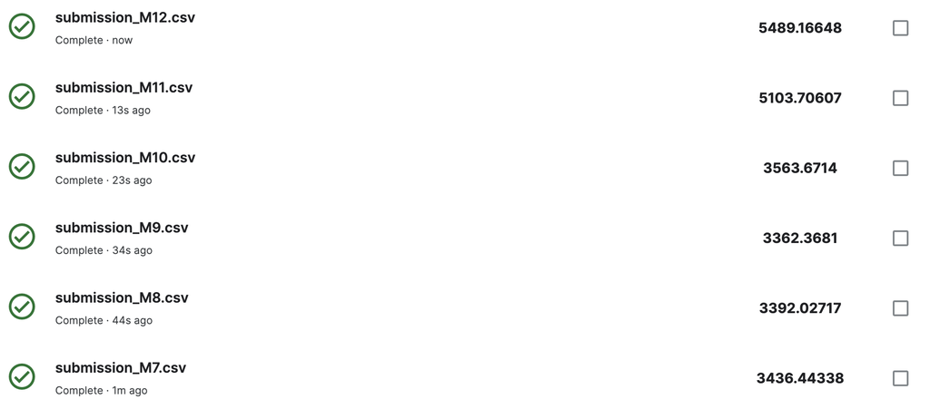

## 6. Non-financial Model

### 6.1 Non-financial Model Construction

In this section, we build a model using non-financial data exclusively. Based on the multicollinearity test conducted in section 4.5 of EDA, days_joined, months_joined and years_joined are analysed as highly correlated.Thus, we only retain days_joined variable in the construction of our non financial variables model as the days_joined variable has greater variability in terms of data compared to the other two.

Hence, the 3 non-financial models constructed are as follows:

Model13: Growth_rate = Profile vars + announcements vars + popular ind + week dummy + ln(asset) Model14: Growth_rate = Profile vars + announcements vars + popular ind + week dummy + ln(asset) + industry FE Model15: Growth_rate = Profile vars + announcements vars + popular ind + week dummy + ln(asset) + industry FE + firm FE

The above mentioned 3 non financial OLS regression models uses the same set of dependent and independent variables. The difference between the models are on the fixed effect levels applied. We added industry level fixed effect in model14 and we added industry and firm level fixed effect in model15. The fixed effects allows for control on the industry and firm level varying features. The formula for the model (**`Mod13_formula`**) is specified to capture the relationship between the growth rate and the non financial variables. Specifically, the formula encompasses profile_info, announcements related data, alongside dummies for each day of the week, and log “atq” as a measure of company size.

```r
# create formula
Mod13_formula <- as.formula("growth_rate ~ is_annouce + red_annouce + no_annoucement + TFF + coleman_liau + flesch + fog_info + num_words + bio_complete + has_url + hashtags_count + has_hashtags + contains_company_name + contains_words + custom_content + days_joined +
pop_ind + is_mon + is_tue + is_wed + is_thu + is_fri + is_sat + log(atq)")

# run regression Model13 : non financial variables
Model13 <- lm(Mod13_formula,data=Train)
summary(Model13)
```

```
Call:
lm(formula = Mod13_formula, data = Train)

Residuals:
     Min       1Q   Median       3Q      Max
-0.03480 -0.00049 -0.00023  0.00014  0.04849

Coefficients: (1 not defined because of singularities)
                            Estimate     Std. Error t value
(Intercept)           -0.00021920305  0.00017936259   -1.22
is_annouce            -0.00019560134  0.00008530193   -2.29
red_annouce            0.00112050881  0.00020386272    5.50
no_annoucement         0.00008874467  0.00003196948    2.78
TFF                   -0.00000000413  0.00000000166   -2.49
coleman_liau           0.00000458147  0.00000118653    3.86
flesch                -0.00000338959  0.00000172042   -1.97
fog_info               0.00000403556  0.00000604250    0.67
num_words              0.00002084353  0.00000235400    8.85
bio_complete           0.00039435380  0.00004529792    8.71
has_url               -0.00010274438  0.00006284697   -1.63
hashtags_count        -0.00000867484  0.00001659062   -0.52
has_hashtags          -0.00007636390  0.00005470784   -1.40
contains_company_name  0.00017272016  0.00004380049    3.94
contains_words        -0.00007420327  0.00005501823   -1.35
custom_content                    NA             NA      NA
days_joined            0.00000000990  0.00000001492    0.66
pop_ind                0.00038361237  0.00003739998   10.26
is_mon                 0.00018728825  0.00006507043    2.88
is_tue                 0.00019129709  0.00006457106    2.96
is_wed                 0.00018295498  0.00006452894    2.84
is_thu                 0.00014317596  0.00006427314    2.23
is_fri                 0.00016852505  0.00006438387    2.62
is_sat                -0.00000809517  0.00007218723   -0.11
log(atq)               0.00001023262  0.00000951659    1.08
                                  Pr(>|t|)
(Intercept)                        0.22169
is_annouce                         0.02186 *
red_annouce                     0.00000004 ***
no_annoucement                     0.00551 **
TFF                                0.01289 *
```

[output cut: 11 more lines]

```
days_joined                        0.50709
pop_ind               < 0.0000000000000002 ***
is_mon                             0.00401 **
is_tue                             0.00306 **
is_wed                             0.00459 **
is_thu                             0.02592 *
is_fri                             0.00887 **
is_sat                             0.91071
log(atq)                           0.28229
---
Signif. codes:  0 '***' 0.001 '**' 0.01 '*' 0.05 '.' 0.1 ' ' 1

Residual standard error: 0.00164 on 12070 degrees of freedom
Multiple R-squared:  0.0305,    Adjusted R-squared:  0.0287
F-statistic: 16.5 on 23 and 12070 DF,  p-value: <0.0000000000000002
```

```r
# run regression Model14 : non financial variables with industry FE
Mod14_formula <- update(Mod13_formula, . ~ . + factor(sic))
Model14 <- lm(Mod14_formula,data=Train)
summary(Model14)
```

```
Call:
lm(formula = Mod14_formula, data = Train)

Residuals:
     Min       1Q   Median       3Q      Max
-0.03636 -0.00036 -0.00007  0.00017  0.04696

Coefficients: (2 not defined because of singularities)
                           Estimate    Std. Error t value             Pr(>|t|)
(Intercept)            0.0014155328  0.0005094192    2.78              0.00547
is_annouce            -0.0002357122  0.0000806056   -2.92              0.00346
red_annouce            0.0012326152  0.0001922320    6.41   0.0000000001488863
no_annoucement         0.0001010130  0.0000302048    3.34              0.00083
TFF                    0.0000003346  0.0000000190   17.61 < 0.0000000000000002
coleman_liau          -0.0000189883  0.0000039731   -4.78   0.0000017810667136
flesch                 0.0000235789  0.0000042154    5.59   0.0000000227392499
fog_info               0.0000205598  0.0000126902    1.62              0.10523
num_words              0.0000128799  0.0000050810    2.53              0.01126
bio_complete           0.0007872563  0.0000829403    9.49 < 0.0000000000000002
has_url               -0.0008243067  0.0003462860   -2.38              0.01731
hashtags_count         0.0001530731  0.0000410969    3.72              0.00020
has_hashtags          -0.0004265401  0.0001467212   -2.91              0.00365
contains_company_name -0.0000696217  0.0000794153   -0.88              0.38068
contains_words        -0.0002898654  0.0001008573   -2.87              0.00406
custom_content                   NA            NA      NA                   NA
days_joined           -0.0000001591  0.0000000333   -4.77   0.0000018279190980
pop_ind                0.0006594267  0.0001350129    4.88   0.0000010520152741
is_mon                 0.0001244445  0.0000616680    2.02              0.04362
is_tue                 0.0000997849  0.0000612495    1.63              0.10331
is_wed                 0.0000921444  0.0000612210    1.51              0.13232
is_thu                 0.0000648783  0.0000609921    1.06              0.28748
is_fri                 0.0000824642  0.0000610611    1.35              0.17687
is_sat                -0.0000116508  0.0000678082   -0.17              0.86358
log(atq)              -0.0000187019  0.0000186719   -1.00              0.31655
factor(sic)1531       -0.0018088162  0.0002294152   -7.88   0.0000000000000034
factor(sic)1623        0.0053867878  0.0003813709   14.12 < 0.0000000000000002
factor(sic)2080       -0.0000623282  0.0001738899   -0.36              0.72002
factor(sic)2300       -0.0004111932  0.0001937816   -2.12              0.03386
factor(sic)2320        0.0005876909  0.0003862939    1.52              0.12820
factor(sic)2510       -0.0008444849  0.0001813372   -4.66   0.0000032431234283
```

[output cut: 133 more lines]

```
factor(sic)7370       ***
factor(sic)7372       ***
factor(sic)7389       **
factor(sic)7900       ***
factor(sic)7990       ***
factor(sic)8700       ***
factor(sic)8721
factor(sic)8731       ***
factor(sic)8742
---
Signif. codes:  0 '***' 0.001 '**' 0.01 '*' 0.05 '.' 0.1 ' ' 1

Residual standard error: 0.00154 on 12010 degrees of freedom
Multiple R-squared:  0.151, Adjusted R-squared:  0.145
F-statistic: 25.8 on 83 and 12010 DF,  p-value: <0.0000000000000002
```

```r
# run regression Model15 : non financial variables with industry FE and firm FE
Mod15_formula <- update(Mod13_formula, . ~ . + factor(gvkey) + factor(sic))
Model15 <- lm(Mod15_formula,data=Train)
summary(Model15)
```

```
Call:
lm(formula = Mod15_formula, data = Train)

Residuals:
     Min       1Q   Median       3Q      Max
-0.03643 -0.00030 -0.00005  0.00015  0.04688

Coefficients: (74 not defined because of singularities)
                          Estimate   Std. Error t value             Pr(>|t|)
(Intercept)            0.023317552  0.001541134   15.13 < 0.0000000000000002
is_annouce            -0.000192510  0.000079809   -2.41              0.01587
red_annouce            0.001280814  0.000189922    6.74  0.00000000001612872
no_annoucement         0.000099030  0.000029923    3.31              0.00094
TFF                    0.000002243  0.000000339    6.63  0.00000000003603695
coleman_liau          -0.000721723  0.000047276  -15.27 < 0.0000000000000002
flesch                -0.000078963  0.000013142   -6.01  0.00000000192785665
fog_info              -0.000390439  0.000070034   -5.57  0.00000002529026682
num_words             -0.000059989  0.000017036   -3.52              0.00043
bio_complete          -0.000663706  0.000374804   -1.77              0.07662
has_url                0.002061997  0.000533477    3.87              0.00011
hashtags_count        -0.006636952  0.000510808  -12.99 < 0.0000000000000002
has_hashtags          -0.019053822  0.002047403   -9.31 < 0.0000000000000002
contains_company_name  0.010898763  0.000839076   12.99 < 0.0000000000000002
contains_words         0.012870867  0.001558975    8.26 < 0.0000000000000002
custom_content                  NA           NA      NA                   NA
days_joined           -0.000001273  0.000000268   -4.75  0.00000207076136962
pop_ind                0.018132570  0.001116313   16.24 < 0.0000000000000002
is_mon                 0.000126092  0.000060937    2.07              0.03855
is_tue                 0.000097643  0.000060518    1.61              0.10667
is_wed                 0.000089931  0.000060489    1.49              0.13711
is_thu                 0.000060310  0.000060260    1.00              0.31693
is_fri                 0.000085149  0.000060332    1.41              0.15817
is_sat                -0.000009291  0.000066920   -0.14              0.88958
log(atq)               0.000018923  0.000039435    0.48              0.63134
factor(gvkey)1447     -0.012746612  0.001458066   -8.74 < 0.0000000000000002
factor(gvkey)1487     -0.014486514  0.001761841   -8.22 < 0.0000000000000002
factor(gvkey)1659     -0.001686738  0.000521755   -3.23              0.00123
factor(gvkey)1878      0.018358733  0.002385217    7.70  0.00000000000001503
factor(gvkey)1919      0.025223671  0.001625435   15.52 < 0.0000000000000002
factor(gvkey)1920     -0.003851960  0.001984444   -1.94              0.05227
```

[output cut: 309 more lines]

```
factor(sic)7370
factor(sic)7372
factor(sic)7389
factor(sic)7900
factor(sic)7990
factor(sic)8700
factor(sic)8721
factor(sic)8731
factor(sic)8742
---
Signif. codes:  0 '***' 0.001 '**' 0.01 '*' 0.05 '.' 0.1 ' ' 1

Residual standard error: 0.00152 on 11994 degrees of freedom
Multiple R-squared:  0.175, Adjusted R-squared:  0.168
F-statistic: 25.7 on 99 and 11994 DF,  p-value: <0.0000000000000002
```

### 6.2 In Sample Evaluation

```r
# predict Train followers growth rate
Train$Pre_rate_13 <- predict(Model13, Train)
Train$Pre_rate_14 <- predict(Model14, Train)
Train$Pre_rate_15 <- predict(Model15, Train)

# compute Train followers using predicted growth rate
Train$Followers_M13 <- (1+Train$Pre_rate_13)*Train$followers_lag
Train$Followers_M14 <- (1+Train$Pre_rate_14)*Train$followers_lag
Train$Followers_M15 <- (1+Train$Pre_rate_15)*Train$followers_lag


## compute In Sample accuracy
rmse <- function(v1, v2) {
  sqrt(mean((v1 - v2)^2, na.rm = T))
}

rmse <- c(rmse(Train$followers,Train$Followers_M13),
          rmse(Train$followers,Train$Followers_M14),
          rmse(Train$followers,Train$Followers_M15))

# retrieve RMSE for all the five models
names(rmse) <- c("Model13", "Model14", "Model15")
rmse
```

```
Model13 Model14 Model15
  984.1   901.4   904.5
```

### 6.3 Prediction of Test Followers

Using the same calculation procedures in financial model part, we retrieve the last day’s number of followers from the training data for each company (**`gvkey`**). It sorts the data by **`gvkey`** and date in descending order to obtain the latest date’s followers. Afterward, it filters out specific **`gvkey`** values.

Subsequently, it joins the last day’s followers with the testing data using a full join based on **`gvkey`** and **`date`**. This ensures that each company’s last day followers from the training data are paired with corresponding rows in the testing data.

```r
# use the function for 3 non financial predicted rates
Test13 <- predict_test(last_day_followers, Test, Model13)
Test14 <- predict_test(last_day_followers, Test, Model14)
Test15 <- predict_test(last_day_followers, Test, Model15)
```

```r
# merge the six companies with other companies 6492
Test_submission13 <- Test13 %>% select(gvkey, date, followers, ID)
Test_submission13 <- rbind(Test_submission13, Test_6)

# final submission data should return 6403 observations
Test_submission13 <- Test_submission13 %>% filter(date>=20170701)
Test_submission13$followers <- round(Test_submission13$followers)
Followers_submisson_M13 <- Test_submission13 %>% select(ID, followers)

# merge the six companies with other companies 6492
Test_submission14 <- Test14 %>% select(gvkey, date, followers, ID)
Test_submission14 <- rbind(Test_submission14, Test_6)

# final submission data should return 6403 observations
Test_submission14 <- Test_submission14 %>% filter(date>=20170701)
Test_submission14$followers <- round(Test_submission14$followers)
Followers_submisson_M14 <- Test_submission14 %>% select(ID, followers)

# merge the six companies with other companies 6492
Test_submission15 <- Test15 %>% select(gvkey, date, followers, ID)
Test_submission15 <- rbind(Test_submission15, Test_6)

# final submission data should return 6403 observations
Test_submission15 <- Test_submission15 %>% filter(date>=20170701)
Test_submission15$followers <- round(Test_submission15$followers)
Followers_submisson_M15 <- Test_submission15 %>% select(ID, followers)

# save the sample of submission
write.csv(Followers_submisson_M13, "submission_M13.csv", row.names = FALSE)
write.csv(Followers_submisson_M14, "submission_M14.csv", row.names = FALSE)
write.csv(Followers_submisson_M15, "submission_M15.csv", row.names = FALSE)
```

### 6.4 Out of Sample Evaluation

The submission CSV files for the 3 models have been exported, and we still find that model 13 for the non-financial model gives better score. This is the model that gives us the best result for now, which makes us rank 3*rd* on the leaderboard temporarily.

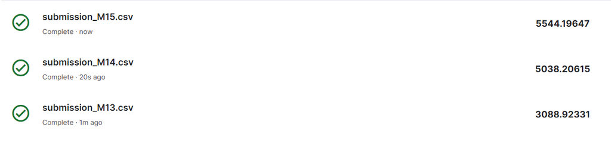

## 7. Combined Model

### 7.1 Combined Model Construction

In this section, we combined all variables (stock price, financial ratios, announcement and profile variables) to construct a regression model for prediction of Twitter followers growth rate.

The 5 combined model constructed are as follows:

combined_Model1 : The response variable “growth_rate” is regressed against various financial ratios, stock price, announcements, and profile variables. The log-transformed value of `atq` is included as a variable to account for varying company size.

combined_Model2 : The response variable “growth_rate” is regressed against the lagged values of financial ratios and stock price variables. The model aims to predict `growth_rate` based on the previous period’s values of these variables, along with the announcement and profile variables.

combined_Model3 : The removal of variables with potentially high multicollinearity is performed in this model. Specifically, `opmad`, `npm`, `quick_ratio`, `cash_ratio`, `ps`, `ptb`, and `roce` have been excluded from the formula. The removal of highly correlated variables is done with the expectation to reduce error term in the model thus improving accuracy.

```r
#create formula

#combined_Mod1 : financial ratios, stock price , announcement, profile variables combined
Mod16_formula<- as.formula("growth_rate ~ p_daily_change + volatile + p_daily_change_lag + volatile_lag + bm + pe_exi + ps + pcf + dpr + npm + opmbd + opmad + gpm + roa + roe + roce + debt_at + de_ratio + intcov + cash_ratio + quick_ratio + curr_ratio + inv_turn + at_turn + debt_assets + ptb + rect_turn + sale_nwc + divyield + is_annouce + red_annouce + no_annoucement + TFF + coleman_liau + flesch + fog_info + num_words + bio_complete + has_url + hashtags_count + has_hashtags + contains_company_name + contains_words + custom_content + days_joined + pop_ind + is_mon + is_tue + is_wed + is_thu + is_fri + is_sat + log(atq)")

#combined_Mod2 : financial ratios (lag), stock price (lag), announcement, profile variables combined
Mod17_formula <- as.formula("growth_rate ~ bm_lag + pe_exi_lag + ps_lag + pcf_lag + dpr_lag + npm_lag + opmbd_lag + opmad_lag + gpm_lag + roa_lag +roe_lag + roce_lag + debt_at_lag + de_ratio_lag + intcov_lag + cash_ratio_lag + quick_ratio_lag + curr_ratio_lag + inv_turn_lag + at_turn_lag + debt_assets_lag + ptb_lag + rect_turn_lag + sale_nwc_lag + divyield_lag + p_daily_change_lag + volatile_lag + is_annouce + red_annouce + no_annoucement + TFF + coleman_liau + flesch + fog_info + num_words + bio_complete + has_url + hashtags_count + has_hashtags + contains_company_name + contains_words + custom_content + days_joined + pop_ind + is_mon + is_tue + is_wed + is_thu + is_fri + is_sat + log(atq)")

#combined_Mod3 : remove variables with high multicollinearity (remove opmad,npm,quick ratio,cash ratio,ps,ptb,roce)
Mod18_formula <- as.formula("growth_rate ~ p_daily_change + volatile + p_daily_change_lag + volatile_lag + bm + pe_exi + pcf + dpr + opmbd + gpm + roa + roe + debt_at + de_ratio + intcov + curr_ratio + inv_turn + at_turn + debt_assets + rect_turn + sale_nwc + divyield + is_annouce + red_annouce + no_annoucement + TFF + coleman_liau + flesch + fog_info + num_words + bio_complete + has_url + hashtags_count + has_hashtags + contains_company_name + contains_words + custom_content + days_joined + pop_ind + is_mon + is_tue + is_wed + is_thu + is_fri + is_sat + log(atq)")
```

Using the above model formulaes created, run regression for the 5 combined model stated.

```r
#run regression for combined_Mod1
Model16 <- lm(Mod16_formula, data = Train)
summary(Model16)
```

```
Call:
lm(formula = Mod16_formula, data = Train)

Residuals:
     Min       1Q   Median       3Q      Max
-0.03526 -0.00048 -0.00017  0.00020  0.04803

Coefficients: (1 not defined because of singularities)
                            Estimate     Std. Error t value
(Intercept)            0.00020793746  0.00026445021    0.79
p_daily_change        -0.00002522293  0.00060009324   -0.04
volatile               0.00247535049  0.00106088981    2.33
p_daily_change_lag    -0.00032853957  0.00061487197   -0.53
volatile_lag           0.00174278093  0.00103666595    1.68
bm                     0.00025510608  0.00006750935    3.78
pe_exi                 0.00000002346  0.00000009372    0.25
ps                    -0.00004114538  0.00001169001   -3.52
pcf                    0.00000154201  0.00000078062    1.98
dpr                   -0.00000011590  0.00000768983   -0.02
npm                    0.00234420129  0.00051178821    4.58
opmbd                  0.00188190375  0.00038674657    4.87
opmad                 -0.00136445421  0.00052677447   -2.59
gpm                    0.00021548906  0.00013478987    1.60
roa                   -0.00392121658  0.00052644837   -7.45
roe                   -0.00002327457  0.00000951743   -2.45
roce                   0.00078267317  0.00030914492    2.53
debt_at                0.00150594732  0.00018370550    8.20
de_ratio              -0.00000005511  0.00000095179   -0.06
intcov                -0.00000001513  0.00000003624   -0.42
cash_ratio            -0.00008520928  0.00005958915   -1.43
quick_ratio            0.00005801073  0.00006733604    0.86
curr_ratio            -0.00006194917  0.00004313088   -1.44
inv_turn               0.00000286856  0.00000023405   12.26
at_turn                0.00020056134  0.00005444694    3.68
debt_assets           -0.00130184083  0.00018952636   -6.87
ptb                    0.00000018281  0.00000008136    2.25
rect_turn             -0.00000336373  0.00000108611   -3.10
sale_nwc              -0.00000015026  0.00000007426   -2.02
divyield              -0.01118267442  0.00137924882   -8.11
is_annouce            -0.00019667670  0.00008373633   -2.35
```

[output cut: 69 more lines]

```
days_joined            0.00008408266192469 ***
pop_ind               < 0.0000000000000002 ***
is_mon                             0.00600 **
is_tue                             0.00783 **
is_wed                             0.01035 *
is_thu                             0.05850 .
is_fri                             0.02521 *
is_sat                             0.85286
log(atq)                           0.00019 ***
---
Signif. codes:  0 '***' 0.001 '**' 0.01 '*' 0.05 '.' 0.1 ' ' 1

Residual standard error: 0.00161 on 12041 degrees of freedom
Multiple R-squared:  0.0756,    Adjusted R-squared:  0.0716
F-statistic: 18.9 on 52 and 12041 DF,  p-value: <0.0000000000000002
```

```r
#run regression for combined_Mod2
Model17 <- lm(Mod17_formula, data = Train)
summary(Model17)
```

```
Call:
lm(formula = Mod17_formula, data = Train)

Residuals:
     Min       1Q   Median       3Q      Max
-0.03520 -0.00048 -0.00017  0.00020  0.04811

Coefficients: (1 not defined because of singularities)
                            Estimate     Std. Error t value
(Intercept)            0.00051439649  0.00026533476    1.94
bm_lag                 0.00026394897  0.00006911299    3.82
pe_exi_lag             0.00000004184  0.00000008079    0.52
ps_lag                -0.00003972028  0.00001225039   -3.24
pcf_lag                0.00000031516  0.00000077891    0.40
dpr_lag                0.00000687191  0.00001216877    0.56
npm_lag                0.00183253316  0.00048765573    3.76
opmbd_lag              0.00202915920  0.00040140954    5.06
opmad_lag             -0.00108807697  0.00052385355   -2.08
gpm_lag                0.00024270584  0.00013609847    1.78
roa_lag               -0.00450270763  0.00054230234   -8.30
roe_lag               -0.00002388606  0.00000950580   -2.51
roce_lag               0.00108917746  0.00031247049    3.49
debt_at_lag            0.00177928024  0.00018536106    9.60
de_ratio_lag          -0.00000028546  0.00000095539   -0.30
intcov_lag            -0.00000001741  0.00000003325   -0.52
cash_ratio_lag        -0.00009102956  0.00005868861   -1.55
quick_ratio_lag        0.00004212293  0.00006835005    0.62
curr_ratio_lag        -0.00006541045  0.00004548727   -1.44
inv_turn_lag           0.00000259316  0.00000021824   11.88
at_turn_lag            0.00022983757  0.00005742250    4.00
debt_assets_lag       -0.00156634681  0.00019189363   -8.16
ptb_lag                0.00000018713  0.00000008080    2.32
rect_turn_lag         -0.00000320898  0.00000111798   -2.87
sale_nwc_lag          -0.00000015532  0.00000008770   -1.77
divyield_lag          -0.01283288083  0.00157544984   -8.15
p_daily_change_lag    -0.00029629126  0.00059138107   -0.50
volatile_lag           0.00333887832  0.00083980693    3.98
is_annouce            -0.00019989662  0.00008378558   -2.39
red_annouce            0.00113796781  0.00019963954    5.70
no_annoucement         0.00008126963  0.00003139702    2.59
```

[output cut: 65 more lines]

```
days_joined            0.00004729893273680 ***
pop_ind               < 0.0000000000000002 ***
is_mon                             0.00787 **
is_tue                             0.00899 **
is_wed                             0.01265 *
is_thu                             0.06984 .
is_fri                             0.03000 *
is_sat                             0.80324
log(atq)                           0.00015 ***
---
Signif. codes:  0 '***' 0.001 '**' 0.01 '*' 0.05 '.' 0.1 ' ' 1

Residual standard error: 0.00161 on 12043 degrees of freedom
Multiple R-squared:  0.0745,    Adjusted R-squared:  0.0707
F-statistic: 19.4 on 50 and 12043 DF,  p-value: <0.0000000000000002
```

```r
#run regression for combined_Mod3
Model18 <- lm(Mod18_formula, data = Train)
summary(Model18)
```

```
Call:
lm(formula = Mod18_formula, data = Train)

Residuals:
     Min       1Q   Median       3Q      Max
-0.03509 -0.00048 -0.00017  0.00020  0.04820

Coefficients: (1 not defined because of singularities)
                            Estimate     Std. Error t value
(Intercept)           -0.00011080225  0.00023740149   -0.47
p_daily_change         0.00000527934  0.00060105927    0.01
volatile               0.00198569874  0.00106112894    1.87
p_daily_change_lag    -0.00030670029  0.00061617184   -0.50
volatile_lag           0.00141681596  0.00103791860    1.37
bm                     0.00026973449  0.00006643863    4.06
pe_exi                 0.00000007241  0.00000008792    0.82
pcf                    0.00000036995  0.00000074675    0.50
dpr                   -0.00000779045  0.00000753906   -1.03
opmbd                  0.00260451033  0.00023093631   11.28
gpm                   -0.00004532516  0.00011519654   -0.39
roa                   -0.00311648251  0.00026750824  -11.65
roe                   -0.00000247373  0.00000189856   -1.30
debt_at                0.00110777115  0.00014140678    7.83
de_ratio              -0.00000037273  0.00000093484   -0.40
intcov                -0.00000002817  0.00000003583   -0.79
curr_ratio            -0.00001233791  0.00001907166   -0.65
inv_turn               0.00000291526  0.00000023072   12.64
at_turn                0.00036050288  0.00004906440    7.35
debt_assets           -0.00088325548  0.00013197010   -6.69
rect_turn             -0.00000309727  0.00000095279   -3.25
sale_nwc              -0.00000014936  0.00000007361   -2.03
divyield              -0.00942861285  0.00132244288   -7.13
is_annouce            -0.00019933983  0.00008382843   -2.38
red_annouce            0.00112826950  0.00019991295    5.64
no_annoucement         0.00007280304  0.00003145039    2.31
TFF                   -0.00000000264  0.00000000185   -1.43
coleman_liau          -0.00000234946  0.00000140297   -1.67
flesch                 0.00000586247  0.00000208024    2.82
fog_info               0.00001676780  0.00000656176    2.56
num_words              0.00001523880  0.00000275904    5.52
```

[output cut: 55 more lines]

```
days_joined             0.0000077019684285 ***
pop_ind               < 0.0000000000000002 ***
is_mon                             0.00593 **
is_tue                             0.00662 **
is_wed                             0.00890 **
is_thu                             0.05110 .
is_fri                             0.02142 *
is_sat                             0.86063
log(atq)                           0.00016 ***
---
Signif. codes:  0 '***' 0.001 '**' 0.01 '*' 0.05 '.' 0.1 ' ' 1

Residual standard error: 0.00161 on 12048 degrees of freedom
Multiple R-squared:  0.0709,    Adjusted R-squared:  0.0674
F-statistic: 20.4 on 45 and 12048 DF,  p-value: <0.0000000000000002
```

```r
#run combined_Mod1 + industry FE + firm FE
Mod19_formula <- update(Mod17_formula, .~. + factor(gvkey) + factor(sic))
Model19 <- lm(Mod19_formula, data = Train)
summary(Model19)
```

```
Call:
lm(formula = Mod19_formula, data = Train)

Residuals:
     Min       1Q   Median       3Q      Max
-0.03654 -0.00030 -0.00005  0.00017  0.04678

Coefficients: (74 not defined because of singularities)
                           Estimate    Std. Error t value             Pr(>|t|)
(Intercept)            0.0246521104  0.0033743085    7.31   0.0000000000002931
bm_lag                 0.0005367015  0.0003801188    1.41              0.15800
pe_exi_lag             0.0000000603  0.0000001158    0.52              0.60232
ps_lag                -0.0000113557  0.0000306973   -0.37              0.71145
pcf_lag               -0.0000008644  0.0000009338   -0.93              0.35466
dpr_lag               -0.0000125554  0.0000199984   -0.63              0.53013
npm_lag                0.0018510680  0.0010312893    1.79              0.07269
opmbd_lag             -0.0073305362  0.0021972790   -3.34              0.00085
opmad_lag              0.0043397142  0.0017177552    2.53              0.01154
gpm_lag               -0.0003873199  0.0008517616   -0.45              0.64931
roa_lag               -0.0013882278  0.0026054281   -0.53              0.59417
roe_lag               -0.0000126470  0.0000112935   -1.12              0.26280
roce_lag               0.0001942063  0.0009570399    0.20              0.83920
debt_at_lag           -0.0016819652  0.0011095219   -1.52              0.12956
de_ratio_lag          -0.0000002465  0.0000009421   -0.26              0.79363
intcov_lag             0.0000000138  0.0000000493    0.28              0.77965
cash_ratio_lag        -0.0005622834  0.0002362854   -2.38              0.01734
quick_ratio_lag        0.0002659181  0.0004755763    0.56              0.57607
curr_ratio_lag         0.0003774921  0.0003903897    0.97              0.33358
inv_turn_lag           0.0000004908  0.0000003759    1.31              0.19173
at_turn_lag           -0.0002867298  0.0004109635   -0.70              0.48538
debt_assets_lag        0.0020572477  0.0009934115    2.07              0.03839
ptb_lag                0.0000001002  0.0000000921    1.09              0.27646
rect_turn_lag          0.0000030501  0.0000045158    0.68              0.49942
sale_nwc_lag           0.0000000560  0.0000001085    0.52              0.60573
divyield_lag           0.0058275359  0.0055363117    1.05              0.29254
p_daily_change_lag    -0.0002683089  0.0005613108   -0.48              0.63266
volatile_lag           0.0015794959  0.0009051635    1.74              0.08101
is_annouce            -0.0001926855  0.0000798103   -2.41              0.01578
red_annouce            0.0012967761  0.0001899318    6.83   0.0000000000090528
no_annoucement         0.0001009191  0.0000299181    3.37              0.00075
```

[output cut: 363 more lines]

```
factor(sic)7370
factor(sic)7372
factor(sic)7389
factor(sic)7900
factor(sic)7990
factor(sic)8700
factor(sic)8721
factor(sic)8731
factor(sic)8742
---
Signif. codes:  0 '***' 0.001 '**' 0.01 '*' 0.05 '.' 0.1 ' ' 1

Residual standard error: 0.00152 on 11967 degrees of freedom
Multiple R-squared:  0.178, Adjusted R-squared:  0.17
F-statistic: 20.6 on 126 and 11967 DF,  p-value: <0.0000000000000002
```

```r
#run combined_Mod2 + industry FE + firm FE
Mod20_formula <- update(Mod18_formula, .~. + factor(gvkey) + factor(sic))
Model20 <- lm(Mod20_formula, data = Train)
summary(Model20)
```

```
Call:
lm(formula = Mod20_formula, data = Train)

Residuals:
     Min       1Q   Median       3Q      Max
-0.03674 -0.00031 -0.00005  0.00017  0.04657

Coefficients: (74 not defined because of singularities)
                            Estimate     Std. Error t value
(Intercept)            0.02271722366  0.00223662589   10.16
p_daily_change         0.00032995147  0.00058555494    0.56
volatile               0.00136536005  0.00105085487    1.30
p_daily_change_lag    -0.00029662020  0.00058236933   -0.51
volatile_lag           0.00098725739  0.00101883107    0.97
bm                     0.00128665664  0.00032180846    4.00
pe_exi                 0.00000003715  0.00000011067    0.34
pcf                   -0.00000029235  0.00000082080   -0.36
dpr                    0.00000542895  0.00000878047    0.62
opmbd                 -0.00165826639  0.00092005716   -1.80
gpm                   -0.00135443210  0.00076855361   -1.76
roa                   -0.00025883881  0.00130255621   -0.20
roe                   -0.00000000589  0.00000212081    0.00
debt_at               -0.00301863217  0.00096036379   -3.14
de_ratio               0.00000003599  0.00000093129    0.04
intcov                 0.00000004241  0.00000004539    0.93
curr_ratio             0.00035129686  0.00010058337    3.49
inv_turn               0.00000051287  0.00000041046    1.25
at_turn               -0.00017765802  0.00022467133   -0.79
debt_assets            0.00287305170  0.00072602081    3.96
rect_turn              0.00000067494  0.00000376475    0.18
sale_nwc               0.00000009701  0.00000009768    0.99
divyield               0.00107736431  0.00358503754    0.30
is_annouce            -0.00018784357  0.00007979848   -2.35
red_annouce            0.00129688407  0.00018985309    6.83
no_annoucement         0.00009505939  0.00002993178    3.18
TFF                    0.00000196987  0.00000040439    4.87
coleman_liau          -0.00074638805  0.00006714274  -11.12
flesch                -0.00008750096  0.00001840792   -4.75
fog_info              -0.00041787258  0.00007988363   -5.23
num_words             -0.00005749427  0.00003165634   -1.82
```

[output cut: 353 more lines]

```
factor(sic)7370                         NA
factor(sic)7372                         NA
factor(sic)7389                         NA
factor(sic)7900                         NA
factor(sic)7990                         NA
factor(sic)8700                         NA
factor(sic)8721                         NA
factor(sic)8731                         NA
factor(sic)8742                         NA
---
Signif. codes:  0 '***' 0.001 '**' 0.01 '*' 0.05 '.' 0.1 ' ' 1

Residual standard error: 0.00152 on 11972 degrees of freedom
Multiple R-squared:  0.178, Adjusted R-squared:  0.17
F-statistic: 21.5 on 121 and 11972 DF,  p-value: <0.0000000000000002
```

### 7.2 In Sample Evaluation

We then predict the growth rate and the number of followers using the fitted linear regression models (`combined_Mod1` to `combined_Mod5`). It then computes and prints the root mean squared error (RMSE) between the actual and predicted followers for each model, which can be used to evaluate the in-sample predictive accuracy of the models.

```r
#predict growth rate using Training data
Train$Pre_rate_16 <- predict(Model16, Train)
Train$Pre_rate_17 <- predict(Model17, Train)
Train$Pre_rate_18 <- predict(Model18, Train)
Train$Pre_rate_19 <- predict(Model19, Train)
Train$Pre_rate_20 <- predict(Model20, Train)
#compute predicted followers using predicted growth rate
Train$Followers_M16 <- (1+Train$Pre_rate_16)*Train$followers_lag
Train$Followers_M17 <- (1+Train$Pre_rate_17)*Train$followers_lag
Train$Followers_M18 <- (1+Train$Pre_rate_18)*Train$followers_lag
Train$Followers_M19 <- (1+Train$Pre_rate_19)*Train$followers_lag
Train$Followers_M20 <- (1+Train$Pre_rate_20)*Train$followers_lag

#rmse formulae
rmse <- function(v1, v2) {
  sqrt(mean((v1 - v2)^2, na.rm = T))
}

#compute rmse to check in sample accuracy
rmse <- c(rmse(Train$followers,Train$Followers_M16),
          rmse(Train$followers,Train$Followers_M17),
          rmse(Train$followers,Train$Followers_M18),
          rmse(Train$followers,Train$Followers_M19),
          rmse(Train$followers,Train$Followers_M20))

#list down the rmse for all 5 combined models
names(rmse) <- c("Model16", "Model17", "Model18", "Model19", "Model20")
rmse
```

```
Model16 Model17 Model18 Model19 Model20
  917.2   918.7   918.9   900.4   896.0
```

### 7.3 Prediction of Test Followers

```r
Test16 <- predict_test(last_day_followers, Test, Model16)
Test17 <- predict_test(last_day_followers, Test, Model17)
Test18 <- predict_test(last_day_followers, Test, Model18)
Test19 <- predict_test(last_day_followers, Test, Model19)
Test20 <- predict_test(last_day_followers, Test, Model20)
```

We merge the original **`Test`** dataset with the derived **`Test_6`** dataset containing calculated follower counts for the specified companies.

Following the merge, the dataset is filtered to retain only observations from 1 July 2017 onwards. Subsequently, we round follower counts and create a subset of the dataset containing only the **`ID`** and **`followers`** columns.

Finally, we saved it as “submission_MXX.csv”. XX denotes the submission for a particular model, for e.g. the submission for Model5 out of sample prediction will be saved as “submission_M5.csv”

```r
# merge the six companies with other companies 6492
Test_submission16 <- Test16 %>% select(gvkey, date, followers, ID)
Test_submission16 <- rbind(Test_submission16, Test_6)
Test_submission16 <- Test_submission16 %>% filter(date>=20170701)
Test_submission16$followers <- round(Test_submission16$followers)
Followers_submisson_M16 <- Test_submission16 %>% select(ID, followers)

# merge the six companies with other companies 6492
Test_submission17 <- Test17 %>% select(gvkey, date, followers, ID)
Test_submission17 <- rbind(Test_submission17, Test_6)
Test_submission17 <- Test_submission17 %>% filter(date>=20170701)
Test_submission17$followers <- round(Test_submission17$followers)
Followers_submisson_M17 <- Test_submission17 %>% select(ID, followers)

# merge the six companies with other companies 6492
Test_submission18 <- Test18 %>% select(gvkey, date, followers, ID)
Test_submission18 <- rbind(Test_submission18, Test_6)
Test_submission18 <- Test_submission18 %>% filter(date>=20170701)
Test_submission18$followers <- round(Test_submission18$followers)
Followers_submisson_M18 <- Test_submission18 %>% select(ID, followers)

# merge the six companies with other companies 6492
Test_submission19 <- Test19 %>% select(gvkey, date, followers, ID)
Test_submission19 <- rbind(Test_submission19, Test_6)
Test_submission19 <- Test_submission19 %>% filter(date>=20170701)
Test_submission19$followers <- round(Test_submission19$followers)
Followers_submisson_M19 <- Test_submission19 %>% select(ID, followers)

# merge the six companies with other companies 6492
Test_submission20 <- Test20 %>% select(gvkey, date, followers, ID)
Test_submission20 <- rbind(Test_submission20, Test_6)
Test_submission20 <- Test_submission20 %>% filter(date>=20170701)
Test_submission20$followers <- round(Test_submission20$followers)
Followers_submisson_M20 <- Test_submission20 %>% select(ID, followers)

# save the sample of submission
write.csv(Followers_submisson_M16, "submission_M16.csv", row.names = FALSE)
write.csv(Followers_submisson_M17, "submission_M17.csv", row.names = FALSE)
write.csv(Followers_submisson_M18, "submission_M18.csv", row.names = FALSE)
write.csv(Followers_submisson_M19, "submission_M19.csv", row.names = FALSE)
write.csv(Followers_submisson_M20, "submission_M20.csv", row.names = FALSE)
```

### 7.4 Out of Sample Evaluation

Results for combined_model

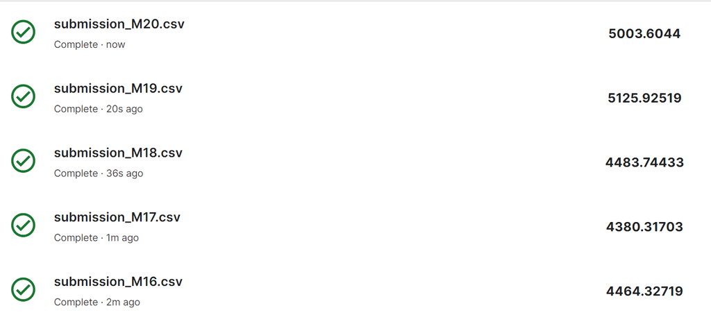

## 8. LASSO

### 8.1 Model Selection for LASSO, XGBoost and Random Forest

The model we have selected for performing LASSO (regularisation), XGBoost and Random Forest (Ensembling) is as follows:

1. ML_Mod21 : stock price and financial ratios model
2. ML_Mod22 : stock price (lag), financial ratios (lag) model
3. ML_Mod23 : announcement and profile variables model
4. ML_Mod24 : financial ratios, stock price , announcement, profile variables combined
5. ML_Mod25 : financial ratios (lag), stock price (lag), announcement, profile variables combined

```r
#-------------------mutate log(at),factor(gvkey),factor(sic)-------------------------------#

#mutate log(at) into Train dataset
Train <- Train %>% mutate (log_atq = log(atq), factor_gvkey = factor(gvkey), factor_sic = factor(sic))

#mutate log(at) into Test dataset
Test <- Test %>% mutate (log_atq = log(atq), factor_gvkey = factor(gvkey), factor_sic = factor(sic))

#------------------create formula for LASSO, XGBoost and Random Forest---------------------------#

#ML_Mod21 : stock price and financial ratios model
ML_Mod21_formula <- as.formula("growth_rate ~ bm + pe_exi + ps + pcf + dpr + npm + opmbd + opmad + gpm + roa + roe + roce + debt_at + de_ratio + intcov + cash_ratio + quick_ratio + curr_ratio + inv_turn + at_turn + rect_turn + sale_nwc + divyield + p_daily_change + volatile + pop_ind + is_mon + is_tue + is_wed + is_thu + is_fri + is_sat + log_atq")

#ML_Mod22 : stock price (lag), financial ratios (lag) model
ML_Mod22_formula <- as.formula("growth_rate~bm_lag + pe_exi_lag + ps_lag + pcf_lag + dpr_lag + npm_lag + opmbd_lag + opmad_lag + gpm_lag + roa_lag +roe_lag + roce_lag + debt_at_lag + de_ratio_lag + intcov_lag + cash_ratio_lag + quick_ratio_lag + curr_ratio_lag + inv_turn_lag + at_turn_lag + rect_turn_lag + sale_nwc_lag + divyield_lag + p_daily_change_lag + volatile_lag+pop_ind + is_mon+is_tue + is_wed+is_thu + is_fri+is_sat + log_atq")

#ML_Mod23 : profile variables model
ML_Mod23_formula<- as.formula("growth_rate ~ is_annouce + red_annouce + no_annoucement + TFF + coleman_liau + flesch + fog_info + num_words + bio_complete + has_url + hashtags_count + has_hashtags + contains_company_name + contains_words + custom_content + days_joined + pop_ind + is_mon + is_tue + is_wed + is_thu + is_fri + is_sat + log_atq")

#ML_Mod24 : financial ratios, stock price , announcement, profile variables combined
ML_Mod24_formula <- as.formula("growth_rate ~ p_daily_change + volatile + p_daily_change_lag + volatile_lag + bm + pe_exi + ps + pcf + dpr + npm + opmbd + opmad + gpm + roa + roe + roce + debt_at + de_ratio + intcov + cash_ratio + quick_ratio + curr_ratio + inv_turn + at_turn + debt_assets +
ptb + rect_turn + sale_nwc + divyield + is_annouce + red_annouce + no_annoucement + TFF + coleman_liau + flesch + fog_info + num_words + bio_complete + has_url + hashtags_count +  has_hashtags + contains_company_name + contains_words + custom_content + days_joined + pop_ind + is_mon + is_tue + is_wed + is_thu + is_fri + is_sat + log_atq")

#ML_Mod25 : financial ratios (lag), stock price (lag), announcement, profile variables combined
ML_Mod25_formula <- as.formula("growth_rate ~ bm_lag + pe_exi_lag + ps_lag + pcf_lag + dpr_lag + npm_lag + opmbd_lag + opmad_lag + gpm_lag + roa_lag +roe_lag + roce_lag + debt_at_lag + de_ratio_lag + intcov_lag + cash_ratio_lag + quick_ratio_lag + curr_ratio_lag + inv_turn_lag + at_turn_lag + debt_assets_lag + ptb_lag + rect_turn_lag + sale_nwc_lag + divyield_lag + p_daily_change_lag + volatile_lag + is_annouce + red_annouce + no_annoucement + TFF + coleman_liau + flesch + fog_info + num_words + bio_complete + has_url + hashtags_count + has_hashtags + contains_company_name + contains_words + custom_content + days_joined + pop_ind + is_mon + is_tue + is_wed + is_thu + is_fri + is_sat + log_atq")


# create x-matrics for each model and y-dataframe as input variables for LASSO/XGBoost
x21 <- model.matrix(ML_Mod21_formula, data = Train)[, -1] #remove y = growth rate
x22 <- model.matrix(ML_Mod22_formula, data = Train)[, -1] #remove y = growth rate
x23 <- model.matrix(ML_Mod23_formula, data = Train)[, -1] #remove y = growth rate
x24 <- model.matrix(ML_Mod24_formula, data = Train)[, -1] #remove y = growth rate
x25 <- model.matrix(ML_Mod25_formula, data = Train)[, -1] #remove y = growth rate

y21 <- model.frame(ML_Mod21_formula, data = Train)[ , "growth_rate"]
y22 <- model.frame(ML_Mod22_formula, data = Train)[ , "growth_rate"]
y23 <- model.frame(ML_Mod23_formula, data = Train)[ , "growth_rate"]
y24 <- model.frame(ML_Mod24_formula, data = Train)[ , "growth_rate"]
y25 <- model.frame(ML_Mod25_formula, data = Train)[ , "growth_rate"]

#create Twitter follower growth_rate column for Test data for xvals and yvals
Test <- Test %>%
  mutate(growth_rate = 0)

# create matrices for testing data
xvals21 <- model.matrix(ML_Mod21_formula, data = Test,  na.action = 'na.pass')[, -1]
xvals22 <- model.matrix(ML_Mod22_formula, data = Test,  na.action = 'na.pass')[, -1]
xvals23 <- model.matrix(ML_Mod23_formula, data = Test,  na.action = 'na.pass')[, -1]
xvals24 <- model.matrix(ML_Mod24_formula, data = Test,  na.action = 'na.pass')[, -1]
xvals25 <- model.matrix(ML_Mod25_formula, data = Test,  na.action = 'na.pass')[, -1]

yvals21 <- model.frame(ML_Mod21_formula, data = Test)[ , "growth_rate"]
yvals22 <- model.frame(ML_Mod22_formula, data = Test)[ , "growth_rate"]
yvals23 <- model.frame(ML_Mod23_formula, data = Test)[ , "growth_rate"]
yvals24 <- model.frame(ML_Mod24_formula, data = Test)[ , "growth_rate"]
yvals25 <- model.frame(ML_Mod25_formula, data = Test)[ , "growth_rate"]
```

### 8.2 LASSO Feature Selection

After selecting the 5 models, we employ the Least Absolute Shrinkage and Selection Operator (LASSO) technique to apply regularization. LASSO helps in eliminating less important features by shrinking their coefficients towards zero. This process aids in reducing the error terms within the regression model and prevents overfitting, thereby enhancing the accuracy of predictions.

```r
#--------------------- LASSO Regularisation method for feature selection--------------------#

# using LASSO for feature selection
library(glmnet)

# run cross validation LASSO (regularisation) model
set.seed(2021)
cvfit21 = cv.glmnet(x = x21, y = y21, family = "gaussian", alpha = 1, type.measure = "mse")
cvfit22 = cv.glmnet(x = x22, y = y22, family = "gaussian", alpha = 1, type.measure = "mse")
cvfit23 = cv.glmnet(x = x23, y = y23, family = "gaussian", alpha = 1, type.measure = "mse")
cvfit24 = cv.glmnet(x = x24, y = y24, family = "gaussian", alpha = 1, type.measure = "mse")
cvfit25 = cv.glmnet(x = x25, y = y25, family = "gaussian", alpha = 1, type.measure = "mse")

# lambda for best performance model(min) and most regularised model(1se)
cvfit21$lambda.min
```

```
[1] 0.0000007735
```

```r
cvfit21$lambda.1se
```

```
[1] 0.0001872
```

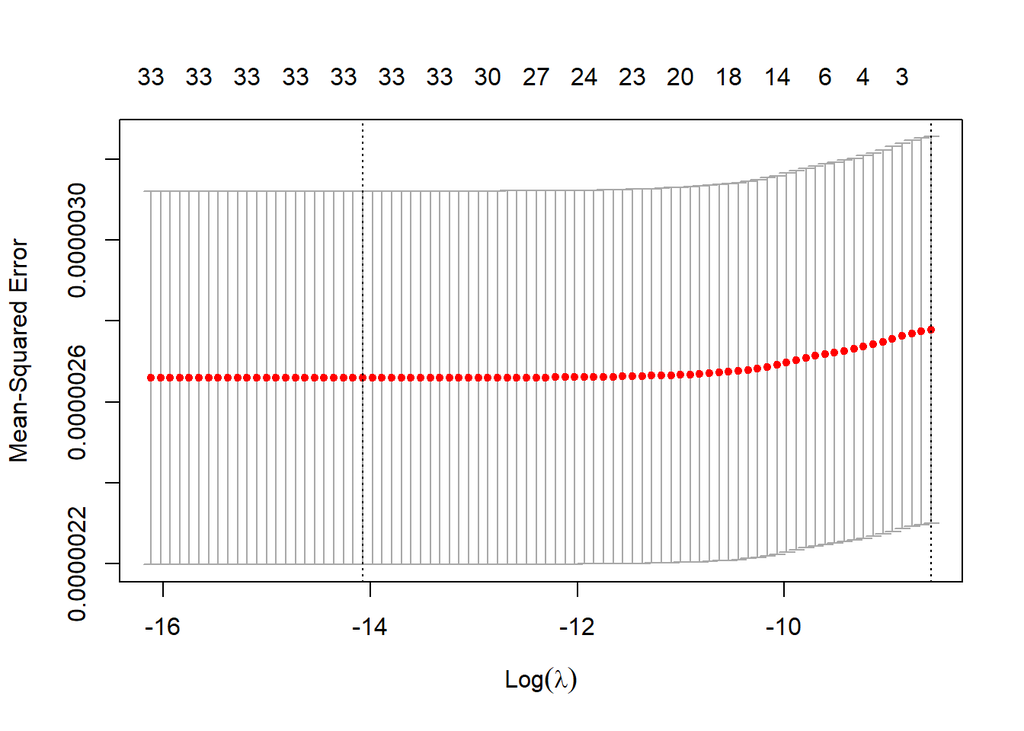

```r
# plot cvfit graph
plot(cvfit21)
```

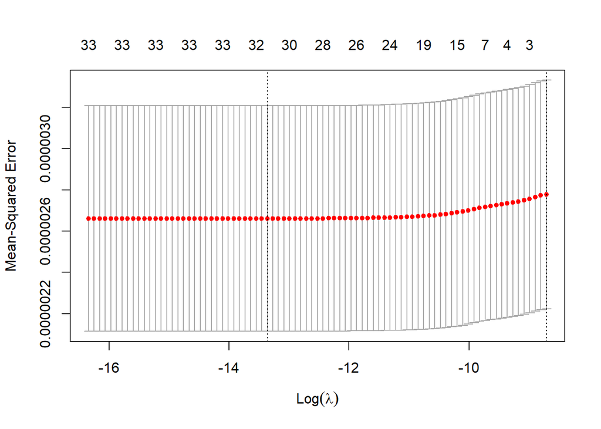

```r
plot(cvfit22)
```

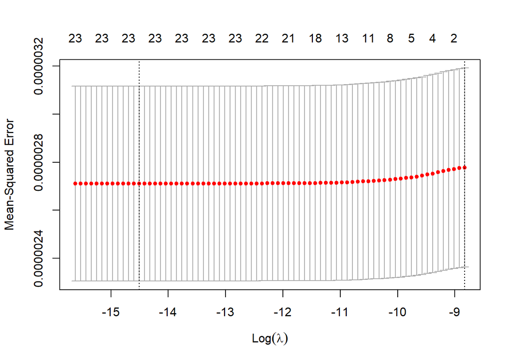

```r
plot(cvfit23)
```

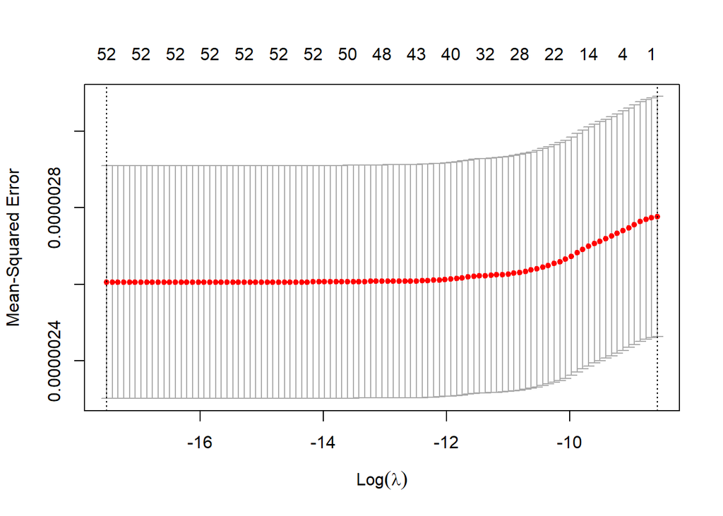

```r
plot(cvfit24)
```

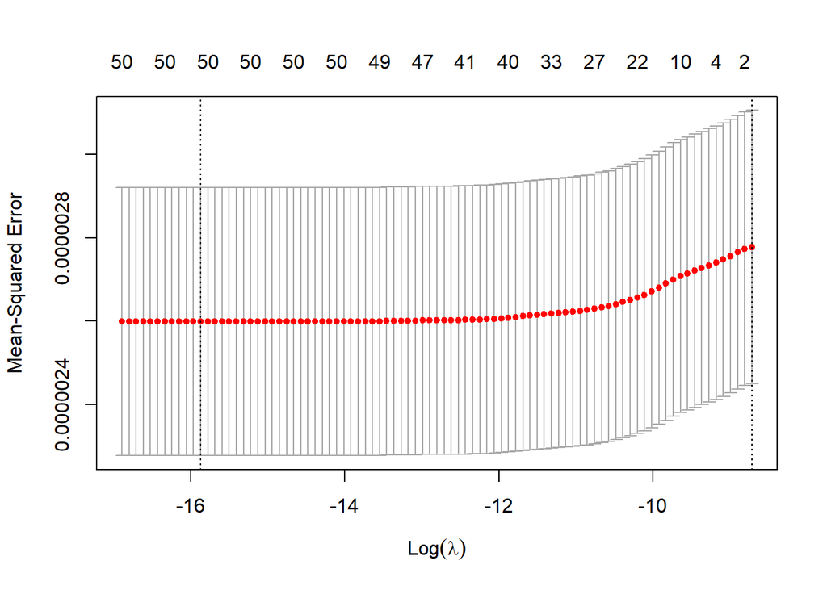

```r
plot(cvfit25)
```

### 8.3 Lamda.min & Lamda.1SE

Based on the cvfit plot for all 5 models, it is interesting to note that that the MSE did not change much even with the removal of features (shrinkage of coefficients) using LASSO. This means that the incremental explanatory power of each feature is minimal. In other words, the features used in our model has explanatory power on its own and when added together as a whole. However, it has no incremental added explanatory power if we were to consider feature by feature addition.

Hence, LASSO lambda.1SE (most regularised) suggest the removal of all features for all 5 model, retaining only the y-intercept. LASSO lambda.1SE regularised technique seems to regard all features as unimportant if the features do not incrementally changes the MSE much.

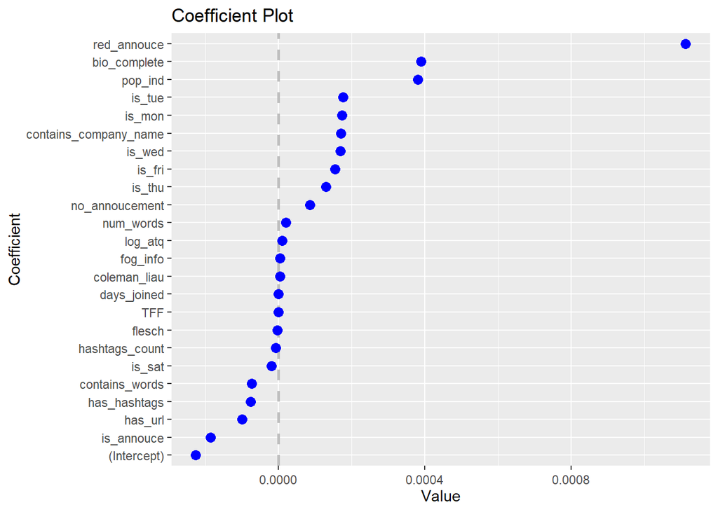

```r
coefplot(cvfit23, lambda = 'lambda.min', sort = 'magnitude')
```

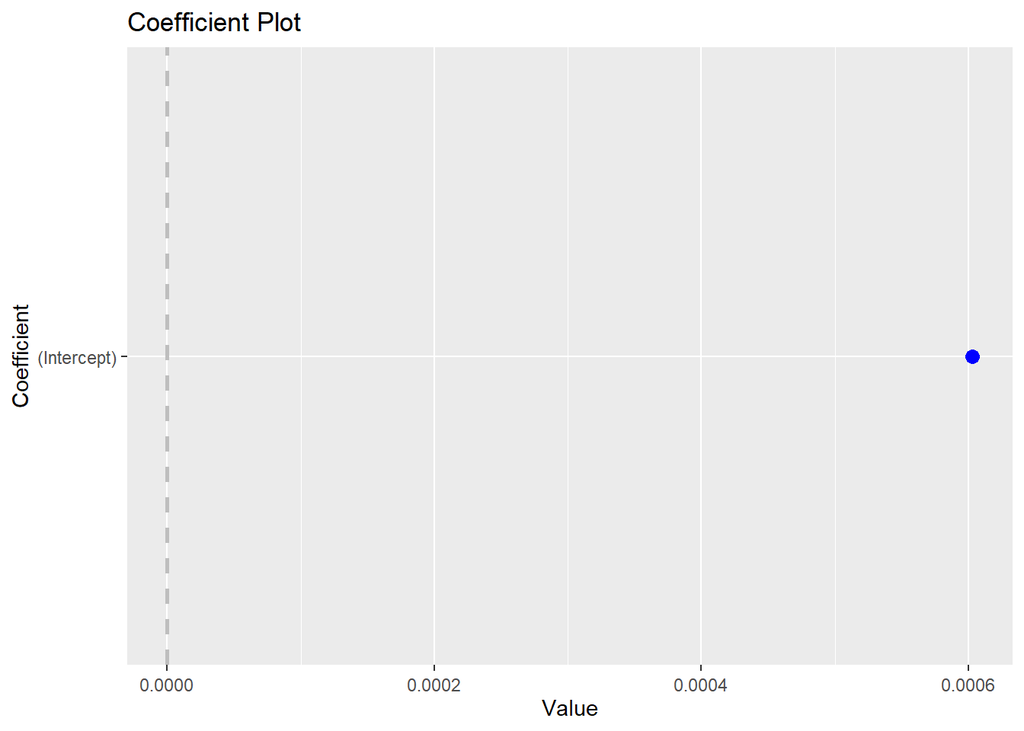

```r
coefplot(cvfit23, lambda = 'lambda.1se', sort = 'magnitude')
```

### 8.4 In Sample Evaluation

Next we performed in sample cross validation prediction using lambda.min and lambda.1SE. We then compute the respective RMSE for the 5 model which regularisation is perform on.

```r
# predict using cvfit and lambda.min of the model (best performance model)
Train$LASSO_rate_M21 <- predict(cvfit21, x21, s = "lambda.min")
Train$LASSO_rate_M22 <- predict(cvfit22, x22, s = "lambda.min")
Train$LASSO_rate_M23 <- predict(cvfit23, x23, s = "lambda.min")
Train$LASSO_rate_M24 <- predict(cvfit24, x24, s = "lambda.min")
Train$LASSO_rate_M25 <- predict(cvfit25, x25, s = "lambda.min")

# predict using cvfit and lambda.1se of the model (most regularised model)
Train$LASSO_rate_SE21 <- predict(cvfit21, x21, s = "lambda.1se")
Train$LASSO_rate_SE22 <- predict(cvfit22, x22, s = "lambda.1se")
Train$LASSO_rate_SE23 <- predict(cvfit23, x23, s = "lambda.1se")
Train$LASSO_rate_SE24 <- predict(cvfit24, x24, s = "lambda.1se")
Train$LASSO_rate_SE25 <- predict(cvfit25, x25, s = "lambda.1se")

# compute predicted followers predicted growth rate obtained from lamda.min (best performance model)
Train$Follower_LA_M21 <- (1+Train$LASSO_rate_M21)*Train$followers_lag
Train$Follower_LA_M22 <- (1+Train$LASSO_rate_M22)*Train$followers_lag
Train$Follower_LA_M23 <- (1+Train$LASSO_rate_M23)*Train$followers_lag
Train$Follower_LA_M24 <- (1+Train$LASSO_rate_M24)*Train$followers_lag
Train$Follower_LA_M25 <- (1+Train$LASSO_rate_M25)*Train$followers_lag

# compute predicted followers predicted growth rate obtained from lamda.1se (most regularised model)
Train$Follower_LA_SE21 <- (1+Train$LASSO_rate_SE21)*Train$followers_lag
Train$Follower_LA_SE22 <- (1+Train$LASSO_rate_SE22)*Train$followers_lag
Train$Follower_LA_SE23 <- (1+Train$LASSO_rate_SE23)*Train$followers_lag
Train$Follower_LA_SE24 <- (1+Train$LASSO_rate_SE24)*Train$followers_lag
Train$Follower_LA_SE25 <- (1+Train$LASSO_rate_SE25)*Train$followers_lag

# compute rmse to measure in sample accuracy
rmse <- function(v1, v2) {
  sqrt(mean((v1 - v2)^2, na.rm = T))
}

RMSE <- c(rmse(Train$followers,Train$Follower_LA_M21),
          rmse(Train$followers,Train$Follower_LA_M22),
          rmse(Train$followers,Train$Follower_LA_M23),
          rmse(Train$followers,Train$Follower_LA_M24),
          rmse(Train$followers,Train$Follower_LA_M25),
          rmse(Train$followers,Train$Follower_LA_SE21),
          rmse(Train$followers,Train$Follower_LA_SE22),
          rmse(Train$followers,Train$Follower_LA_SE23),
          rmse(Train$followers,Train$Follower_LA_SE24),
          rmse(Train$followers,Train$Follower_LA_SE25))

# obtain RMSE for all 6 models derived from best performance (lambda.min)
names(RMSE) <- c("LASSO M21","LASSO M22","LASSO M23","LASSO M24","LASSO M25",
                 "LASSO SE21","LASSO SE22", "LASSO SE23","LASSO SE24","LASSO SE25")
RMSE
```

```
 LASSO M21  LASSO M22  LASSO M23  LASSO M24  LASSO M25 LASSO SE21 LASSO SE22
     937.4      942.3      984.2      917.4      919.2     1016.6     1016.6
LASSO SE23 LASSO SE24 LASSO SE25
    1016.6     1016.6     1016.6
```

Based on the computed RMSE, it is evident that lamda.min returns a lower in sample RMSE (i.e. LASSO M21 - M25) while lamba.1SE returns a higher in sample RMSE. However, lamda.1SE results are not meaningful since it retains only the y-intercept for prediction and we will not use it for out of sample prediction.

```r
# coefficient for best performance model(min)
coef(cvfit24, s = "lambda.min")
```

```
54 x 1 sparse Matrix of class "dgCMatrix"
                                   s1
(Intercept)            0.000138336865
p_daily_change        -0.000026422051
volatile               0.002462704410
p_daily_change_lag    -0.000327037609
volatile_lag           0.001735494962
bm                     0.000255222837
pe_exi                 0.000000027110
ps                    -0.000040819255
pcf                    0.000001511255
dpr                   -0.000000434253
npm                    0.002290632094
opmbd                  0.001842453743
opmad                 -0.001292735824
gpm                    0.000206947368
roa                   -0.003781025218
roe                   -0.000022170621
roce                   0.000712612951
debt_at                0.001462015958
de_ratio              -0.000000059565
intcov                -0.000000016335
cash_ratio            -0.000080964501
quick_ratio            0.000053116889
curr_ratio            -0.000057936231
inv_turn               0.000002861800
at_turn                0.000197917487
debt_assets           -0.001256044370
ptb                    0.000000173423
rect_turn             -0.000003326499
sale_nwc              -0.000000150651
divyield              -0.011188860851
is_annouce            -0.000195190197
red_annouce            0.001126065799
no_annoucement         0.000074872239
TFF                   -0.000000005983
coleman_liau          -0.000003299681
flesch                 0.000009964468
fog_info               0.000028938191
num_words              0.000012299640
bio_complete           0.000537008270
has_url                0.000033548725
hashtags_count         0.000016952352
has_hashtags          -0.000076081276
contains_company_name  .
contains_words        -0.000312255386
custom_content         0.000067014322
days_joined            0.000000066488
pop_ind                0.000363810259
is_mon                 0.000174849656
is_tue                 0.000168050070
is_wed                 0.000161876927
is_thu                 0.000118963180
is_fri                 0.000141098865
is_sat                -0.000013594336
log_atq               -0.000044862462
```

```r
# coefficient for most regularised model(1se)
coef(cvfit24, s = "lambda.1se")
```

```
54 x 1 sparse Matrix of class "dgCMatrix"
                            s1
(Intercept)           0.000603
p_daily_change        .
volatile              .
p_daily_change_lag    .
volatile_lag          .
bm                    .
pe_exi                .
ps                    .
pcf                   .
dpr                   .
npm                   .
opmbd                 .
opmad                 .
gpm                   .
roa                   .
roe                   .
roce                  .
debt_at               .
de_ratio              .
intcov                .
cash_ratio            .
quick_ratio           .
curr_ratio            .
inv_turn              .
at_turn               .
debt_assets           .
ptb                   .
rect_turn             .
sale_nwc              .
divyield              .
is_annouce            .
red_annouce           .
no_annoucement        .
TFF                   .
coleman_liau          .
flesch                .
fog_info              .
num_words             .
bio_complete          .
has_url               .
hashtags_count        .
has_hashtags          .
contains_company_name .
contains_words        .
custom_content        .
days_joined           .
pop_ind               .
is_mon                .
is_tue                .
is_wed                .
is_thu                .
is_fri                .
is_sat                .
log_atq               .
```

### 8.5 Prediction of Test followers

Based on our domain knowledge, it does not makes logical sense to predict Twitter followers growth using y-intercept only. Hence, in our case, lambda.1se is ineffective in aiding us perform feature selection. We will thus rely only on lambda.min to help us perform feature selection for our out of sample prediction. However, it is important to note that because lambda.min typically have a lower in sample bias, it will result in a higher out of sample variance (bias vs variance trade off).

```r
#----------------------- out of sample prediction--------------------------------------------------#

# predict twitter growth rate using lambda min regularised model on Test data
Test21 <- Test
Test21$LASSO_rate_M21 <- predict(cvfit21, xvals21, s = "lambda.min")
Test22 <- Test
Test22$LASSO_rate_M22 <- predict(cvfit22, xvals22, s = "lambda.min")
Test23 <- Test
Test23$LASSO_rate_M23 <- predict(cvfit23, xvals23, s = "lambda.min")
Test24 <- Test
Test24$LASSO_rate_M24 <- predict(cvfit24, xvals24, s = "lambda.min")
Test25 <- Test
Test25$LASSO_rate_M25 <- predict(cvfit25, xvals25, s = "lambda.min")

#merge Train data last day followers to Test data and create 6 Test sets for prediction
Test21 <- full_join(last_day_followers, Test21, by = join_by(gvkey, date))
Test21 <- Test21 %>% arrange(gvkey, date) %>%
  select(-sic.x) %>%
  rename(`sic` = sic.y) %>%
  select(-ID.x) %>%
  rename(`ID` = ID.y)

Test22 <- full_join(last_day_followers, Test22, by = join_by(gvkey, date))
Test22 <- Test22 %>% arrange(gvkey, date) %>%
  select(-sic.x) %>%
  rename(`sic` = sic.y) %>%
  select(-ID.x) %>%
  rename(`ID` = ID.y)

Test23 <- full_join(last_day_followers, Test23, by = join_by(gvkey, date))
Test23 <- Test23 %>% arrange(gvkey, date) %>%
  select(-sic.x) %>%
  rename(`sic` = sic.y) %>%
  select(-ID.x) %>%
  rename(`ID` = ID.y)

Test24 <- full_join(last_day_followers, Test24, by = join_by(gvkey, date))
Test24 <- Test24 %>% arrange(gvkey, date) %>%
  select(-sic.x) %>%
  rename(`sic` = sic.y) %>%
  select(-ID.x) %>%
  rename(`ID` = ID.y)

Test25 <- full_join(last_day_followers, Test25, by = join_by(gvkey, date))
Test25 <- Test25 %>% arrange(gvkey, date) %>%
  select(-sic.x) %>%
  rename(`sic` = sic.y) %>%
  select(-ID.x) %>%
  rename(`ID` = ID.y)


while (any(is.na(Test21$followers))) {
  Test21 <- Test21 %>%
    mutate(followers = ifelse(is.na(followers), lag(followers) * (1+Test21$LASSO_rate_M21), followers))
}

while (any(is.na(Test22$followers))) {
  Test22 <- Test22 %>%
    mutate(followers = ifelse(is.na(followers), lag(followers) * (1+Test22$LASSO_rate_M22), followers))
}

while (any(is.na(Test23$followers))) {
  Test23 <- Test23 %>%
    mutate(followers = ifelse(is.na(followers), lag(followers) * (1+Test23$LASSO_rate_M23), followers))
}

while (any(is.na(Test24$followers))) {
  Test24 <- Test24 %>%
    mutate(followers = ifelse(is.na(followers), lag(followers) * (1+Test24$LASSO_rate_M24), followers))
}

while (any(is.na(Test25$followers))) {
  Test25 <- Test25 %>%
    mutate(followers = ifelse(is.na(followers), lag(followers) * (1+Test25$LASSO_rate_M25), followers))
}
```

```r
pacman::p_load(tidyverse)
# merge the six companies with other companies
Test_submission21 <- Test21 %>% select(gvkey, date, followers, ID)
Test_submission21 <- rbind(Test_submission21, Test_6)
Test_submission21 <- Test_submission21 %>% filter(date>=20170701)
Test_submission21$followers <- round(Test_submission21$followers)
Followers_submisson_M21 <- Test_submission21 %>% select(ID, followers)

Test_submission22 <- Test22 %>% select(gvkey, date, followers, ID)
Test_submission22 <- rbind(Test_submission22, Test_6)
Test_submission22 <- Test_submission22 %>% filter(date>=20170701)
Test_submission22$followers <- round(Test_submission22$followers)
Followers_submisson_M22 <- Test_submission22 %>% select(ID, followers)

Test_submission23 <- Test23 %>% select(gvkey, date, followers, ID)
Test_submission23 <- rbind(Test_submission23, Test_6)
Test_submission23 <- Test_submission23 %>% filter(date>=20170701)
Test_submission23$followers <- round(Test_submission23$followers)
Followers_submisson_M23 <- Test_submission23 %>% select(ID, followers)

Test_submission24 <- Test24 %>% select(gvkey, date, followers, ID)
Test_submission24 <- rbind(Test_submission24, Test_6)
Test_submission24 <- Test_submission24 %>% filter(date>=20170701)
Test_submission24$followers <- round(Test_submission24$followers)
Followers_submisson_M24 <- Test_submission24 %>% select(ID, followers)

Test_submission25 <- Test25 %>% select(gvkey, date, followers, ID)
Test_submission25 <- rbind(Test_submission25, Test_6)
Test_submission25 <- Test_submission25 %>% filter(date>=20170701)
Test_submission25$followers <- round(Test_submission25$followers)
Followers_submisson_M25 <- Test_submission25 %>% select(ID, followers)

# save the sample of submission
write.csv(Followers_submisson_M21, "submission_LAM21.csv", row.names = FALSE)
write.csv(Followers_submisson_M22, "submission_LAM22.csv", row.names = FALSE)
write.csv(Followers_submisson_M23, "submission_LAM23.csv", row.names = FALSE)
write.csv(Followers_submisson_M24, "submission_LAM24.csv", row.names = FALSE)
write.csv(Followers_submisson_M25, "submission_LAM25.csv", row.names = FALSE)
```

### 8.6 Out of Sample Evaluation

results for the Lasso model using the min lambda are shown below. Feature selection by LASSO is not effective in improving our out of sample prediction due to the small incremental effect of our features on MSE. Domain knowledge model, on the other hand, uses all features and helps to retain explanatory power of each features when added as a whole. This in turn, make better out of sample prediction compared to LASSO regularised models.

[figure not shown]

## 9. XGBoost

### 9.1 Bayesian Optimisation Hyperparameter Tuning

XGBoost comes with a wide range of hyperparameters that control various aspects of the algorithm’s behavior, such as learning rate, tree depth and regularization. Tuning these hyperparameters allows us to optimize the model’s performance by finding the combination that minimizes the loss function and maximizes the evaluation metric.Instead of manually tuning the parameters using a for loop, we adopted the use of Bayesian Optimisation to search for the best parameter values.

Bayesian Optimization employs probabilistic models to efficiently evaluates different hyperparameter configurations,aiming to find the optimal set of hyperparameters in fewer iterations. This done so by first setting up a optimization function.

The optimization function takes in the tuning parameters as input and return the best cross validation results (i/e. the lowest rmse score for this case). In the following code, we use the XGBoost data format function xgb.DMatrix() to prepare the data.

We create 5 scoring function, each with the respective xgb.DMatrix created using the respective x and y of the 5 models (refer to section 8.1 of report) we have selected to enhance the prediction accuracy with boosting

```r
pacman::p_load(xgboost)
pacman::p_load(ParBayesianOptimization)

#hyperparameter tuning with bayesian optimisation

#define an optimizing function
scoring_function <- function(
  eta, gamma, max_depth, min_child_weight, subsample, nfold) {

  dtrain <- xgb.DMatrix(x21, label = y21, missing = NA) #financial
  # repeat the optimising function each time using only the respective x and y of selected model
  # dtrain <- xgb.DMatrix(x22, label = y22, missing = NA) #financial(lag)
  # dtrain <- xgb.DMatrix(x23, label = y23, missing = NA) #non financial
  # dtrain <- xgb.DMatrix(x24, label = y24, missing = NA) #combined
  # dtrain <- xgb.DMatrix(x25, label = y25, missing = NA) #combined(lag)

  pars <- list(
    eta = eta,
    gamma = gamma,
    max_depth = max_depth,
    min_child_weight = min_child_weight,
    subsample = subsample,

    booster = "gbtree", #can use gbtree or gblinear to compare which derive better results
    objective = "reg:squarederror",
    eval_metric = "rmse",
    verbosity = 0
  )

  xgbcv <- xgb.cv(
    params = pars,
    data = dtrain,

    nfold = nfold,

    nrounds = 100,
    prediction = TRUE,
    showsd = TRUE,
    early_stopping_rounds = 10,
    maximize = FALSE,
    stratified = TRUE
  )

  # required by the package, the output must be a list
  # with at least one element of "Score", the measure to optimize
  # Score must start with capital S
  # For this case, we also report the best num of iteration
  return(
    list(
      Score = min(xgbcv$evaluation_log$test_rmse_mean),
      nrounds = xgbcv$best_iteration
    )
  )
}
```

### 9.2 Boundary values and BayesOpt()

Then, we went on to define the boundary of values for each tuning parameter. Note that we specify integer if the parameter takes in integer values only, particularly for max_depth and nfold.

```r
#start the optimization process

#define the lower and upper bounds for each function (FUN) input
bounds <- list(
  eta = c(0, 1),
  gamma =c(0, 100),
  max_depth = c(2L, 10L), # L means integers
  min_child_weight = c(1, 25),
  subsample = c(0.25, 1),
  nfold = c(3L, 10L)
)
```

The optimization process is then performed by the bayesOpt() function which will maximize the optimization function using Bayesian optimization.

```
1. FUN : scoring function for optimisation
2. bounds : boundary values for all parameters
3. initPoints : initialized the optimization process by running FUN number of times, the value          must be more than the number of FUN inputs (for this case, FUN has 6 inputs, so this value should be at least 7)
4. iters.n : times FUN to run after initialization to search for global optimal solutions. It is to update prior belief and form posterior belief.
```

We also use system.time() to record the time consumed by running the function.

```r
#record time consumed for running the function
set.seed(2021)

time_noparallel <- system.time(
  opt_obj <- bayesOpt(
    FUN = scoring_function,
    bounds = bounds,
    initPoints = 7,
    iters.n = 5,
  ))
```